# REFMAP Listening test 1 analysis: Random forest variable importance identification (median responses)

This notebook analyses the Part A and B data in terms of variable importance using a random forest model based on conditional inference trees and a conditional permutation variable importance algorithm.

# Setup

## Load packages

```r
# load packages
library(tidyr)
library(ggplot2)
library(party)
library(conflicted)
library(tidyverse)
library(openxlsx)


# set package parameters
theme_set(theme_bw())
```

```r
# plot colour scheme

mycolourlist = list(c(0, 102, 255), c(0, 204, 153), c(255, 0, 102), c(74, 111, 152), c(251, 164, 49), c(204, 153, 255), c(90, 192, 255), c(80, 245, 233), c(255, 90, 192), c(164, 201, 242), c(255, 254, 139), c(255, 243, 255))
mycolours = matrix()

for (ii in 1:length(mycolourlist)){
  mycolours[ii] = rgb(mycolourlist[[ii]][1]/255,
                      mycolourlist[[ii]][2]/255,
                      mycolourlist[[ii]][3]/255)
}

# toggle to save plots
saveplots = TRUE

if (saveplots){
  # set output plot directory
  choose.files(caption="Just cancel this", filters=matrix(data=c(" ", " "), ncol=2))  # workaround for bug in RTerm choose.dir
  outFigPath <- utils::choose.dir(caption="Select output folder to save plots")

  if (!dir.exists(file.path(outFigPath, "svg"))){dir.create(file.path(outFigPath, "svg"))}
  if (!dir.exists(file.path(outFigPath, "pdf"))){dir.create(file.path(outFigPath, "pdf"))}

}

# toggle to save data
savedata = TRUE

if (savedata){
  # set output plot directory
  if (saveplots==FALSE){
    choose.files(caption="Just cancel this", filters=matrix(data=c(" ", " "), ncol=2))  # workaround for bug in RTerm choose.dir
  }
  outDataPath <- utils::choose.dir(caption="Select output folder to save data")
}
```

# Import data and wrangle

## Part A

```r
stimDataApath <- utils::choose.files(caption=r"(Select refmap_listest1_testdataA_ByStim.csv from 03 Experiment\Experiment 1\Analysis\PostProcess)",
                                     filters=matrix(data=c("refmap_listest1_testdataA_ByStim.csv", "refmap_listest1_testdataA_ByStim.csv"), ncol=2))

stimNoticeDataApath <- utils::choose.files(caption=r"(Select refmap_listest1_testdataANoticeFilt_ByStim.csv from 03 Experiment\Experiment 1\Analysis\PostProcess)", filters=matrix(data=c("refmap_listest1_testdataANoticeFilt_ByStim.csv", "refmap_listest1_testdataANoticeFilt_ByStim.csv"), ncol=2))

stimDataA <- utils::read.csv(stimDataApath, header=TRUE)
stimNoticeDataA <- utils::read.csv(stimNoticeDataApath, header=TRUE)

colnames(stimDataA)[1] <- "Recording"
colnames(stimNoticeDataA)[1] <- "Recording"
```

```r
# function to encode categorical to ordinal numeric variables
encode_ordinal <- function(x, order=unique(x)) {
  x <- as.numeric(factor(x, levels=order, exclude=NULL, order=TRUE))
  x
}

# definition of ordinal variable levels
SNRCatsA <- c("No UAS", "-16", "-10", "-4", "2", "8")
UASLAeqCatsA <- c("No UAS", "42", "48", "54", "60")
```

The aggregated data by stimulus are assigned to a dataframe, relevant categorical variables are converted to ordinal, and then the variable subset of interest is selected, NA rows dropped (ie, the ‘no UAS’ stimuli, as the conditional variable importance algorithm cannot currently handle NA values, which are present in all the UAS dB metrics), and a formula assigned.

```r
stimDataANum <- data.frame()

stimDataANum <- cbind(stimDataA[, 'Recording'],
                      stimDataA[, which(colnames(stimDataA)=="UASLAeq"):
                                  which(colnames(stimDataA)=="SNRlevel")],
                      stimDataA[, "intermitRatioMaxLR", drop=F],
                      stimDataA[, which(colnames(stimDataA)=="UASLAeqMaxLR"):
                                  which(colnames(stimDataA)=="UASImpulsHMS05ExMaxLR")],
                      stimDataA[, which(colnames(stimDataA)=="LAeqdiffLAF90"):
                                  which(colnames(stimDataA)=="PartLoudGMLT05Ex")],
                      stimDataA[, which(colnames(stimDataA)=="dTonalECMAHMSAvgMaxLR"):
                                  which(colnames(stimDataA)=="dImpulsHMS05ExMaxLR")],
                      stimDataA[, which(colnames(stimDataA)=="ValenceMedian"):
                                  which(colnames(stimDataA)=="HighAnnoyProportion")])

# remove duplicated variables
stimDataANum <- subset(stimDataANum, select = -c(UASLAeqMaxLR, UASLAEMaxLR))

colnames(stimDataANum)[1] <- "Recording"

# make the categorical outcome variables numerical dummy factors
# stimDataANum[['SNRlevel']] <- encode_ordinal(stimDataA[['SNRlevel']], order=SNRCatsA)
# stimDataANum[['UASLAeq']] <- encode_ordinal(stimDataA[['UASLAeq']], order=UASLAeqCatsA)

# make the discrete ordinal outcome variables factors
stimDataANum[['ValenceMedian']] <- factor(stimDataANum[['ValenceMedian']], levels=c(1, 2, 3, 4, 5), order=TRUE)
stimDataANum[['ArousalMedian']] <- factor(stimDataANum[['ArousalMedian']], levels=c(1, 2, 3, 4, 5), order=TRUE)
stimDataANum[['AnnoyMedian']] <- factor(stimDataANum[['AnnoyMedian']], levels=c(0, 1, 2, 3, 4, 5, 6, 7, 8, 9, 10), order=TRUE)
stimDataANum[['dValenceMedian']] <- factor(stimDataANum[['dValenceMedian']], levels=c(-4, -3, -2, -1, 0, 1, 2, 3, 4), order=TRUE)
stimDataANum[['dArousalMedian']] <- factor(stimDataANum[['dArousalMedian']], levels=c(-4, -3, -2, -1, 0, 1, 2, 3, 4), order=TRUE)
stimDataANum[['dAnnoyMedian']] <- factor(stimDataANum[['dAnnoyMedian']], levels=c(-10, -9, -8, -7, -6, -5, -4, -3, -2, -1,
                                                                                 0, 1, 2, 3, 4, 5, 6, 7, 8, 9, 10), order=TRUE)
```

```r
stimNoticeDataANum <- data.frame()

stimNoticeDataANum <- cbind(stimNoticeDataA[, 'Recording'],
                            stimNoticeDataA[, which(colnames(stimNoticeDataA)=="UASLAeq"):
                                              which(colnames(stimNoticeDataA)=="SNRlevel")],
                            stimNoticeDataA[, "intermitRatioMaxLR", drop=F],
                            stimNoticeDataA[, which(colnames(stimNoticeDataA)=="UASLAeqMaxLR"):
                                              which(colnames(stimNoticeDataA)=="UASImpulsHMS05ExMaxLR")],
                            stimNoticeDataA[, which(colnames(stimNoticeDataA)=="LAeqdiffLAF90"):
                                              which(colnames(stimNoticeDataA)=="PartLoudGMLT05Ex")],
                            stimNoticeDataA[, which(colnames(stimNoticeDataA)=="dTonalECMAHMSAvgMaxLR"):
                                              which(colnames(stimNoticeDataA)=="dImpulsHMS05ExMaxLR")],
                            stimNoticeDataA[, which(colnames(stimNoticeDataA)=="NoticedTotalFilt"):
                                              which(colnames(stimNoticeDataA)=="HighAnnoyPropFilt")])

stimNoticeDataANum <- subset(stimNoticeDataANum, select = -c(UASLAeqMaxLR, UASLAEMaxLR))

colnames(stimNoticeDataANum)[1] <- "Recording"

# make the categorical outcome variables numerical dummy factors
# stimNoticeDataANum[['SNRlevel']] <- encode_ordinal(stimNoticeDataA[['SNRlevel']], order=SNRCatsA)
# stimNoticeDataANum[['UASLAeq']] <- encode_ordinal(stimNoticeDataA[['UASLAeq']], order=UASLAeqCatsA)
```

## Part B

```r
stimDataBpath <- utils::choose.files(caption=r"(Select refmap_listest1_testdataB_ByStim.csv from 03 Experiment\Experiment 1\Analysis\PostProcess)", filters=matrix(data=c("refmap_listest1_testdataB_ByStim.csv", "refmap_listest1_testdataB_ByStim.csv"), ncol=2))

stimDataB <- utils::read.csv(stimDataBpath, header=TRUE)
colnames(stimDataB)[1] <- "Recording"
```

```r
# definition of ordinal variable levels
# SNRCatsB <- c("No UAS", "2", "8")
# UASLAeqCatsB <- c("No UAS", "54", "60")
```

```r
stimDataBNum <- data.frame()

stimDataBNum <- cbind(stimDataB[, 'Recording'],
                      stimDataB[, which(colnames(stimDataB)=="UASEvents"):
                                which(colnames(stimDataB)=="UASEventDensity")],
                      stimDataB[, which(colnames(stimDataB)=="UASLAeq"):
                                which(colnames(stimDataB)=="SNRlevel")],
                      stimDataB[, "intermitRatioMaxLR", drop=F],
                      stimDataB[, which(colnames(stimDataB)=="UASLAeqMaxLR"):
                                which(colnames(stimDataB)=="UASImpulsHMS05ExMaxLR")],
                      stimDataB[, which(colnames(stimDataB)=="LAeqdiffLAF90"):
                                which(colnames(stimDataB)=="PartLoudGMLT05Ex")],
                      stimDataB[, which(colnames(stimDataB)=="dTonalECMAHMSAvgMaxLR"):
                                which(colnames(stimDataB)=="dImpulsHMS05ExMaxLR")],
                      stimDataB[, which(colnames(stimDataB)=="ValenceMedian"):
                                which(colnames(stimDataB)=="HighAnnoyProportion")])
stimDataBNum <- stimDataBNum[, !(colnames(stimDataBNum) %in% c('UASLAeqMaxLR', 'UASLAEMaxLR', 'UASEventDensity', 'AmbientLAeq'))]

colnames(stimDataBNum)[1] <- "Recording"

# stimDataBNum[['SNRlevel']] <- encode_ordinal(stimDataB[['SNRlevel']], order=SNRCatsB)
# stimDataBNum[['UASLAeq']] <- encode_ordinal(stimDataB[['UASLAeq']], order=UASLAeqCatsB)

# make the discrete ordinal variables factors
stimDataBNum[['UASEvents']] <- factor(stimDataBNum[['UASEvents']], levels=c(0, 1, 3, 5, 9), order=TRUE)
stimDataBNum[['ValenceMedian']] <- factor(stimDataBNum[['ValenceMedian']], levels=c(1, 1.5, 2, 2.5, 3, 3.5, 4, 4.5, 5), order=TRUE)
stimDataBNum[['ArousalMedian']] <- factor(stimDataBNum[['ArousalMedian']], levels=c(1, 1.5, 2, 2.5, 3, 3.5, 4, 4.5, 5), order=TRUE)
stimDataBNum[['AnnoyMedian']] <- factor(stimDataBNum[['AnnoyMedian']], levels=c(0, 0.5, 1, 1.5, 2, 2.5, 3, 3.5, 4, 4.5, 5,
                                                                                5.5, 6, 6.5, 7, 7.5, 8, 8.5, 9, 9.5, 10), order=TRUE)
stimDataBNum[['dValenceMedian']] <- factor(stimDataBNum[['dValenceMedian']], levels=c(-4, -3.5, -3, -2.5, -2, -1.5, -1, -0.5, 0,
                                                                                      0.5, 1, 1.5, 2, 2.5, 3, 3.5,  4), order=TRUE)
stimDataBNum[['dArousalMedian']] <- factor(stimDataBNum[['dArousalMedian']], levels=c(-4, -3.5, -3, -2.5, -2, -1.5, -1, -0.5, 0,
                                                                                      0.5, 1, 1.5, 2, 2.5, 3, 3.5,  4), order=TRUE)
stimDataBNum[['dAnnoyMedian']] <- factor(stimDataBNum[['dAnnoyMedian']], levels=c(-10, -9.5, -9, -8.5, -8, -7.5, -7, -6.5, -6, -5.5, -5,
                                                                                  -4.5, -4, -3.5, -3, -2.5, -2, -1.5, -1, -0.5,
                                                                                 0, 0.5, 1, 1.5, 2, 2.5, 3, 3.5, 4, 4.5, 5,
                                                                                 5.5, 6, 6.5, 7, 7.5, 8, 8.5, 9, 9.5, 10), order=TRUE)
```

# Random forest function

Write a function to train a conditional-inference random forest (crf) model on input data according to input formula, iterate over input random seeds, average error and variable importance metrics, and output metrics with plotted

```r
multi_crfReg <- function(dataIn, iVars, dVar, seeds, ntree, mtry, minsplit=20,
                         minbucket=7, nperm=1){
  # initialise variables
  crfOOBErrAll <- 0
  crfOOBRMSE <- 0
  crfOOBErrQ <- 0
  crfOOBErrR2 <- 0
  crfMarVarImpVals <- 0
  crfConPermImpVals <- 0

  for (iters in 1:length(seeds)){

    # formula for regression
    formVars <- reformulate(iVars, dVar)

    # set random seed
    set.seed(seeds[iters])
    # train crf model
    crfModel <- party::cforest(formVars, data=dataIn,
                               controls=party::cforest_unbiased(ntree=ntree,
                                                                mtry=mtry,
                                                                minsplit=minsplit,
                                                                minbucket=minbucket))

    # get OOB predictions
    crfModelOOB <- predict(crfModel, OOB=TRUE, type='response')

    # get OOB error
    crfModelOOBErr <- as.numeric(as.matrix(as.numeric(as.matrix(crfModelOOB))
                                            - as.numeric(as.matrix(crfModel@data@env$response[[names(crfModel@data@env$response)]]))))

    # cumulative error for averaging
    crfOOBErrAll <- crfOOBErrAll + crfModelOOBErr

    # OOB RMSE, error quartiles and Rsquared
    crfOOBRMSE <- crfOOBRMSE + sqrt(mean(crfModelOOBErr^2))
    crfOOBErrQ <- crfOOBErrQ + quantile(abs(crfModelOOBErr),
                                        type=8, names=TRUE)
    crfOOBErrR2 <- crfOOBErrR2 + cor(as.numeric(as.matrix(crfModelOOB)),
                                     as.numeric(as.matrix(crfModel@data@env$response[[names(crfModel@data@env$response)]])))^2

    # set random seed
    set.seed(seeds[iters])
    # marginal variable permutation importance
    crfMarVarImp <- permimp::permimp(crfModel, nperm=nperm, conditional=FALSE, threshold=0.95, progressBar=FALSE)

    crfMarVarImpVals <- crfMarVarImpVals + crfMarVarImp$values

    # set random seed
    set.seed(seeds[iters])
    # conditional variable permutation importance
    crfConPermImp <- permimp::permimp(crfModel, nperm=nperm, conditional=TRUE, threshold=0.95, progressBar=FALSE)

    crfConPermImpVals <- crfConPermImpVals + crfConPermImp$values

  }

  # average metrics
  crfOOBErrAll <- crfOOBErrAll/length(seeds)
  crfOOBRMSE <- crfOOBRMSE/length(seeds)
  crfOOBErrQ <- crfOOBErrQ/length(seeds)
  crfOOBErrR2 <- crfOOBErrR2/length(seeds)
  crfMarVarImpVals <- sort(crfMarVarImpVals/length(seeds), decreasing=TRUE)
  crfConPermImpVals <- sort(crfConPermImpVals/length(seeds), decreasing=TRUE)

  resultsOut <- list('OOB_errors'=crfOOBErrAll, 'OOB_RMSE'=crfOOBRMSE, 'OOB_abserror'=crfOOBErrQ, 'Rsquared'=crfOOBErrR2, 'marginal_permimp'=crfMarVarImpVals, 'conditional_permimp'=crfConPermImpVals)
  return(resultsOut)
}
```

# Part A analysis

## Annoyance (median)

### Absolute variables

#### Remove ambient only stimuli

Here, the ‘ambient only’ stimuli are removed, as the analysis cannot handle missing values for dB metrics.

```r
stimDataANum <- stimDataANum[complete.cases(stimDataANum),]
stimDataANum$UASLAeq <- as.numeric(stimDataANum$UASLAeq)
stimDataANum$SNRlevel <- as.numeric(stimDataANum$SNRlevel)
```

```r
resAnnoyMedFit <- data.frame(RMSE = numeric(),
                             Rsquared = numeric(),
                             AEq0 = numeric(),
                             AEq25 = numeric(),
                             AEq50 = numeric(),
                             AEq75 = numeric(),
                             AEq100 = numeric())
resAnnoyMedPermImp <- list()
```

The random forest modelling is run on the aggregated data, including all the absolute variables.

### SQM analysis

#### Replace ambient only stimuli

Here, the ‘ambient only’ stimuli are replaced, as the SQM analysis can incorporate 0 values (whereas dB metrics cannot be handled in this way).

#### Individual SQMs

Now a model is run omitting loudness and level variables, while retaining only (one of) the top importance loudness variables, and each category of SQM in turn.

Tonality including tonal loudness

Re-run tonality evaluation omitting tonal loudness

#### SQM and loudness comparison

Now the highest importance SQMs are ranked against each other, controlling for UAS loudness and ambient LAeq.

Repeated without tonal loudness

### Difference variables

Next, the difference metrics are analysed,

#### Remove ambient only stimuli

Here, the ‘ambient only’ stimuli are removed, as the analysis cannot handle missing values for dB metrics.

Save the results outputs to file

## Annoyance (mean)

### Absolute variables

#### Remove ambient only stimuli

Here, the ‘ambient only’ stimuli are removed, as the analysis cannot handle missing values for dB metrics.

The random forest modelling is run on the aggregated data, including all the absolute variables.

### SQM analysis

#### Replace ambient only stimuli

Here, the ‘ambient only’ stimuli are replaced, as the SQM analysis can incorporate 0 values (whereas dB metrics cannot be handled in this way).

#### Individual SQMs

Now a model is run omitting loudness and level variables, while retaining only (one of) the top importance loudness variables, and each category of SQM in turn.

Tonality including tonal loudness

Re-run tonality evaluation omitting tonal loudness

#### SQM and loudness comparison

Now the highest importance SQMs are ranked against each other, controlling for UAS loudness and ambient LAeq.

Repeated without tonal loudness

### Difference variables

Next, the difference metrics are analysed,

#### Remove ambient only stimuli

Here, the ‘ambient only’ stimuli are removed, as the analysis cannot handle missing values for dB metrics.

Save the results outputs to file

## Median change in annoyance

### Absolute variables

Now the response outcome ‘change in annoyance’ is analysed in the same way.

#### Remove ambient only stimuli

Here, the ‘ambient only’ stimuli are removed, as the analysis cannot handle missing values for dB metrics.

### SQM analysis

#### Replace ambient only stimuli

Here, the ‘ambient only’ stimuli are replaced, as the SQM analysis can incorporate 0 values (whereas dB metrics cannot be handled in this way).

#### Individual SQMs

Repeated without tonal loudness

#### SQM and loudness comparison

Now the highest importance SQMs are ranked against each other, controlling for UAS loudness and ambient LAeq.

Repeated without tonal loudness.

### Difference variables

Next, the difference metrics are analysed,

#### Remove ambient only stimuli

Here, the ‘ambient only’ stimuli are removed, as the analysis cannot handle missing values for dB metrics.

Save the results outputs to file

## Mean change in annoyance

### Absolute variables

Now the response outcome ‘change in annoyance’ is analysed in the same way.

#### Remove ambient only stimuli

Here, the ‘ambient only’ stimuli are removed, as the analysis cannot handle missing values for dB metrics.

### SQM analysis

#### Replace ambient only stimuli

Here, the ‘ambient only’ stimuli are replaced, as the SQM analysis can incorporate 0 values (whereas dB metrics cannot be handled in this way).

#### Individual SQMs

Repeated without tonal loudness

#### SQM and loudness comparison

Now the highest importance SQMs are ranked against each other, controlling for UAS loudness and ambient LAeq.

Repeated without tonal loudness.

### Difference variables

Next, the difference metrics are analysed,

#### Remove ambient only stimuli

Here, the ‘ambient only’ stimuli are removed, as the analysis cannot handle missing values for dB metrics.

Save the results outputs to file

## High annoyance

### Absolute variables

Now the response outcome ‘high annoyance’ is analysed, once more in the same way.

#### Remove ambient only stimuli

Here, the ‘ambient only’ stimuli are removed, as the analysis cannot handle missing values for dB metrics.

### SQM analysis

#### Replace ambient only stimuli

Here, the ‘ambient only’ stimuli are replaced, as the SQM analysis can incorporate 0 values (whereas dB metrics cannot be handled in this way).

#### Individual SQMs

Tonality including tonal loudness

Tonality without tonal loudness

#### SQM and loudness comparison

Now the highest importance SQMs are ranked against each other, controlling for UAS loudness and ambient LAeq.

Repeated without tonal loudness

### Difference variables

Next, the difference metrics are analysed,

#### Remove ambient only stimuli

Here, the ‘ambient only’ stimuli are removed, as the analysis cannot handle missing values for dB metrics.

Save the results outputs to file

## Noticeability

### Absolute variables

Now the response outcome ‘noticeability’ is analysed, once more in the same way, but using the truncated N=30 dataset.

#### Remove ambient only stimuli

Here, the ‘ambient only’ stimuli are removed, as the analysis cannot handle missing values for dB metrics.

### SQM analysis

#### Replace ambient only stimuli

Here, the ‘ambient only’ stimuli are not replaced, as the SQM analysis is using PNL.

#### Individual SQMs

Sharpness

Tonality including tonal loudness

Repeated without tonal loudness

#### SQM and loudness comparison

Now the highest importance SQMs are ranked against each other, controlling for UAS loudness and ambient LAeq.

Repeated without tonal loudness

### Difference variables

Next, the difference metrics are analysed,

#### Remove ambient only stimuli

Here, the ‘ambient only’ stimuli are removed, as the analysis cannot handle missing values for dB metrics.

Save the results outputs to file

## Part A summary

Summary of annoyance results for Part A

# Part B analysis

## Annoyance (median)

### Absolute variables

The random forest modelling is run on the aggregated data, including all the variables.

#### Remove ambient only stimuli

Here, the ‘ambient only’ stimuli are removed, as the analysis cannot handle missing values for dB metrics.

```r
stimDataBNum <- stimDataBNum[complete.cases(stimDataBNum),]
stimDataBNum$UASLAeq <- as.numeric(stimDataBNum$UASLAeq)
stimDataBNum$SNRlevel <- as.numeric(stimDataBNum$SNRlevel)
```

```r
resAnnoyMedFitB <- data.frame(RMSE = numeric(),
                               Rsquared = numeric(),
                               AEq0 = numeric(),
                               AEq25 = numeric(),
                               AEq50 = numeric(),
                               AEq75 = numeric(),
                               AEq100 = numeric())
resAnnoyMedPermImpB <- list()
```

```r
iVars <- names(stimDataBNum)[which(names(stimDataBNum) == 'UASEvents'):which(names(stimDataBNum) == 'UASImpulsHMS05ExMaxLR')]
iVars <- iVars[! iVars %in% 'SNRlevel']
resultsOutAbsB <- multi_crfReg(dataIn=stimDataBNum, iVars=iVars, dVar='AnnoyMedian', seeds=c(981, 687, 808, 4596, 2210), ntree=1000, mtry=as.integer(length(iVars)/1.25), minsplit=10, minbucket=5, nperm=5)

# print model prediction results
resultsOutAbsB$OOB_RMSE
```

```
[1] 0.8345449
```

```r
resultsOutAbsB$OOB_abserror
```

```
       0%       25%       50%       75%      100%
0.0000000 0.3833333 1.0000000 1.0000000 1.0000000
```

```r
resultsOutAbsB$Rsquared
```

```
[1] 0.3466714
```

```r
# store results
resAnnoyMedFitB['Abs vars', 'RMSE'] <- resultsOutAbsB$OOB_RMSE
resAnnoyMedFitB['Abs vars', 'Rsquared'] <- resultsOutAbsB$Rsquared
resAnnoyMedFitB['Abs vars', which(colnames(resAnnoyMedFitB) == 'AEq0'):
                                       which(colnames(resAnnoyMedFitB) == 'AEq100')] <- resultsOutAbsB$OOB_abserror
resAnnoyMedPermImpB$AbsVars <- resultsOutAbsB$conditional_permimp
```

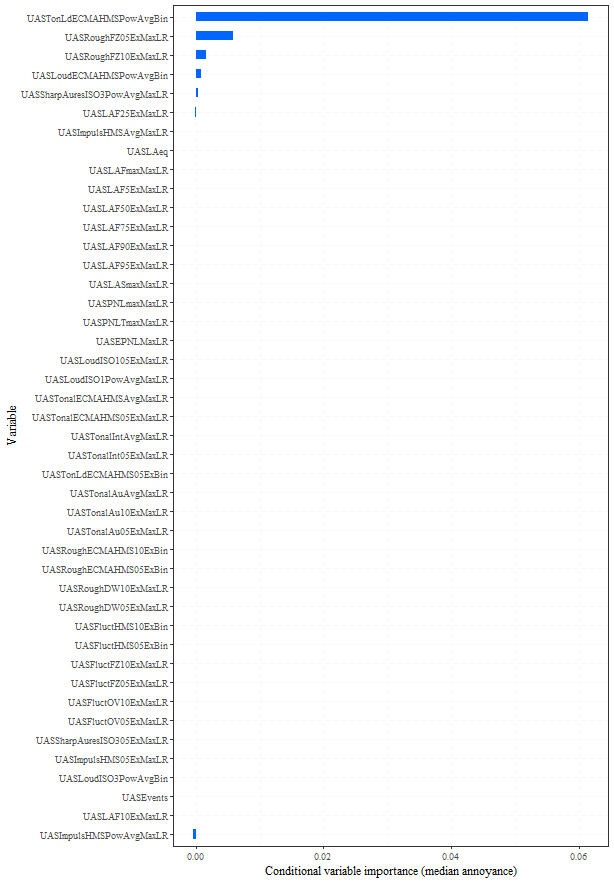

```r
par(mai=c(0,3,0,0))

# plot conditional importance
resultsOutAbsB.conimp <- data.frame('Var_imp'=rev(resultsOutAbsB$conditional_permimp))

pBar <- ggplot(resultsOutAbsB.conimp) + geom_col(aes(x=factor(rownames(resultsOutAbsB.conimp), levels=rownames(resultsOutAbsB.conimp)), y=Var_imp), fill=mycolours[1], width=0.5) + labs(x="Variable", y="Conditional variable importance (median annoyance)") + theme(text = element_text(family = "serif"), panel.grid=element_line(color = rgb(235, 235, 235, 100, maxColorValue = 255), linewidth = 0.25, linetype = 2))
pBar + coord_flip()
```

```r
if (saveplots){
  ggsave(filename="PtBAnnoyMdAbsVarsConPermimp.svg", width=8, height=11.5, path=file.path(outFigPath, "svg"))
  unlink("PtBAnnoyMdAbsVarsConPermimp.svg")

  ggsave(filename="PtBAnnoyMdAbsVarsConPermimp.pdf", width=8, height=11.5, path=file.path(outFigPath, "pdf"))
  unlink("PtBAnnoyMdAbsVarsConPermimp.pdf")
}
```

### SQM analysis

#### Replace ambient only stimuli

Here, the ‘ambient only’ stimuli are replaced, as the SQM analysis can incorporate 0 values (whereas dB metrics cannot be handled in this way).

```r
stimDataBNum <- rbind(stimDataBNum, stimDataB[stimDataB['Recording']
                                              == "B2_CALBIN_Pa.wav",
                                              colnames(stimDataBNum)])
stimDataBNum <- arrange(stimDataBNum, Recording)
```

#### Individual SQMs

Now a model is run omitting loudness and level variables, while retaining only (one of) the top importance loudness variables, and each category of SQM in turn.

```r
# Sharpness
iVars <- c("UASLoudECMAHMSPowAvgBin", "UASEvents", "UASSharpAuresISO3PowAvgMaxLR", "UASSharpAuresISO305ExMaxLR")
resultsOutSharpB <- multi_crfReg(dataIn=stimDataBNum, iVars=iVars, dVar='AnnoyMedian', seeds=c(565, 9878, 21, 4546, 64), ntree=1000, mtry=as.integer(length(iVars)/1.25), minsplit=10, minbucket=5, nperm=5)

# print model prediction results
resultsOutSharpB$OOB_RMSE
```

```
[1] 1.308074
```

```r
resultsOutSharpB$OOB_abserror
```

```
       0%       25%       50%       75%      100%
0.0000000 0.8333333 1.0000000 1.0000000 4.0000000
```

```r
resultsOutSharpB$Rsquared
```

```
[1] 0.3419694
```

```r
# store results
resAnnoyMedFitB['Abs sharp', 'RMSE'] <- resultsOutSharpB$OOB_RMSE
resAnnoyMedFitB['Abs sharp', 'Rsquared'] <- resultsOutSharpB$Rsquared
resAnnoyMedFitB['Abs sharp', which(colnames(resAnnoyMedFitB) == 'AEq0'):
                             which(colnames(resAnnoyMedFitB) == 'AEq100')] <- resultsOutSharpB$OOB_abserror
resAnnoyMedPermImpB$AbsSharp <- resultsOutSharpB$conditional_permimp
```

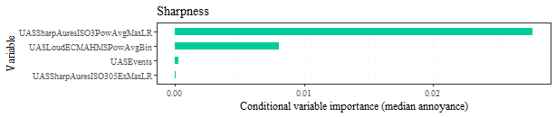

```r
par(mai=c(0,3,0,0))

# plot conditional importance
resultsOutSharpB.conimp <- data.frame('Var_imp'=rev(resultsOutSharpB$conditional_permimp))

pBar <- ggplot(resultsOutSharpB.conimp) + geom_col(aes(x=factor(rownames(resultsOutSharpB.conimp), levels=rownames(resultsOutSharpB.conimp)), y=Var_imp), fill=mycolours[2], width=0.5) + labs(x="Variable", y="Conditional variable importance (median annoyance)") + ggtitle("Sharpness") + theme(text = element_text(family = "serif"), panel.grid=element_line(color = rgb(235, 235, 235, 100, maxColorValue = 255), linewidth = 0.25, linetype = 2))
pBar + coord_flip()
```

```r
if (saveplots){
  ggsave(filename="PtBAnnoyMdSharpConPermimp.svg", width=8, height=1.7, path=file.path(outFigPath, "svg"))
  unlink("PtBAnnoyMdSharpConPermimp.svg")

  ggsave(filename="PtBAnnoyMdSharpConPermimp.pdf", width=8, height=1.7, path=file.path(outFigPath, "pdf"))
  unlink("PtBAnnoyMdSharpConPermimp.pdf")
}
```

Tonality including tonal loudness

```r
# Tonality inc tonal loudness
iVars <- c("UASLoudECMAHMSPowAvgBin", "UASEvents", "UASTonalECMAHMSAvgMaxLR", "UASTonalECMAHMS05ExMaxLR", "UASTonalIntAvgMaxLR", "UASTonalInt05ExMaxLR", "UASTonLdECMAHMSPowAvgBin", "UASTonLdECMAHMS05ExBin", "UASTonalAuAvgMaxLR", "UASTonalAu05ExMaxLR", "UASTonalAu10ExMaxLR")
resultsOutTonal1B <- multi_crfReg(dataIn=stimDataBNum, iVars=iVars, dVar='AnnoyMedian', seeds=c(5656, 118848, 5815, 4545, 12313), ntree=1000, mtry=as.integer(length(iVars)/1.25), minsplit=10, minbucket=5, nperm=5)

# print model prediction results
resultsOutTonal1B$OOB_RMSE
```

```
[1] 1.336133
```

```r
resultsOutTonal1B$OOB_abserror
```

```
  0%  25%  50%  75% 100%
 0.0  0.5  1.0  1.0  4.0
```

```r
resultsOutTonal1B$Rsquared
```

```
[1] 0.2441575
```

```r
# store results
resAnnoyMedFitB['Abs inc tonal loud', 'RMSE'] <- resultsOutTonal1B$OOB_RMSE
resAnnoyMedFitB['Abs inc tonal loud', 'Rsquared'] <- resultsOutTonal1B$Rsquared
resAnnoyMedFitB['Abs inc tonal loud', which(colnames(resAnnoyMedFitB) == 'AEq0'):
                                      which(colnames(resAnnoyMedFitB) == 'AEq100')] <- resultsOutTonal1B$OOB_abserror
resAnnoyMedPermImpB$AbsTonal1 <- resultsOutTonal1B$conditional_permimp
```

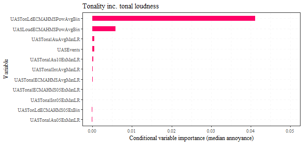

```r
par(mai=c(0,3,0,0))

# plot conditional importance
resultsOutTonal1B.conimp <- data.frame('Var_imp'=rev(resultsOutTonal1B$conditional_permimp))

pBar <- ggplot(resultsOutTonal1B.conimp) + geom_col(aes(x=factor(rownames(resultsOutTonal1B.conimp), levels=rownames(resultsOutTonal1B.conimp)), y=Var_imp), fill=mycolours[3], width=0.5) + labs(x="Variable", y="Conditional variable importance (median annoyance)") + ggtitle("Tonality inc. tonal loudness") + theme(text = element_text(family = "serif"), panel.grid=element_line(color = rgb(235, 235, 235, 100, maxColorValue = 255), linewidth = 0.25, linetype = 2))
pBar + coord_flip(ylim=c(0, 0.05))
```

```r
if (saveplots){
  ggsave(filename="PtBAnnoyMdTonalLdConPermimp.svg", width=8, height=3.8, path=file.path(outFigPath, "svg"))
  unlink("PtBAnnoyMdTonalLdConPermimp.svg")

  ggsave(filename="PtBAnnoyMdTonalLdConPermimp.pdf", width=8, height=3.8, path=file.path(outFigPath, "pdf"))
  unlink("PtBAnnoyMdTonalLdConPermimp.pdf")
}
```

Re-run tonality evaluation omitting tonal loudness

```r
# Tonality
iVars <- c("UASLoudECMAHMSPowAvgBin", "UASEvents", "UASTonalECMAHMSAvgMaxLR", "UASTonalECMAHMS05ExMaxLR", "UASTonalIntAvgMaxLR", "UASTonalInt05ExMaxLR", "UASTonalAuAvgMaxLR", "UASTonalAu05ExMaxLR", "UASTonalAu10ExMaxLR")
resultsOutTonal2B <- multi_crfReg(dataIn=stimDataBNum, iVars=iVars, dVar='AnnoyMedian', seeds=c(5656, 118848, 5815, 4545, 12313), ntree=1000, mtry=as.integer(length(iVars)/1.25), minsplit=10, minbucket=5, nperm=5)

# print model prediction results
resultsOutTonal2B$OOB_RMSE
```

```
[1] 1.461516
```

```r
resultsOutTonal2B$OOB_abserror
```

```
       0%       25%       50%       75%      100%
0.0000000 0.5666667 1.0000000 1.2666667 4.0000000
```

```r
resultsOutTonal2B$Rsquared
```

```
[1] 0.1994334
```

```r
# store results
resAnnoyMedFitB['Abs no tonal loud', 'RMSE'] <- resultsOutTonal2B$OOB_RMSE
resAnnoyMedFitB['Abs no tonal loud', 'Rsquared'] <- resultsOutTonal2B$Rsquared
resAnnoyMedFitB['Abs no tonal loud', which(colnames(resAnnoyMedFitB) == 'AEq0'):
                                     which(colnames(resAnnoyMedFitB) == 'AEq100')] <- resultsOutTonal2B$OOB_abserror
resAnnoyMedPermImpB$AbsTonal2 <- resultsOutTonal2B$conditional_permimp
```

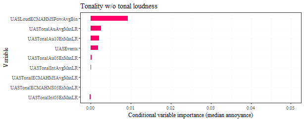

```r
par(mai=c(0,3,0,0))

# plot conditional importance
resultsOutTonal2B.conimp <- data.frame('Var_imp'=rev(resultsOutTonal2B$conditional_permimp))

pBar <- ggplot(resultsOutTonal2B.conimp) + geom_col(aes(x=factor(rownames(resultsOutTonal2B.conimp), levels=rownames(resultsOutTonal2B.conimp)), y=Var_imp), fill=mycolours[3], width=0.5) + labs(x="Variable", y="Conditional variable importance (median annoyance)") + ggtitle("Tonality w/o tonal loudness") + theme(text = element_text(family = "serif"), panel.grid=element_line(color = rgb(235, 235, 235, 100, maxColorValue = 255), linewidth = 0.25, linetype = 2))
pBar + coord_flip(ylim=c(0, 0.05))
```

```r
if (saveplots){
  ggsave(filename="PtBAnnoyMdTonalNoLdConPermimp.svg", width=8, height=3.2, path=file.path(outFigPath, "svg"))
  unlink("PtBAnnoyMdTonalNoLdConPermimp.svg")

  ggsave(filename="PtBAnnoyMdTonalNoLdConPermimp.pdf", width=8, height=3.2, path=file.path(outFigPath, "pdf"))
  unlink("PtBAnnoyMdTonalNoLdConPermimp.pdf")
}
```

```r
# Fluctuation strength
iVars <- c("UASLoudECMAHMSPowAvgBin", "UASEvents", "UASFluctHMS10ExBin", "UASFluctHMS05ExBin", "UASFluctFZ10ExMaxLR", "UASFluctFZ05ExMaxLR", "UASFluctOV10ExMaxLR", "UASFluctOV05ExMaxLR")
resultsOutFluctB <- multi_crfReg(dataIn=stimDataBNum, iVars=iVars, dVar='AnnoyMedian', seeds=c(46446, 121, 54548, 3, 787), ntree=1000, mtry=as.integer(length(iVars)/1.25), minsplit=10, minbucket=5, nperm=5)

# print model prediction results
resultsOutFluctB$OOB_RMSE
```

```
[1] 1.582425
```

```r
resultsOutFluctB$OOB_abserror
```

```
       0%       25%       50%       75%      100%
0.0000000 0.7666667 1.0000000 1.3333333 4.6000000
```

```r
resultsOutFluctB$Rsquared
```

```
[1] 0.0623813
```

```r
# store results
resAnnoyMedFitB['Abs fluct', 'RMSE'] <- resultsOutFluctB$OOB_RMSE
resAnnoyMedFitB['Abs fluct', 'Rsquared'] <- resultsOutFluctB$Rsquared
resAnnoyMedFitB['Abs fluct', which(colnames(resAnnoyMedFitB) == 'AEq0'):
                             which(colnames(resAnnoyMedFitB) == 'AEq100')] <- resultsOutFluctB$OOB_abserror
resAnnoyMedPermImpB$AbsFluct <- resultsOutFluctB$conditional_permimp
```

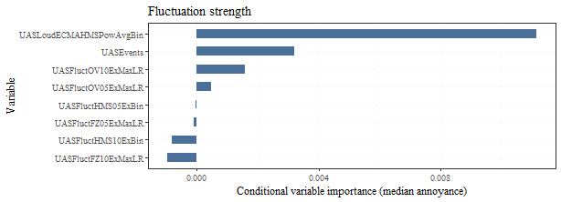

```r
par(mai=c(0,3,0,0))

# plot conditional importance
resultsOutFluctB.conimp <- data.frame('Var_imp'=rev(resultsOutFluctB$conditional_permimp))

pBar <- ggplot(resultsOutFluctB.conimp) + geom_col(aes(x=factor(rownames(resultsOutFluctB.conimp), levels=rownames(resultsOutFluctB.conimp)), y=Var_imp), fill=mycolours[4], width=0.5) + labs(x="Variable", y="Conditional variable importance (median annoyance)") + ggtitle("Fluctuation strength") + theme(text = element_text(family = "serif"), panel.grid=element_line(color = rgb(235, 235, 235, 100, maxColorValue = 255), linewidth = 0.25, linetype = 2))
pBar + coord_flip()
```

```r
if (saveplots){
  ggsave(filename="PtBAnnoyMdFluctConPermimp.svg", width=8, height=2.9, path=file.path(outFigPath, "svg"))
  unlink("PtBAnnoyMdFluctConPermimp.svg")

  ggsave(filename="PtBAnnoyMdFluctConPermimp.pdf", width=8, height=2.9, path=file.path(outFigPath, "pdf"))
  unlink("PtBAnnoyMdFluctConPermimp.pdf")
}
```

```r
# Roughness
iVars <- c("UASLoudECMAHMSPowAvgBin", "UASEvents", "UASRoughECMAHMS10ExBin", "UASRoughECMAHMS05ExBin", "UASRoughFZ10ExMaxLR", "UASRoughFZ05ExMaxLR", "UASRoughDW10ExMaxLR", "UASRoughDW05ExMaxLR")
resultsOutRoughB <- multi_crfReg(dataIn=stimDataBNum, iVars=iVars, dVar='AnnoyMedian', seeds=c(66, 78716, 8797, 87, 9421), ntree=1000, mtry=as.integer(length(iVars)/1.25), minsplit=10, minbucket=5, nperm=5)

# print model prediction results
resultsOutRoughB$OOB_RMSE
```

```
[1] 1.262448
```

```r
resultsOutRoughB$OOB_abserror
```

```
       0%       25%       50%       75%      100%
0.0000000 0.4666667 1.0000000 1.0000000 4.0000000
```

```r
resultsOutRoughB$Rsquared
```

```
[1] 0.3233692
```

```r
# store results
resAnnoyMedFitB['Abs rough', 'RMSE'] <- resultsOutRoughB$OOB_RMSE
resAnnoyMedFitB['Abs rough', 'Rsquared'] <- resultsOutRoughB$Rsquared
resAnnoyMedFitB['Abs rough', which(colnames(resAnnoyMedFitB) == 'AEq0'):
                             which(colnames(resAnnoyMedFitB) == 'AEq100')] <- resultsOutRoughB$OOB_abserror
resAnnoyMedPermImpB$AbsRough <- resultsOutRoughB$conditional_permimp
```

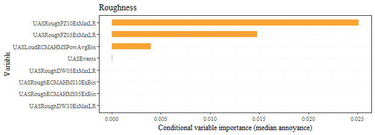

```r
par(mai=c(0,3,0,0))

# plot conditional importance
resultsOutRoughB.conimp <- data.frame('Var_imp'=rev(resultsOutRoughB$conditional_permimp))

pBar <- ggplot(resultsOutRoughB.conimp) + geom_col(aes(x=factor(rownames(resultsOutRoughB.conimp), levels=rownames(resultsOutRoughB.conimp)), y=Var_imp), fill=mycolours[5], width=0.5) + labs(x="Variable", y="Conditional variable importance (median annoyance)") + ggtitle("Roughness") + theme(text = element_text(family = "serif"), panel.grid=element_line(color = rgb(235, 235, 235, 100, maxColorValue = 255), linewidth = 0.25, linetype = 2))
pBar + coord_flip()
```

```r
if (saveplots){
  ggsave(filename="PtBAnnoyMdRoughConPermimp.svg", width=8, height=2.9, path=file.path(outFigPath, "svg"))
  unlink("PtBAnnoyMdRoughConPermimp.svg")

  ggsave(filename="PtBAnnoyMdRoughConPermimp.pdf", width=8, height=2.9, path=file.path(outFigPath, "pdf"))
  unlink("PtBAnnoyMdRoughConPermimp.pdf")
}
```

```r
# Impulsiveness
iVars <- c("UASLoudECMAHMSPowAvgBin", "UASEvents", "UASImpulsHMSAvgMaxLR", "UASImpulsHMS05ExMaxLR", "UASImpulsHMSPowAvgMaxLR")
resultsOutImpulsB <- multi_crfReg(dataIn=stimDataBNum, iVars=iVars, dVar='AnnoyMedian', seeds=c(31, 45448, 8441, 546, 6451), ntree=1000, mtry=as.integer(length(iVars)/1.25), minsplit=10, minbucket=5, nperm=5)

# print model prediction results
resultsOutImpulsB$OOB_RMSE
```

```
[1] 1.389782
```

```r
resultsOutImpulsB$OOB_abserror
```

```
      0%      25%      50%      75%     100%
0.000000 0.500000 1.000000 1.133333 4.000000
```

```r
resultsOutImpulsB$Rsquared
```

```
[1] 0.2527795
```

```r
# store results
resAnnoyMedFitB['Abs impuls', 'RMSE'] <- resultsOutImpulsB$OOB_RMSE
resAnnoyMedFitB['Abs impuls', 'Rsquared'] <- resultsOutImpulsB$Rsquared
resAnnoyMedFitB['Abs impuls', which(colnames(resAnnoyMedFitB) == 'AEq0'):
                             which(colnames(resAnnoyMedFitB) == 'AEq100')] <- resultsOutImpulsB$OOB_abserror
resAnnoyMedPermImpB$AbsImpuls <- resultsOutImpulsB$conditional_permimp
```

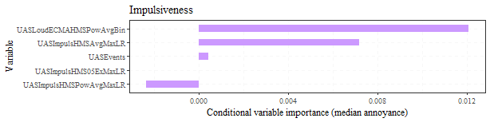

```r
par(mai=c(0,3,0,0))

# plot conditional importance
resultsOutImpulsB.conimp <- data.frame('Var_imp'=rev(resultsOutImpulsB$conditional_permimp))

pBar <- ggplot(resultsOutImpulsB.conimp) + geom_col(aes(x=factor(rownames(resultsOutImpulsB.conimp), levels=rownames(resultsOutImpulsB.conimp)), y=Var_imp), fill=mycolours[6], width=0.5) + labs(x="Variable", y="Conditional variable importance (median annoyance)") + ggtitle("Impulsiveness") + theme(text = element_text(family = "serif"), panel.grid=element_line(color = rgb(235, 235, 235, 100, maxColorValue = 255), linewidth = 0.25, linetype = 2))
pBar + coord_flip()
```

```r
if (saveplots){
  ggsave(filename="PtBAnnoyMdImpulsConPermimp.svg", width=8, height=2, path=file.path(outFigPath, "svg"))
  unlink("PtBAnnoyMdImpulsConPermimp.svg")

  ggsave(filename="PtBAnnoyMdImpulsConPermimp.pdf", width=8, height=2, path=file.path(outFigPath, "pdf"))
  unlink("PtBAnnoyMdImpulsConPermimp.pdf")
}
```

#### SQM and loudness comparison

```r
iVars <- c("UASLoudECMAHMSPowAvgBin", "UASEvents", "UASSharpAuresISO3PowAvgMaxLR", "UASTonLdECMAHMSPowAvgBin", "UASFluctOV10ExMaxLR", "UASRoughFZ10ExMaxLR", "UASImpulsHMSAvgMaxLR")
resultsOutSQMs1B <- multi_crfReg(dataIn=stimDataBNum, iVars=iVars, dVar='AnnoyMedian', seeds=c(456, 41546, 7872, 5780, 45640), ntree=1000, mtry=as.integer(length(iVars)/1.25), minsplit=10, minbucket=5, nperm=5)

# print model prediction results
resultsOutSQMs1B$OOB_RMSE
```

```
[1] 1.276367
```

```r
resultsOutSQMs1B$OOB_abserror
```

```
  0%  25%  50%  75% 100%
 0.0  0.6  1.0  1.0  4.0
```

```r
resultsOutSQMs1B$Rsquared
```

```
[1] 0.2897978
```

```r
# store results
resAnnoyMedFitB['Abs SQMs inc tonal loud', 'RMSE'] <- resultsOutSQMs1B$OOB_RMSE
resAnnoyMedFitB['Abs SQMs inc tonal loud', 'Rsquared'] <- resultsOutSQMs1B$Rsquared
resAnnoyMedFitB['Abs SQMs inc tonal loud', which(colnames(resAnnoyMedFitB) == 'AEq0'):
                                          which(colnames(resAnnoyMedFitB) == 'AEq100')] <- resultsOutSQMs1B$OOB_abserror
resAnnoyMedPermImpB$AbsSQMs1 <- resultsOutSQMs1B$conditional_permimp
```

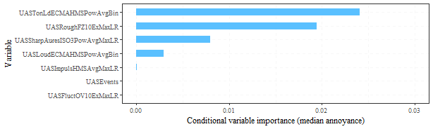

```r
par(mai=c(0,3,0,0))

# plot conditional importance
resultsOutSQMs1B.conimp <- data.frame('Var_imp'=rev(resultsOutSQMs1B$conditional_permimp))

pBar <- ggplot(resultsOutSQMs1B.conimp) + geom_col(aes(x=factor(rownames(resultsOutSQMs1B.conimp), levels=rownames(resultsOutSQMs1B.conimp)), y=Var_imp), fill=mycolours[7], width=0.5) + labs(x="Variable", y="Conditional variable importance (median annoyance)") + theme(text = element_text(family = "serif"), panel.grid=element_line(color = rgb(235, 235, 235, 100, maxColorValue = 255), linewidth = 0.25, linetype = 2))
pBar + coord_flip(ylim=c(0, 0.03))
```

```r
if (saveplots){
  ggsave(filename="PtBAnnoyMdAbsSQMsTonLdConPermimp.svg", width=8, height=2.4, path=file.path(outFigPath, "svg"))
  unlink("PtBAnnoyMdAbsSQMsTonLdConPermimp.svg")

  ggsave(filename="PtBAnnoyMdAbsSQMsTonLdConPermimp.pdf", width=8, height=2.4, path=file.path(outFigPath, "pdf"))
  unlink("PtBAnnoyMdAbsSQMsTonLdConPermimp.pdf")
}
```

Repeated without tonal loudness

```r
iVars <- c("UASLoudECMAHMSPowAvgBin", "UASEvents", "UASSharpAuresISO3PowAvgMaxLR", "UASTonalAuAvgMaxLR", "UASFluctOV10ExMaxLR", "UASRoughFZ10ExMaxLR", "UASImpulsHMSAvgMaxLR")
resultsOutSQMs2B <- multi_crfReg(dataIn=stimDataBNum, iVars=iVars, dVar='AnnoyMedian', seeds=c(456, 41546, 7872, 5780, 45640), ntree=1000, mtry=as.integer(length(iVars)/1.25), minsplit=10, minbucket=5, nperm=5)

# print model prediction results
resultsOutSQMs2B$OOB_RMSE
```

```
[1] 1.285619
```

```r
resultsOutSQMs2B$OOB_abserror
```

```
  0%  25%  50%  75% 100%
 0.0  0.7  1.0  1.0  4.0
```

```r
resultsOutSQMs2B$Rsquared
```

```
[1] 0.3094919
```

```r
# store results
resAnnoyMedFitB['Abs SQMs no tonal loud', 'RMSE'] <- resultsOutSQMs2B$OOB_RMSE
resAnnoyMedFitB['Abs SQMs no tonal loud', 'Rsquared'] <- resultsOutSQMs2B$Rsquared
resAnnoyMedFitB['Abs SQMs no tonal loud', which(colnames(resAnnoyMedFitB) == 'AEq0'):
                                          which(colnames(resAnnoyMedFitB) == 'AEq100')] <- resultsOutSQMs2B$OOB_abserror
resAnnoyMedPermImpB$AbsSQMs2 <- resultsOutSQMs2B$conditional_permimp
```

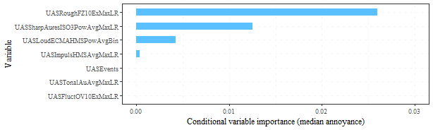

```r
par(mai=c(0,3,0,0))

# plot conditional importance
resultsOutSQMs2B.conimp <- data.frame('Var_imp'=rev(resultsOutSQMs2B$conditional_permimp))

pBar <- ggplot(resultsOutSQMs2B.conimp) + geom_col(aes(x=factor(rownames(resultsOutSQMs2B.conimp), levels=rownames(resultsOutSQMs2B.conimp)), y=Var_imp), fill=mycolours[7], width=0.5) + labs(x="Variable", y="Conditional variable importance (median annoyance)") + theme(text = element_text(family = "serif"), panel.grid=element_line(color = rgb(235, 235, 235, 100, maxColorValue = 255), linewidth = 0.25, linetype = 2))
pBar + coord_flip(ylim=c(0, 0.03))
```

```r
if (saveplots){
  ggsave(filename="PtBAnnoyMdAbsSQMsNoTonLdConPermimp.svg", width=8, height=2.4, path=file.path(outFigPath, "svg"))
  unlink("PtBAnnoyMdAbsSQMsNoTonLdConPermimp.svg")

  ggsave(filename="PtBAnnoyMdAbsSQMsNoTonLdConPermimp.pdf", width=8, height=2.4, path=file.path(outFigPath, "pdf"))
  unlink("PtBAnnoyMdAbsSQMsNoTonLdConPermimp.pdf")

}
```

### Difference variables

Next, the difference metrics are analysed,

#### Remove ambient only stimuli

Here, the ‘ambient only’ stimuli are removed, as the analysis cannot handle missing values for dB metrics.

```r
stimDataBNum <- stimDataBNum[complete.cases(stimDataBNum),]
stimDataBNum$UASLAeq <- as.numeric(stimDataBNum$UASLAeq)
stimDataBNum$SNRlevel <- as.numeric(stimDataBNum$SNRlevel)
```

```r
iVars <- c(names(stimDataBNum)[which(colnames(stimDataBNum)=="LAeqdiffLAF90"):
                               which(colnames(stimDataBNum)=="dImpulsHMS05ExMaxLR")], "SNRlevel", "UASEvents")
resultsOutDiffsB <- multi_crfReg(dataIn=stimDataBNum, iVars=iVars, dVar='AnnoyMedian', seeds=c(7005, 126, 4540, 5465, 840), ntree=1000, mtry=as.integer(length(iVars)/1.25), minsplit=10, minbucket=5, nperm=5)

# print model prediction results
resultsOutDiffsB$OOB_RMSE
```

```
[1] 0.945289
```

```r
resultsOutDiffsB$OOB_abserror
```

```
  0%  25%  50%  75% 100%
 0.4  1.0  1.0  1.0  1.0
```

```r
resultsOutDiffsB$Rsquared
```

```
[1] 0.2115757
```

```r
# store results
resAnnoyMedFitB['Diff vars', 'RMSE'] <- resultsOutDiffsB$OOB_RMSE
resAnnoyMedFitB['Diff vars', 'Rsquared'] <- resultsOutDiffsB$Rsquared
resAnnoyMedFitB['Diff vars', which(colnames(resAnnoyMedFitB) == 'AEq0'):
                            which(colnames(resAnnoyMedFitB) == 'AEq100')] <- resultsOutDiffsB$OOB_abserror
resAnnoyMedPermImpB$DiffVars <- resultsOutDiffsB$conditional_permimp
```

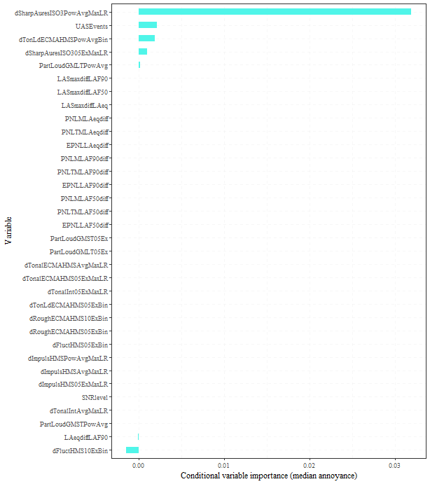

```r
par(mai=c(0,3,0,0))

# plot conditional importance
resultsOutDiffsB.conimp <- data.frame('Var_imp'=rev(resultsOutDiffsB$conditional_permimp))

pBar <- ggplot(resultsOutDiffsB.conimp) + geom_col(aes(x=factor(rownames(resultsOutDiffsB.conimp), levels=rownames(resultsOutDiffsB.conimp)), y=Var_imp), fill=mycolours[8], width=0.5) + labs(x="Variable", y="Conditional variable importance (median annoyance)") + theme(text = element_text(family = "serif"), panel.grid=element_line(color = rgb(235, 235, 235, 100, maxColorValue = 255), linewidth = 0.25, linetype = 2))
pBar + coord_flip()
```

```r
if (saveplots){
  ggsave(filename="PtBAnnoyMdDiffVarsConPermimp.svg", width=8, height=9, path=file.path(outFigPath, "svg"))
  unlink("PtBAnnoyMdDiffVarsConPermimp.svg")

  ggsave(filename="PtBAnnoyMdDiffVarsConPermimp.pdf", width=8, height=9, path=file.path(outFigPath, "pdf"))
  unlink("PtBAnnoyMdDiffVarsConPermimp.pdf")
}
```

Save the results outputs to file

```r
if (savedata){
  utils::write.csv(resAnnoyMedFitB, paste(outDataPath, "\\ptBCRFAnnoyMdOOBFit.csv", sep=""))
  ii <- 0
  temp = list()
  for (res in resAnnoyMedPermImpB){
    ii <- ii + 1
    temp[[ii]] <- as.data.frame(resAnnoyMedPermImpB[ii])
    names(temp[[ii]]) <- names(resAnnoyMedPermImpB[ii])
  }
  openxlsx::write.xlsx(temp, paste(outDataPath, "\\ptBCRFAnnoyMdConPermimp.xlsx",
                                   sep=""),
                       rowNames=TRUE)
}
```

## Annoyance (mean)

### Absolute variables

The random forest modelling is run on the aggregated data, including all the variables.

#### Remove ambient only stimuli

Here, the ‘ambient only’ stimuli are removed, as the analysis cannot handle missing values for dB metrics.

```r
stimDataBNum <- stimDataBNum[complete.cases(stimDataBNum),]
stimDataBNum$UASLAeq <- as.numeric(stimDataBNum$UASLAeq)
stimDataBNum$SNRlevel <- as.numeric(stimDataBNum$SNRlevel)
```

```r
resAnnoyMnFitB <- data.frame(RMSE = numeric(),
                               Rsquared = numeric(),
                               AEq0 = numeric(),
                               AEq25 = numeric(),
                               AEq50 = numeric(),
                               AEq75 = numeric(),
                               AEq100 = numeric())
resAnnoyMnPermImpB <- list()
```

```r
iVars <- names(stimDataBNum)[which(names(stimDataBNum) == 'UASEvents'):which(names(stimDataBNum) == 'UASImpulsHMS05ExMaxLR')]
iVars <- iVars[! iVars %in% 'SNRlevel']
resultsOutAbsB <- multi_crfReg(dataIn=stimDataBNum, iVars=iVars, dVar='AnnoyMean', seeds=c(104569, 6978, 551264, 563, 8), ntree=1000, mtry=as.integer(length(iVars)/1.25), minsplit=10, minbucket=5, nperm=5)

# print model prediction results
resultsOutAbsB$OOB_RMSE
```

```
[1] 0.5373303
```

```r
resultsOutAbsB$OOB_abserror
```

```
         0%         25%         50%         75%        100%
0.006916994 0.103180488 0.294019814 0.635372090 1.078883363
```

```r
resultsOutAbsB$Rsquared
```

```
[1] 0.616182
```

```r
# store results
resAnnoyMnFitB['Abs vars', 'RMSE'] <- resultsOutAbsB$OOB_RMSE
resAnnoyMnFitB['Abs vars', 'Rsquared'] <- resultsOutAbsB$Rsquared
resAnnoyMnFitB['Abs vars', which(colnames(resAnnoyMnFitB) == 'AEq0'):
                                       which(colnames(resAnnoyMnFitB) == 'AEq100')] <- resultsOutAbsB$OOB_abserror
resAnnoyMnPermImpB$AbsVars <- resultsOutAbsB$conditional_permimp
```

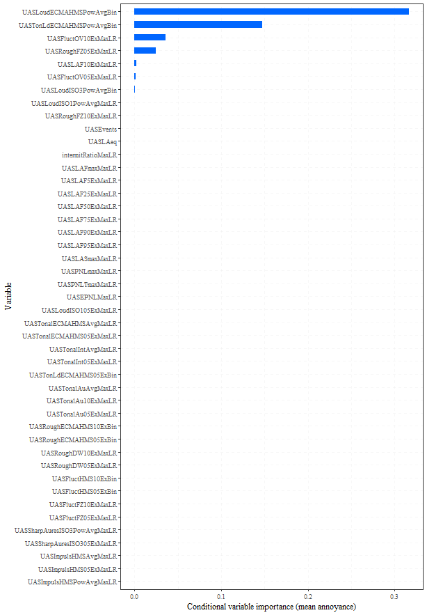

```r
par(mai=c(0,3,0,0))

# plot conditional importance
resultsOutAbsB.conimp <- data.frame('Var_imp'=rev(resultsOutAbsB$conditional_permimp))

pBar <- ggplot(resultsOutAbsB.conimp) + geom_col(aes(x=factor(rownames(resultsOutAbsB.conimp), levels=rownames(resultsOutAbsB.conimp)), y=Var_imp), fill=mycolours[1], width=0.5) + labs(x="Variable", y="Conditional variable importance (mean annoyance)") + theme(text = element_text(family = "serif"), panel.grid=element_line(color = rgb(235, 235, 235, 100, maxColorValue = 255), linewidth = 0.25, linetype = 2))
pBar + coord_flip()
```

```r
if (saveplots){
  ggsave(filename="PtBAnnoyMnAbsVarsConPermimp.svg", width=8, height=11.5, path=file.path(outFigPath, "svg"))
  unlink("PtBAnnoyMnAbsVarsConPermimp.svg")

  ggsave(filename="PtBAnnoyMnAbsVarsConPermimp.pdf", width=8, height=11.5, path=file.path(outFigPath, "pdf"))
  unlink("PtBAnnoyMnAbsVarsConPermimp.pdf")
}
```

### SQM analysis

#### Replace ambient only stimuli

Here, the ‘ambient only’ stimuli are replaced, as the SQM analysis can incorporate 0 values (whereas dB metrics cannot be handled in this way).

```r
stimDataBNum <- rbind(stimDataBNum, stimDataB[stimDataB['Recording']
                                              == "B2_CALBIN_Pa.wav",
                                              colnames(stimDataBNum)])
stimDataBNum <- arrange(stimDataBNum, Recording)
```

#### Individual SQMs

Now a model is run omitting loudness and level variables, while retaining only (one of) the top importance loudness variables, and each category of SQM in turn.

```r
# Sharpness
iVars <- c("UASLoudECMAHMSPowAvgBin", "UASEvents", "UASSharpAuresISO3PowAvgMaxLR", "UASSharpAuresISO305ExMaxLR")
resultsOutSharpB <- multi_crfReg(dataIn=stimDataBNum, iVars=iVars, dVar='AnnoyMean', seeds=c(635604, 263156, 372048, 486951, 521234), ntree=1000, mtry=as.integer(length(iVars)/1.25), minsplit=10, minbucket=5, nperm=5)

# print model prediction results
resultsOutSharpB$OOB_RMSE
```

```
[1] 1.081104
```

```r
resultsOutSharpB$OOB_abserror
```

```
        0%        25%        50%        75%       100%
0.03875309 0.34742968 0.47063654 0.61822206 3.90085314
```

```r
resultsOutSharpB$Rsquared
```

```
[1] 0.3565169
```

```r
# store results
resAnnoyMnFitB['Abs sharp', 'RMSE'] <- resultsOutSharpB$OOB_RMSE
resAnnoyMnFitB['Abs sharp', 'Rsquared'] <- resultsOutSharpB$Rsquared
resAnnoyMnFitB['Abs sharp', which(colnames(resAnnoyMnFitB) == 'AEq0'):
                             which(colnames(resAnnoyMnFitB) == 'AEq100')] <- resultsOutSharpB$OOB_abserror
resAnnoyMnPermImpB$AbsSharp <- resultsOutSharpB$conditional_permimp
```

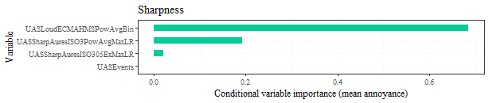

```r
par(mai=c(0,3,0,0))

# plot conditional importance
resultsOutSharpB.conimp <- data.frame('Var_imp'=rev(resultsOutSharpB$conditional_permimp))

pBar <- ggplot(resultsOutSharpB.conimp) + geom_col(aes(x=factor(rownames(resultsOutSharpB.conimp), levels=rownames(resultsOutSharpB.conimp)), y=Var_imp), fill=mycolours[2], width=0.5) + labs(x="Variable", y="Conditional variable importance (mean annoyance)") + ggtitle("Sharpness") + theme(text = element_text(family = "serif"), panel.grid=element_line(color = rgb(235, 235, 235, 100, maxColorValue = 255), linewidth = 0.25, linetype = 2))
pBar + coord_flip()
```

```r
if (saveplots){
  ggsave(filename="PtBAnnoyMnSharpConPermimp.svg", width=8, height=1.7, path=file.path(outFigPath, "svg"))
  unlink("PtBAnnoyMnSharpConPermimp.svg")

  ggsave(filename="PtBAnnoyMnSharpConPermimp.pdf", width=8, height=1.7, path=file.path(outFigPath, "pdf"))
  unlink("PtBAnnoyMnSharpConPermimp.pdf")
}
```

Tonality including tonal loudness

```r
# Tonality inc tonal loudness
iVars <- c("UASLoudECMAHMSPowAvgBin", "UASEvents", "UASTonalECMAHMSAvgMaxLR", "UASTonalECMAHMS05ExMaxLR", "UASTonalIntAvgMaxLR", "UASTonalInt05ExMaxLR", "UASTonLdECMAHMSPowAvgBin", "UASTonLdECMAHMS05ExBin", "UASTonalAuAvgMaxLR", "UASTonalAu05ExMaxLR", "UASTonalAu10ExMaxLR")
resultsOutTonal1B <- multi_crfReg(dataIn=stimDataBNum, iVars=iVars, dVar='AnnoyMean', seeds=c(25698, 5827, 79, 742508, 1053784), ntree=1000, mtry=as.integer(length(iVars)/1.25), minsplit=10, minbucket=5, nperm=5)

# print model prediction results
resultsOutTonal1B$OOB_RMSE
```

```
[1] 1.052169
```

```r
resultsOutTonal1B$OOB_abserror
```

```
       0%       25%       50%       75%      100%
0.0948625 0.1988044 0.3508100 0.6314034 3.8814119
```

```r
resultsOutTonal1B$Rsquared
```

```
[1] 0.4073823
```

```r
# store results
resAnnoyMnFitB['Abs inc tonal loud', 'RMSE'] <- resultsOutTonal1B$OOB_RMSE
resAnnoyMnFitB['Abs inc tonal loud', 'Rsquared'] <- resultsOutTonal1B$Rsquared
resAnnoyMnFitB['Abs inc tonal loud', which(colnames(resAnnoyMnFitB) == 'AEq0'):
                                      which(colnames(resAnnoyMnFitB) == 'AEq100')] <- resultsOutTonal1B$OOB_abserror
resAnnoyMnPermImpB$AbsTonal1 <- resultsOutTonal1B$conditional_permimp
```

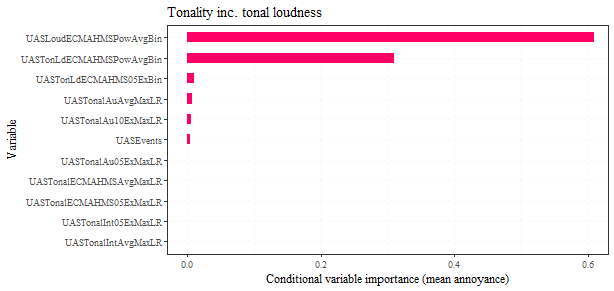

```r
par(mai=c(0,3,0,0))

# plot conditional importance
resultsOutTonal1B.conimp <- data.frame('Var_imp'=rev(resultsOutTonal1B$conditional_permimp))

pBar <- ggplot(resultsOutTonal1B.conimp) + geom_col(aes(x=factor(rownames(resultsOutTonal1B.conimp), levels=rownames(resultsOutTonal1B.conimp)), y=Var_imp), fill=mycolours[3], width=0.5) + labs(x="Variable", y="Conditional variable importance (mean annoyance)") + ggtitle("Tonality inc. tonal loudness") + theme(text = element_text(family = "serif"), panel.grid=element_line(color = rgb(235, 235, 235, 100, maxColorValue = 255), linewidth = 0.25, linetype = 2))
pBar + coord_flip(ylim=c(0, 0.6))
```

```r
if (saveplots){
  ggsave(filename="PtBAnnoyMnTonalLdConPermimp.svg", width=8, height=3.8, path=file.path(outFigPath, "svg"))
  unlink("PtBAnnoyMnTonalLdConPermimp.svg")

  ggsave(filename="PtBAnnoyMnTonalLdConPermimp.pdf", width=8, height=3.8, path=file.path(outFigPath, "pdf"))
  unlink("PtBAnnoyMnTonalLdConPermimp.pdf")
}
```

Re-run tonality evaluation omitting tonal loudness

```r
# Tonality
iVars <- c("UASLoudECMAHMSPowAvgBin", "UASEvents", "UASTonalECMAHMSAvgMaxLR", "UASTonalECMAHMS05ExMaxLR", "UASTonalIntAvgMaxLR", "UASTonalInt05ExMaxLR", "UASTonalAuAvgMaxLR", "UASTonalAu05ExMaxLR", "UASTonalAu10ExMaxLR")
resultsOutTonal2B <- multi_crfReg(dataIn=stimDataBNum, iVars=iVars, dVar='AnnoyMean', seeds=c(849651, 7150, 56, 5792, 208645), ntree=1000, mtry=as.integer(length(iVars)/1.25), minsplit=10, minbucket=5, nperm=5)

# print model prediction results
resultsOutTonal2B$OOB_RMSE
```

```
[1] 1.104817
```

```r
resultsOutTonal2B$OOB_abserror
```

```
        0%        25%        50%        75%       100%
0.06298198 0.30884193 0.50687625 0.65550038 3.93739592
```

```r
resultsOutTonal2B$Rsquared
```

```
[1] 0.3348933
```

```r
# store results
resAnnoyMnFitB['Abs no tonal loud', 'RMSE'] <- resultsOutTonal2B$OOB_RMSE
resAnnoyMnFitB['Abs no tonal loud', 'Rsquared'] <- resultsOutTonal2B$Rsquared
resAnnoyMnFitB['Abs no tonal loud', which(colnames(resAnnoyMnFitB) == 'AEq0'):
                                     which(colnames(resAnnoyMnFitB) == 'AEq100')] <- resultsOutTonal2B$OOB_abserror
resAnnoyMnPermImpB$AbsTonal2 <- resultsOutTonal2B$conditional_permimp
```

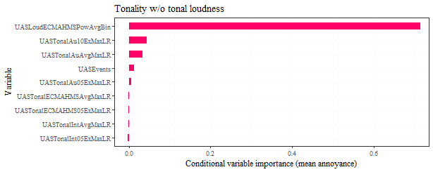

```r
par(mai=c(0,3,0,0))

# plot conditional importance
resultsOutTonal2B.conimp <- data.frame('Var_imp'=rev(resultsOutTonal2B$conditional_permimp))

pBar <- ggplot(resultsOutTonal2B.conimp) + geom_col(aes(x=factor(rownames(resultsOutTonal2B.conimp), levels=rownames(resultsOutTonal2B.conimp)), y=Var_imp), fill=mycolours[3], width=0.5) + labs(x="Variable", y="Conditional variable importance (mean annoyance)") + ggtitle("Tonality w/o tonal loudness") + theme(text = element_text(family = "serif"), panel.grid=element_line(color = rgb(235, 235, 235, 100, maxColorValue = 255), linewidth = 0.25, linetype = 2))
pBar + coord_flip(ylim=c(0, 0.7))
```

```r
if (saveplots){
  ggsave(filename="PtBAnnoyMnTonalNoLdConPermimp.svg", width=8, height=3.2, path=file.path(outFigPath, "svg"))
  unlink("PtBAnnoyMnTonalNoLdConPermimp.svg")

  ggsave(filename="PtBAnnoyMnTonalNoLdConPermimp.pdf", width=8, height=3.2, path=file.path(outFigPath, "pdf"))
  unlink("PtBAnnoyMnTonalNoLdConPermimp.pdf")
}
```

```r
# Fluctuation strength
iVars <- c("UASLoudECMAHMSPowAvgBin", "UASEvents", "UASFluctHMS10ExBin", "UASFluctHMS05ExBin", "UASFluctFZ10ExMaxLR", "UASFluctFZ05ExMaxLR", "UASFluctOV10ExMaxLR", "UASFluctOV05ExMaxLR")
resultsOutFluctB <- multi_crfReg(dataIn=stimDataBNum, iVars=iVars, dVar='AnnoyMean', seeds=c(52745, 4563, 354, 243, 644365), ntree=1000, mtry=as.integer(length(iVars)/1.25), minsplit=10, minbucket=5, nperm=5)

# print model prediction results
resultsOutFluctB$OOB_RMSE
```

```
[1] 1.104877
```

```r
resultsOutFluctB$OOB_abserror
```

```
       0%       25%       50%       75%      100%
0.1295901 0.3112322 0.4714387 0.8118819 3.9027892
```

```r
resultsOutFluctB$Rsquared
```

```
[1] 0.3201167
```

```r
# store results
resAnnoyMnFitB['Abs fluct', 'RMSE'] <- resultsOutFluctB$OOB_RMSE
resAnnoyMnFitB['Abs fluct', 'Rsquared'] <- resultsOutFluctB$Rsquared
resAnnoyMnFitB['Abs fluct', which(colnames(resAnnoyMnFitB) == 'AEq0'):
                             which(colnames(resAnnoyMnFitB) == 'AEq100')] <- resultsOutFluctB$OOB_abserror
resAnnoyMnPermImpB$AbsFluct <- resultsOutFluctB$conditional_permimp
```

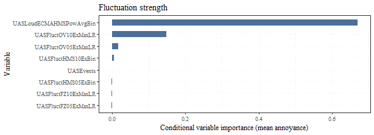

```r
par(mai=c(0,3,0,0))

# plot conditional importance
resultsOutFluctB.conimp <- data.frame('Var_imp'=rev(resultsOutFluctB$conditional_permimp))

pBar <- ggplot(resultsOutFluctB.conimp) + geom_col(aes(x=factor(rownames(resultsOutFluctB.conimp), levels=rownames(resultsOutFluctB.conimp)), y=Var_imp), fill=mycolours[4], width=0.5) + labs(x="Variable", y="Conditional variable importance (mean annoyance)") + ggtitle("Fluctuation strength") + theme(text = element_text(family = "serif"), panel.grid=element_line(color = rgb(235, 235, 235, 100, maxColorValue = 255), linewidth = 0.25, linetype = 2))
pBar + coord_flip()
```

```r
if (saveplots){
  ggsave(filename="PtBAnnoyMnFluctConPermimp.svg", width=8, height=2.9, path=file.path(outFigPath, "svg"))
  unlink("PtBAnnoyMnFluctConPermimp.svg")

  ggsave(filename="PtBAnnoyMnFluctConPermimp.pdf", width=8, height=2.9, path=file.path(outFigPath, "pdf"))
  unlink("PtBAnnoyMnFluctConPermimp.pdf")
}
```

```r
# Roughness
iVars <- c("UASLoudECMAHMSPowAvgBin", "UASEvents", "UASRoughECMAHMS10ExBin", "UASRoughECMAHMS05ExBin", "UASRoughFZ10ExMaxLR", "UASRoughFZ05ExMaxLR", "UASRoughDW10ExMaxLR", "UASRoughDW05ExMaxLR")
resultsOutRoughB <- multi_crfReg(dataIn=stimDataBNum, iVars=iVars, dVar='AnnoyMean', seeds=c(24565, 175049, 180785, 681465, 15789), ntree=1000, mtry=as.integer(length(iVars)/1.25), minsplit=10, minbucket=5, nperm=5)

# print model prediction results
resultsOutRoughB$OOB_RMSE
```

```
[1] 1.066918
```

```r
resultsOutRoughB$OOB_abserror
```

```
        0%        25%        50%        75%       100%
0.08275613 0.19958398 0.44246028 0.61347373 3.89161010
```

```r
resultsOutRoughB$Rsquared
```

```
[1] 0.3853941
```

```r
# store results
resAnnoyMnFitB['Abs rough', 'RMSE'] <- resultsOutRoughB$OOB_RMSE
resAnnoyMnFitB['Abs rough', 'Rsquared'] <- resultsOutRoughB$Rsquared
resAnnoyMnFitB['Abs rough', which(colnames(resAnnoyMnFitB) == 'AEq0'):
                             which(colnames(resAnnoyMnFitB) == 'AEq100')] <- resultsOutRoughB$OOB_abserror
resAnnoyMnPermImpB$AbsRough <- resultsOutRoughB$conditional_permimp
```

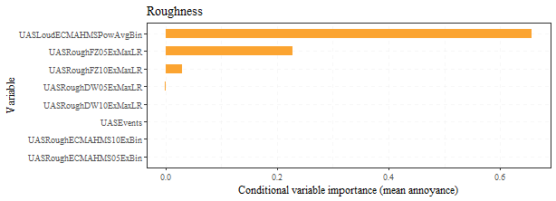

```r
par(mai=c(0,3,0,0))

# plot conditional importance
resultsOutRoughB.conimp <- data.frame('Var_imp'=rev(resultsOutRoughB$conditional_permimp))

pBar <- ggplot(resultsOutRoughB.conimp) + geom_col(aes(x=factor(rownames(resultsOutRoughB.conimp), levels=rownames(resultsOutRoughB.conimp)), y=Var_imp), fill=mycolours[5], width=0.5) + labs(x="Variable", y="Conditional variable importance (mean annoyance)") + ggtitle("Roughness") + theme(text = element_text(family = "serif"), panel.grid=element_line(color = rgb(235, 235, 235, 100, maxColorValue = 255), linewidth = 0.25, linetype = 2))
pBar + coord_flip()
```

```r
if (saveplots){
  ggsave(filename="PtBAnnoyMnRoughConPermimp.svg", width=8, height=2.9, path=file.path(outFigPath, "svg"))
  unlink("PtBAnnoyMnRoughConPermimp.svg")

  ggsave(filename="PtBAnnoyMnRoughConPermimp.pdf", width=8, height=2.9, path=file.path(outFigPath, "pdf"))
  unlink("PtBAnnoyMnRoughConPermimp.pdf")
}
```

```r
# Impulsiveness
iVars <- c("UASLoudECMAHMSPowAvgBin", "UASEvents", "UASImpulsHMSAvgMaxLR", "UASImpulsHMS05ExMaxLR", "UASImpulsHMSPowAvgMaxLR")
resultsOutImpulsB <- multi_crfReg(dataIn=stimDataBNum, iVars=iVars, dVar='AnnoyMean', seeds=c(6364, 50, 7908253, 9841, 560981), ntree=1000, mtry=as.integer(length(iVars)/1.25), minsplit=10, minbucket=5, nperm=5)

# print model prediction results
resultsOutImpulsB$OOB_RMSE
```

```
[1] 1.110375
```

```r
resultsOutImpulsB$OOB_abserror
```

```
       0%       25%       50%       75%      100%
0.1382653 0.2887628 0.4376243 0.7165415 3.9176055
```

```r
resultsOutImpulsB$Rsquared
```

```
[1] 0.3108574
```

```r
# store results
resAnnoyMnFitB['Abs impuls', 'RMSE'] <- resultsOutImpulsB$OOB_RMSE
resAnnoyMnFitB['Abs impuls', 'Rsquared'] <- resultsOutImpulsB$Rsquared
resAnnoyMnFitB['Abs impuls', which(colnames(resAnnoyMnFitB) == 'AEq0'):
                             which(colnames(resAnnoyMnFitB) == 'AEq100')] <- resultsOutImpulsB$OOB_abserror
resAnnoyMnPermImpB$AbsImpuls <- resultsOutImpulsB$conditional_permimp
```

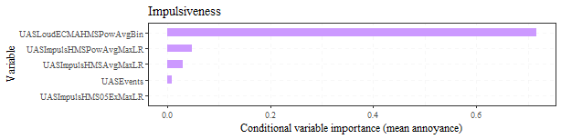

```r
par(mai=c(0,3,0,0))

# plot conditional importance
resultsOutImpulsB.conimp <- data.frame('Var_imp'=rev(resultsOutImpulsB$conditional_permimp))

pBar <- ggplot(resultsOutImpulsB.conimp) + geom_col(aes(x=factor(rownames(resultsOutImpulsB.conimp), levels=rownames(resultsOutImpulsB.conimp)), y=Var_imp), fill=mycolours[6], width=0.5) + labs(x="Variable", y="Conditional variable importance (mean annoyance)") + ggtitle("Impulsiveness") + theme(text = element_text(family = "serif"), panel.grid=element_line(color = rgb(235, 235, 235, 100, maxColorValue = 255), linewidth = 0.25, linetype = 2))
pBar + coord_flip()
```

```r
if (saveplots){
  ggsave(filename="PtBAnnoyMnImpulsConPermimp.svg", width=8, height=2, path=file.path(outFigPath, "svg"))
  unlink("PtBAnnoyMnImpulsConPermimp.svg")

  ggsave(filename="PtBAnnoyMnImpulsConPermimp.pdf", width=8, height=2, path=file.path(outFigPath, "pdf"))
  unlink("PtBAnnoyMnImpulsConPermimp.pdf")
}
```

#### SQM and loudness comparison

```r
iVars <- c("UASLoudECMAHMSPowAvgBin", "UASEvents", "UASSharpAuresISO3PowAvgMaxLR", "UASTonLdECMAHMSPowAvgBin", "UASFluctOV10ExMaxLR", "UASRoughFZ10ExMaxLR", "UASImpulsHMSAvgMaxLR")
resultsOutSQMs1B <- multi_crfReg(dataIn=stimDataBNum, iVars=iVars, dVar='AnnoyMean', seeds=c(8491, 5427, 68494, 496283, 509849), ntree=1000, mtry=as.integer(length(iVars)/1.25), minsplit=10, minbucket=5, nperm=5)

# print model prediction results
resultsOutSQMs1B$OOB_RMSE
```

```
[1] 1.049707
```

```r
resultsOutSQMs1B$OOB_abserror
```

```
        0%        25%        50%        75%       100%
0.09433036 0.18447607 0.42291570 0.58553570 3.87316652
```

```r
resultsOutSQMs1B$Rsquared
```

```
[1] 0.4236092
```

```r
# store results
resAnnoyMnFitB['Abs SQMs inc tonal loud', 'RMSE'] <- resultsOutSQMs1B$OOB_RMSE
resAnnoyMnFitB['Abs SQMs inc tonal loud', 'Rsquared'] <- resultsOutSQMs1B$Rsquared
resAnnoyMnFitB['Abs SQMs inc tonal loud', which(colnames(resAnnoyMnFitB) == 'AEq0'):
                                          which(colnames(resAnnoyMnFitB) == 'AEq100')] <- resultsOutSQMs1B$OOB_abserror
resAnnoyMnPermImpB$AbsSQMs1 <- resultsOutSQMs1B$conditional_permimp
```

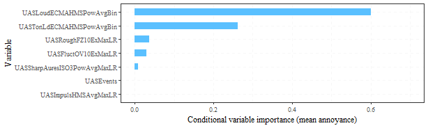

```r
par(mai=c(0,3,0,0))

# plot conditional importance
resultsOutSQMs1B.conimp <- data.frame('Var_imp'=rev(resultsOutSQMs1B$conditional_permimp))

pBar <- ggplot(resultsOutSQMs1B.conimp) + geom_col(aes(x=factor(rownames(resultsOutSQMs1B.conimp), levels=rownames(resultsOutSQMs1B.conimp)), y=Var_imp), fill=mycolours[7], width=0.5) + labs(x="Variable", y="Conditional variable importance (mean annoyance)") + theme(text = element_text(family = "serif"), panel.grid=element_line(color = rgb(235, 235, 235, 100, maxColorValue = 255), linewidth = 0.25, linetype = 2))
pBar + coord_flip(ylim=c(0, 0.7))
```

```r
if (saveplots){
  ggsave(filename="PtBAnnoyMnAbsSQMsTonLdConPermimp.svg", width=8, height=2.4, path=file.path(outFigPath, "svg"))
  unlink("PtBAnnoyMnAbsSQMsTonLdConPermimp.svg")

  ggsave(filename="PtBAnnoyMnAbsSQMsTonLdConPermimp.pdf", width=8, height=2.4, path=file.path(outFigPath, "pdf"))
  unlink("PtBAnnoyMnAbsSQMsTonLdConPermimp.pdf")
}
```

Repeated without tonal loudness

```r
iVars <- c("UASLoudECMAHMSPowAvgBin", "UASEvents", "UASSharpAuresISO3PowAvgMaxLR", "UASTonalAu10ExMaxLR", "UASFluctOV10ExMaxLR", "UASRoughFZ10ExMaxLR", "UASImpulsHMSAvgMaxLR")
resultsOutSQMs2B <- multi_crfReg(dataIn=stimDataBNum, iVars=iVars, dVar='AnnoyMean', seeds=c(179854, 98481, 5374, 56, 18049), ntree=1000, mtry=as.integer(length(iVars)/1.25), minsplit=10, minbucket=5, nperm=5)

# print model prediction results
resultsOutSQMs2B$OOB_RMSE
```

```
[1] 1.075066
```

```r
resultsOutSQMs2B$OOB_abserror
```

```
       0%       25%       50%       75%      100%
0.0569538 0.2805131 0.4701480 0.6292449 3.9066751
```

```r
resultsOutSQMs2B$Rsquared
```

```
[1] 0.3893549
```

```r
# store results
resAnnoyMnFitB['Abs SQMs no tonal loud', 'RMSE'] <- resultsOutSQMs2B$OOB_RMSE
resAnnoyMnFitB['Abs SQMs no tonal loud', 'Rsquared'] <- resultsOutSQMs2B$Rsquared
resAnnoyMnFitB['Abs SQMs no tonal loud', which(colnames(resAnnoyMnFitB) == 'AEq0'):
                                          which(colnames(resAnnoyMnFitB) == 'AEq100')] <- resultsOutSQMs2B$OOB_abserror
resAnnoyMnPermImpB$AbsSQMs2 <- resultsOutSQMs2B$conditional_permimp
```

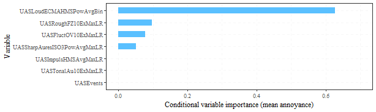

```r
par(mai=c(0,3,0,0))

# plot conditional importance
resultsOutSQMs2B.conimp <- data.frame('Var_imp'=rev(resultsOutSQMs2B$conditional_permimp))

pBar <- ggplot(resultsOutSQMs2B.conimp) + geom_col(aes(x=factor(rownames(resultsOutSQMs2B.conimp), levels=rownames(resultsOutSQMs2B.conimp)), y=Var_imp), fill=mycolours[7], width=0.5) + labs(x="Variable", y="Conditional variable importance (mean annoyance)") + theme(text = element_text(family = "serif"), panel.grid=element_line(color = rgb(235, 235, 235, 100, maxColorValue = 255), linewidth = 0.25, linetype = 2))
pBar + coord_flip(ylim=c(0, 0.7))
```

```r
if (saveplots){
  ggsave(filename="PtBAnnoyMnAbsSQMsNoTonLdConPermimp.svg", width=8, height=2.4, path=file.path(outFigPath, "svg"))
  unlink("PtBAnnoyMnAbsSQMsNoTonLdConPermimp.svg")

  ggsave(filename="PtBAnnoyMnAbsSQMsNoTonLdConPermimp.pdf", width=8, height=2.4, path=file.path(outFigPath, "pdf"))
  unlink("PtBAnnoyMnAbsSQMsNoTonLdConPermimp.pdf")

}
```

### Difference variables

Next, the difference metrics are analysed,

#### Remove ambient only stimuli

Here, the ‘ambient only’ stimuli are removed, as the analysis cannot handle missing values for dB metrics.

```r
stimDataBNum <- stimDataBNum[complete.cases(stimDataBNum),]
stimDataBNum$UASLAeq <- as.numeric(stimDataBNum$UASLAeq)
stimDataBNum$SNRlevel <- as.numeric(stimDataBNum$SNRlevel)
```

```r
iVars <- c(names(stimDataBNum)[which(colnames(stimDataBNum)=="LAeqdiffLAF90"):
                               which(colnames(stimDataBNum)=="dImpulsHMS05ExMaxLR")], "SNRlevel", "UASEvents")
resultsOutDiffsB <- multi_crfReg(dataIn=stimDataBNum, iVars=iVars, dVar='AnnoyMean', seeds=c(389, 54954154, 156098, 75981, 98651), ntree=1000, mtry=as.integer(length(iVars)/1.25), minsplit=10, minbucket=5, nperm=5)

# print model prediction results
resultsOutDiffsB$OOB_RMSE
```

```
[1] 0.4563624
```

```r
resultsOutDiffsB$OOB_abserror
```

```
         0%         25%         50%         75%        100%
0.004304788 0.091804685 0.248522510 0.554659234 0.998478581
```

```r
resultsOutDiffsB$Rsquared
```

```
[1] 0.7460011
```

```r
# store results
resAnnoyMnFitB['Diff vars', 'RMSE'] <- resultsOutDiffsB$OOB_RMSE
resAnnoyMnFitB['Diff vars', 'Rsquared'] <- resultsOutDiffsB$Rsquared
resAnnoyMnFitB['Diff vars', which(colnames(resAnnoyMnFitB) == 'AEq0'):
                            which(colnames(resAnnoyMnFitB) == 'AEq100')] <- resultsOutDiffsB$OOB_abserror
resAnnoyMnPermImpB$DiffVars <- resultsOutDiffsB$conditional_permimp
```

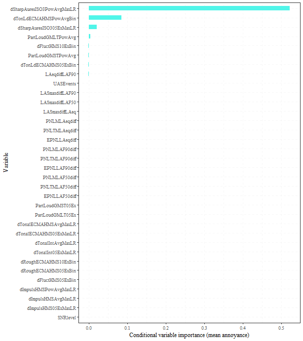

```r
par(mai=c(0,3,0,0))

# plot conditional importance
resultsOutDiffsB.conimp <- data.frame('Var_imp'=rev(resultsOutDiffsB$conditional_permimp))

pBar <- ggplot(resultsOutDiffsB.conimp) + geom_col(aes(x=factor(rownames(resultsOutDiffsB.conimp), levels=rownames(resultsOutDiffsB.conimp)), y=Var_imp), fill=mycolours[8], width=0.5) + labs(x="Variable", y="Conditional variable importance (mean annoyance)") + theme(text = element_text(family = "serif"), panel.grid=element_line(color = rgb(235, 235, 235, 100, maxColorValue = 255), linewidth = 0.25, linetype = 2))
pBar + coord_flip()
```

```r
if (saveplots){
  ggsave(filename="PtBAnnoyMnDiffVarsConPermimp.svg", width=8, height=9, path=file.path(outFigPath, "svg"))
  unlink("PtBAnnoyMnDiffVarsConPermimp.svg")

  ggsave(filename="PtBAnnoyMnDiffVarsConPermimp.pdf", width=8, height=9, path=file.path(outFigPath, "pdf"))
  unlink("PtBAnnoyMnDiffVarsConPermimp.pdf")
}
```

Save the results outputs to file

```r
if (savedata){
  utils::write.csv(resAnnoyMnFitB, paste(outDataPath, "\\ptBCRFAnnoyMnOOBFit.csv", sep=""))
  ii <- 0
  temp = list()
  for (res in resAnnoyMnPermImpB){
    ii <- ii + 1
    temp[[ii]] <- as.data.frame(resAnnoyMnPermImpB[ii])
    names(temp[[ii]]) <- names(resAnnoyMnPermImpB[ii])
  }
  openxlsx::write.xlsx(temp, paste(outDataPath, "\\ptBCRFAnnoyMnConPermimp.xlsx",
                                   sep=""),
                       rowNames=TRUE)
}
```

## Median change in annoyance

### Absolute variables

The random forest modelling is run on the aggregated data, including all the variables.

#### Remove ambient only stimuli

Here, the ‘ambient only’ stimuli are removed, as the analysis cannot handle missing values for dB metrics.

```r
stimDataBNum <- stimDataBNum[complete.cases(stimDataBNum),]

stimDataBNum$UASLAeq <- as.numeric(stimDataBNum$UASLAeq)
stimDataBNum$SNRlevel <- as.numeric(stimDataBNum$SNRlevel)
```

```r
resdAnnoyMedFitB <- data.frame(RMSE = numeric(),
                               Rsquared = numeric(),
                               AEq0 = numeric(),
                               AEq25 = numeric(),
                               AEq50 = numeric(),
                               AEq75 = numeric(),
                               AEq100 = numeric())
resdAnnoyMedPermImpB <- list()
```

```r
iVars <- names(stimDataBNum)[which(names(stimDataBNum) == 'UASEvents'):which(names(stimDataBNum) == 'UASImpulsHMS05ExMaxLR')]
iVars <- iVars[! iVars %in% 'SNRlevel']
resultsOutAbsB <- multi_crfReg(dataIn=stimDataBNum, iVars=iVars, dVar='dAnnoyMedian', seeds=c(54654, 15102, 8405, 10, 9174), ntree=1000, mtry=as.integer(length(iVars)/1.25), minsplit=10, minbucket=5, nperm=5)

# print model prediction results
resultsOutAbsB$OOB_RMSE
```

```
[1] 0.8251721
```

```r
resultsOutAbsB$OOB_abserror
```

```
   0%   25%   50%   75%  100%
0.000 0.325 1.000 1.000 1.000
```

```r
resultsOutAbsB$Rsquared
```

```
[1] 0.3267277
```

```r
# store results
resdAnnoyMedFitB['Abs vars', 'RMSE'] <- resultsOutAbsB$OOB_RMSE
resdAnnoyMedFitB['Abs vars', 'Rsquared'] <- resultsOutAbsB$Rsquared
resdAnnoyMedFitB['Abs vars', which(colnames(resdAnnoyMedFitB) == 'AEq0'):
                             which(colnames(resdAnnoyMedFitB) == 'AEq100')] <- resultsOutAbsB$OOB_abserror
resdAnnoyMedPermImpB$AbsVars <- resultsOutAbsB$conditional_permimp
```

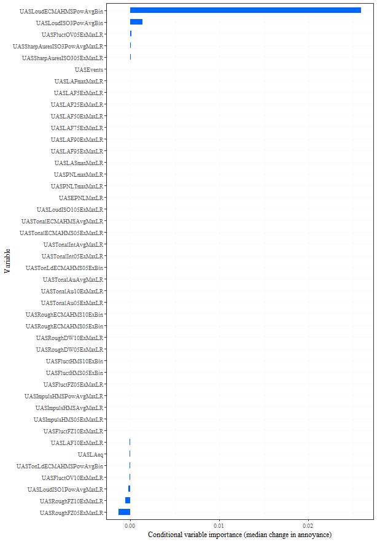

```r
par(mai=c(0,3,0,0))

# plot conditional importance
resultsOutAbsB.conimp <- data.frame('Var_imp'=rev(resultsOutAbsB$conditional_permimp))

pBar <- ggplot(resultsOutAbsB.conimp) + geom_col(aes(x=factor(rownames(resultsOutAbsB.conimp), levels=rownames(resultsOutAbsB.conimp)), y=Var_imp), fill=mycolours[1], width=0.5) + labs(x="Variable", y="Conditional variable importance (median change in annoyance)") + theme(text = element_text(family = "serif"), panel.grid=element_line(color = rgb(235, 235, 235, 100, maxColorValue = 255), linewidth = 0.25, linetype = 2))
pBar + coord_flip()
```

```r
if (saveplots){
  ggsave(filename="PtBdAnnoyAbsVarsConPermimp.svg", width=8, height=11.5, path=file.path(outFigPath, "svg"))
  unlink("PtBdAnnoyAbsVarsConPermimp.svg")

  ggsave(filename="PtBdAnnoyAbsVarsConPermimp.pdf", width=8, height=11.5, path=file.path(outFigPath, "pdf"))
  unlink("PtBdAnnoyAbsVarsConPermimp.pdf")
}
```

### SQM analysis

#### Replace ambient only stimuli

Here, the ‘ambient only’ stimuli are replaced, as the SQM analysis can incorporate 0 values (whereas dB metrics cannot be handled in this way).

```r
stimDataBNum <- rbind(stimDataBNum, stimDataB[stimDataB['Recording']
                                              == "B2_CALBIN_Pa.wav",
                                              colnames(stimDataBNum)])
stimDataBNum <- arrange(stimDataBNum, Recording)
```

#### Individual SQMs

Now a model is run omitting loudness and level variables, while retaining only (one of) the top importance loudness variables, and each category of SQM in turn.

```r
# Sharpness
iVars <- c("UASLoudECMAHMSPowAvgBin", "UASEvents", "UASSharpAuresISO3PowAvgMaxLR", "UASSharpAuresISO305ExMaxLR")
resultsOutSharpB <- multi_crfReg(dataIn=stimDataBNum, iVars=iVars, dVar='dAnnoyMedian', seeds=c(8605, 322, 7460, 98, 1984), ntree=1000, mtry=as.integer(length(iVars)/1.25), minsplit=10, minbucket=5, nperm=5)

# print model prediction results
resultsOutSharpB$OOB_RMSE
```

```
[1] 1.271868
```

```r
resultsOutSharpB$OOB_abserror
```

```
  0%  25%  50%  75% 100%
 0.0  0.5  1.0  1.0  4.0
```

```r
resultsOutSharpB$Rsquared
```

```
[1] 0.2877963
```

```r
# store results
resdAnnoyMedFitB['Abs sharp', 'RMSE'] <- resultsOutSharpB$OOB_RMSE
resdAnnoyMedFitB['Abs sharp', 'Rsquared'] <- resultsOutSharpB$Rsquared
resdAnnoyMedFitB['Abs sharp', which(colnames(resdAnnoyMedFitB) == 'AEq0'):
                              which(colnames(resdAnnoyMedFitB) == 'AEq100')] <- resultsOutSharpB$OOB_abserror
resdAnnoyMedPermImpB$AbsSharp <- resultsOutSharpB$conditional_permimp
```

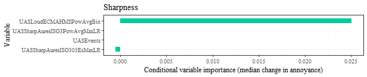

```r
par(mai=c(0,3,0,0))

# plot conditional importance
resultsOutSharpB.conimp <- data.frame('Var_imp'=rev(resultsOutSharpB$conditional_permimp))

pBar <- ggplot(resultsOutSharpB.conimp) + geom_col(aes(x=factor(rownames(resultsOutSharpB.conimp), levels=rownames(resultsOutSharpB.conimp)), y=Var_imp), fill=mycolours[2], width=0.5) + labs(x="Variable", y="Conditional variable importance (median change in annoyance)") + ggtitle("Sharpness") + theme(text = element_text(family = "serif"), panel.grid=element_line(color = rgb(235, 235, 235, 100, maxColorValue = 255), linewidth = 0.25, linetype = 2))
pBar + coord_flip()
```

```r
if (saveplots){
  ggsave(filename="PtBdAnnoySharpConPermimp.svg", width=8, height=1.7, path=file.path(outFigPath, "svg"))
  unlink("PtBdAnnoySharpConPermimp.svg")

  ggsave(filename="PtBdAnnoySharpConPermimp.pdf", width=8, height=1.7, path=file.path(outFigPath, "pdf"))
  unlink("PtBdAnnoySharpConPermimp.pdf")
}
```

Tonality including tonal loudness

```r
# Tonality inc tonal loudness
iVars <- c("UASLoudECMAHMSPowAvgBin", "UASEvents", "UASTonalECMAHMSAvgMaxLR", "UASTonalECMAHMS05ExMaxLR", "UASTonalIntAvgMaxLR", "UASTonalInt05ExMaxLR", "UASTonLdECMAHMSPowAvgBin", "UASTonLdECMAHMS05ExBin", "UASTonalAuAvgMaxLR", "UASTonalAu05ExMaxLR", "UASTonalAu10ExMaxLR")
resultsOutTonal1B <- multi_crfReg(dataIn=stimDataBNum, iVars=iVars, dVar='dAnnoyMedian', seeds=c(324505, 1324, 5078, 508, 780), ntree=1000, mtry=as.integer(length(iVars)/1.25), minsplit=10, minbucket=5, nperm=5)

# print model prediction results
resultsOutTonal1B$OOB_RMSE
```

```
[1] 1.271868
```

```r
resultsOutTonal1B$OOB_abserror
```

```
  0%  25%  50%  75% 100%
 0.0  0.5  1.0  1.0  4.0
```

```r
resultsOutTonal1B$Rsquared
```

```
[1] 0.2439962
```

```r
# store results
resdAnnoyMedFitB['Abs inc tonal loud', 'RMSE'] <- resultsOutTonal1B$OOB_RMSE
resdAnnoyMedFitB['Abs inc tonal loud', 'Rsquared'] <- resultsOutTonal1B$Rsquared
resdAnnoyMedFitB['Abs inc tonal loud', which(colnames(resdAnnoyMedFitB) == 'AEq0'):
                                       which(colnames(resdAnnoyMedFitB) == 'AEq100')] <- resultsOutTonal1B$OOB_abserror
resdAnnoyMedPermImpB$AbsTonal1 <- resultsOutTonal1B$conditional_permimp
```

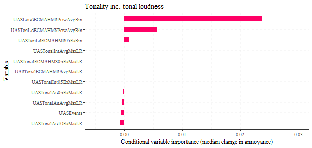

```r
par(mai=c(0,3,0,0))

# plot conditional importance
resultsOutTonal1B.conimp <- data.frame('Var_imp'=rev(resultsOutTonal1B$conditional_permimp))

pBar <- ggplot(resultsOutTonal1B.conimp) + geom_col(aes(x=factor(rownames(resultsOutTonal1B.conimp), levels=rownames(resultsOutTonal1B.conimp)), y=Var_imp), fill=mycolours[3], width=0.5) + labs(x="Variable", y="Conditional variable importance (median change in annoyance)") + ggtitle("Tonality inc. tonal loudness") + theme(text = element_text(family = "serif"), panel.grid=element_line(color = rgb(235, 235, 235, 100, maxColorValue = 255), linewidth = 0.25, linetype = 2))
pBar + coord_flip(ylim=c(-0.005, 0.03))
```

```r
if (saveplots){
  ggsave(filename="PtBdAnnoyTonalLdConPermimp.svg", width=8, height=3.8, path=file.path(outFigPath, "svg"))
  unlink("PtBdAnnoyTonalLdConPermimp.svg")

  ggsave(filename="PtBdAnnoyTonalLdConPermimp.pdf", width=8, height=3.8, path=file.path(outFigPath, "pdf"))
  unlink("PtBdAnnoyTonalLdConPermimp.pdf")
}
```

Re-run tonality evaluation omitting tonal loudness

```r
# Tonality
iVars <- c("UASLoudECMAHMSPowAvgBin", "UASEvents", "UASTonalECMAHMSAvgMaxLR", "UASTonalECMAHMS05ExMaxLR", "UASTonalIntAvgMaxLR", "UASTonalInt05ExMaxLR", "UASTonalAuAvgMaxLR", "UASTonalAu05ExMaxLR", "UASTonalAu10ExMaxLR")
resultsOutTonal2B <- multi_crfReg(dataIn=stimDataBNum, iVars=iVars, dVar='dAnnoyMedian', seeds=c(324505, 1324, 5078, 508, 780), ntree=1000, mtry=as.integer(length(iVars)/1.25), minsplit=10, minbucket=5, nperm=5)

# print model prediction results
resultsOutTonal2B$OOB_RMSE
```

```
[1] 1.271868
```

```r
resultsOutTonal2B$OOB_abserror
```

```
  0%  25%  50%  75% 100%
 0.0  0.5  1.0  1.0  4.0
```

```r
resultsOutTonal2B$Rsquared
```

```
[1] 0.2675954
```

```r
# store results
resdAnnoyMedFitB['Abs no tonal loud', 'RMSE'] <- resultsOutTonal2B$OOB_RMSE
resdAnnoyMedFitB['Abs no tonal loud', 'Rsquared'] <- resultsOutTonal2B$Rsquared
resdAnnoyMedFitB['Abs no tonal loud', which(colnames(resdAnnoyMedFitB) == 'AEq0'):
                                     which(colnames(resdAnnoyMedFitB) == 'AEq100')] <- resultsOutTonal2B$OOB_abserror
resdAnnoyMedPermImpB$AbsTonal2 <- resultsOutTonal2B$conditional_permimp
```

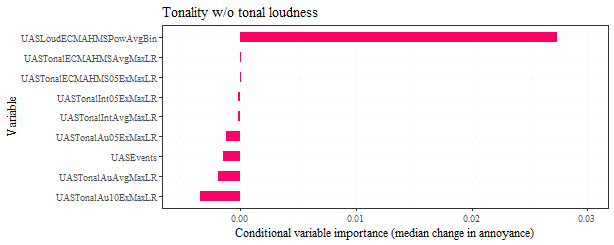

```r
par(mai=c(0,3,0,0))

# plot conditional importance
resultsOutTonal2B.conimp <- data.frame('Var_imp'=rev(resultsOutTonal2B$conditional_permimp))

pBar <- ggplot(resultsOutTonal2B.conimp) + geom_col(aes(x=factor(rownames(resultsOutTonal2B.conimp), levels=rownames(resultsOutTonal2B.conimp)), y=Var_imp), fill=mycolours[3], width=0.5) + labs(x="Variable", y="Conditional variable importance (median change in annoyance)") + ggtitle("Tonality w/o tonal loudness") + theme(text = element_text(family = "serif"), panel.grid=element_line(color = rgb(235, 235, 235, 100, maxColorValue = 255), linewidth = 0.25, linetype = 2))
pBar + coord_flip(ylim=c(-0.005, 0.03))
```

```r
if (saveplots){
  ggsave(filename="PtBdAnnoyTonalNoLdConPermimp.svg", width=8, height=3.2, path=file.path(outFigPath, "svg"))
  unlink("PtBdAnnoyTonalNoLdConPermimp.svg")

  ggsave(filename="PtBdAnnoyTonalNoLdConPermimp.pdf", width=8, height=3.2, path=file.path(outFigPath, "pdf"))
  unlink("PtBdAnnoyTonalNoLdConPermimp.pdf")
}
```

```r
# Fluctuation strength
iVars <- c("UASLoudECMAHMSPowAvgBin", "UASEvents", "UASFluctHMS10ExBin", "UASFluctHMS05ExBin", "UASFluctFZ10ExMaxLR", "UASFluctFZ05ExMaxLR", "UASFluctOV10ExMaxLR", "UASFluctOV05ExMaxLR")
resultsOutFluctB <- multi_crfReg(dataIn=stimDataBNum, iVars=iVars, dVar='dAnnoyMedian', seeds=c(724, 2298, 70460, 541, 7456), ntree=1000, mtry=as.integer(length(iVars)/1.25), minsplit=10, minbucket=5, nperm=5)

# print model prediction results
resultsOutFluctB$OOB_RMSE
```

```
[1] 1.2672
```

```r
resultsOutFluctB$OOB_abserror
```

```
       0%       25%       50%       75%      100%
0.0000000 0.4666667 1.0000000 1.0000000 4.0000000
```

```r
resultsOutFluctB$Rsquared
```

```
[1] 0.2743054
```

```r
# store results
resdAnnoyMedFitB['Abs fluct', 'RMSE'] <- resultsOutFluctB$OOB_RMSE
resdAnnoyMedFitB['Abs fluct', 'Rsquared'] <- resultsOutFluctB$Rsquared
resdAnnoyMedFitB['Abs fluct', which(colnames(resdAnnoyMedFitB) == 'AEq0'):
                             which(colnames(resdAnnoyMedFitB) == 'AEq100')] <- resultsOutFluctB$OOB_abserror
resdAnnoyMedPermImpB$AbsFluct <- resultsOutFluctB$conditional_permimp
```

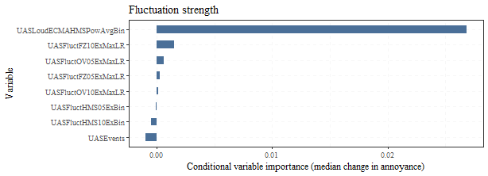

```r
par(mai=c(0,3,0,0))

# plot conditional importance
resultsOutFluctB.conimp <- data.frame('Var_imp'=rev(resultsOutFluctB$conditional_permimp))

pBar <- ggplot(resultsOutFluctB.conimp) + geom_col(aes(x=factor(rownames(resultsOutFluctB.conimp), levels=rownames(resultsOutFluctB.conimp)), y=Var_imp), fill=mycolours[4], width=0.5) + labs(x="Variable", y="Conditional variable importance (median change in annoyance)") + ggtitle("Fluctuation strength") + theme(text = element_text(family = "serif"), panel.grid=element_line(color = rgb(235, 235, 235, 100, maxColorValue = 255), linewidth = 0.25, linetype = 2))
pBar + coord_flip()
```

```r
if (saveplots){
  ggsave(filename="PtBdAnnoyFluctConPermimp.svg", width=8, height=2.9, path=file.path(outFigPath,  "svg"))
  unlink("PtBdAnnoyFluctConPermimp.svg")

  ggsave(filename="PtBdAnnoyFluctConPermimp.pdf", width=8, height=2.9, path=file.path(outFigPath,  "pdf"))
  unlink("PtBdAnnoyFluctConPermimp.pdf")
}
```

```r
# Roughness
iVars <- c("UASLoudECMAHMSPowAvgBin", "UASEvents", "UASRoughECMAHMS10ExBin", "UASRoughECMAHMS05ExBin", "UASRoughFZ10ExMaxLR", "UASRoughFZ05ExMaxLR", "UASRoughDW10ExMaxLR", "UASRoughDW05ExMaxLR")
resultsOutRoughB <- multi_crfReg(dataIn=stimDataBNum, iVars=iVars, dVar='dAnnoyMedian', seeds=c(1508, 850, 8, 7804, 38), ntree=1000, mtry=as.integer(length(iVars)/1.25), minsplit=10, minbucket=5, nperm=5)

# print model prediction results
resultsOutRoughB$OOB_RMSE
```

```
[1] 1.271868
```

```r
resultsOutRoughB$OOB_abserror
```

```
  0%  25%  50%  75% 100%
 0.0  0.5  1.0  1.0  4.0
```

```r
resultsOutRoughB$Rsquared
```

```
[1] 0.2477369
```

```r
# store results
resdAnnoyMedFitB['Abs rough', 'RMSE'] <- resultsOutRoughB$OOB_RMSE
resdAnnoyMedFitB['Abs rough', 'Rsquared'] <- resultsOutRoughB$Rsquared
resdAnnoyMedFitB['Abs rough', which(colnames(resdAnnoyMedFitB) == 'AEq0'):
                             which(colnames(resdAnnoyMedFitB) == 'AEq100')] <- resultsOutRoughB$OOB_abserror
resdAnnoyMedPermImpB$AbsRough <- resultsOutRoughB$conditional_permimp
```

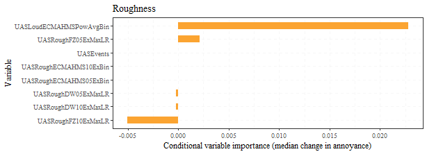

```r
par(mai=c(0,3,0,0))

# plot conditional importance
resultsOutRoughB.conimp <- data.frame('Var_imp'=rev(resultsOutRoughB$conditional_permimp))

pBar <- ggplot(resultsOutRoughB.conimp) + geom_col(aes(x=factor(rownames(resultsOutRoughB.conimp), levels=rownames(resultsOutRoughB.conimp)), y=Var_imp), fill=mycolours[5], width=0.5) + labs(x="Variable", y="Conditional variable importance (median change in annoyance)") + ggtitle("Roughness") + theme(text = element_text(family = "serif"), panel.grid=element_line(color = rgb(235, 235, 235, 100, maxColorValue = 255), linewidth = 0.25, linetype = 2))
pBar + coord_flip()
```

```r
if (saveplots){
  ggsave(filename="PtBdAnnoyRoughConPermimp.svg", width=8, height=2.9, path=file.path(outFigPath, "svg"))
  unlink("PtBdAnnoyRoughConPermimp.svg")

  ggsave(filename="PtBdAnnoyRoughConPermimp.pdf", width=8, height=2.9, path=file.path(outFigPath, "pdf"))
  unlink("PtBdAnnoyRoughConPermimp.pdf")
}
```

```r
# Impulsiveness
iVars <- c("UASLoudECMAHMSPowAvgBin", "UASEvents", "UASImpulsHMSAvgMaxLR", "UASImpulsHMS05ExMaxLR", "UASImpulsHMSPowAvgMaxLR")
resultsOutImpulsB <- multi_crfReg(dataIn=stimDataBNum, iVars=iVars, dVar='dAnnoyMedian', seeds=c(50278, 30561, 65740, 21, 155), ntree=1000, mtry=as.integer(length(iVars)/1.25), minsplit=10, minbucket=5, nperm=5)

# print model prediction results
resultsOutImpulsB$OOB_RMSE
```

```
[1] 1.253107
```

```r
resultsOutImpulsB$OOB_abserror
```

```
       0%       25%       50%       75%      100%
0.0000000 0.3333333 1.0000000 1.0000000 4.0000000
```

```r
resultsOutImpulsB$Rsquared
```

```
[1] 0.2960622
```

```r
# store results
resdAnnoyMedFitB['Abs impuls', 'RMSE'] <- resultsOutImpulsB$OOB_RMSE
resdAnnoyMedFitB['Abs impuls', 'Rsquared'] <- resultsOutImpulsB$Rsquared
resdAnnoyMedFitB['Abs impuls', which(colnames(resdAnnoyMedFitB) == 'AEq0'):
                             which(colnames(resdAnnoyMedFitB) == 'AEq100')] <- resultsOutImpulsB$OOB_abserror
resdAnnoyMedPermImpB$AbsImpuls <- resultsOutImpulsB$conditional_permimp
```

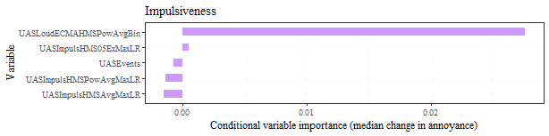

```r
par(mai=c(0,3,0,0))

# plot conditional importance
resultsOutImpulsB.conimp <- data.frame('Var_imp'=rev(resultsOutImpulsB$conditional_permimp))

pBar <- ggplot(resultsOutImpulsB.conimp) + geom_col(aes(x=factor(rownames(resultsOutImpulsB.conimp), levels=rownames(resultsOutImpulsB.conimp)), y=Var_imp), fill=mycolours[6], width=0.5) + labs(x="Variable", y="Conditional variable importance (median change in annoyance)") + ggtitle("Impulsiveness") + theme(text = element_text(family = "serif"), panel.grid=element_line(color = rgb(235, 235, 235, 100, maxColorValue = 255), linewidth = 0.25, linetype = 2))
pBar + coord_flip()
```

```r
if (saveplots){
  ggsave(filename="PtBdAnnoyImpulsConPermimp.svg", width=8, height=2, path=file.path(outFigPath, "svg"))
  unlink("PtBdAnnoyImpulsConPermimp.svg")

  ggsave(filename="PtBdAnnoyImpulsConPermimp.pdf", width=8, height=2, path=file.path(outFigPath, "pdf"))
  unlink("PtBdAnnoyImpulsConPermimp.pdf")
}
```

#### SQM and loudness comparison

```r
iVars <- c("UASLoudECMAHMSPowAvgBin", "UASEvents", "UASSharpAuresISO3PowAvgMaxLR", "UASTonLdECMAHMSPowAvgBin", "UASFluctFZ10ExMaxLR", "UASRoughFZ05ExMaxLR", "UASImpulsHMS05ExMaxLR")
resultsOutSQMs1B <- multi_crfReg(dataIn=stimDataBNum, iVars=iVars, dVar='dAnnoyMedian', seeds=c(4888, 50881, 804, 5470, 257), ntree=1000, mtry=as.integer(length(iVars)/1.25), minsplit=10, minbucket=5, nperm=5)

# print model prediction results
resultsOutSQMs1B$OOB_RMSE
```

```
[1] 1.271868
```

```r
resultsOutSQMs1B$OOB_abserror
```

```
  0%  25%  50%  75% 100%
 0.0  0.5  1.0  1.0  4.0
```

```r
resultsOutSQMs1B$Rsquared
```

```
[1] 0.2494066
```

```r
# store results
resdAnnoyMedFitB['Abs SQMs inc tonal loud', 'RMSE'] <- resultsOutSQMs1B$OOB_RMSE
resdAnnoyMedFitB['Abs SQMs inc tonal loud', 'Rsquared'] <- resultsOutSQMs1B$Rsquared
resdAnnoyMedFitB['Abs SQMs inc tonal loud', which(colnames(resdAnnoyMedFitB) == 'AEq0'):
                                          which(colnames(resdAnnoyMedFitB) == 'AEq100')] <- resultsOutSQMs1B$OOB_abserror
resdAnnoyMedPermImpB$AbsSQMs1 <- resultsOutSQMs1B$conditional_permimp
```

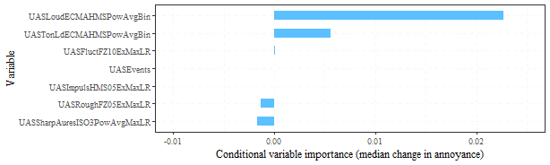

```r
par(mai=c(0,3,0,0))

# plot conditional importance
resultsOutSQMs1B.conimp <- data.frame('Var_imp'=rev(resultsOutSQMs1B$conditional_permimp))

pBar <- ggplot(resultsOutSQMs1B.conimp) + geom_col(aes(x=factor(rownames(resultsOutSQMs1B.conimp), levels=rownames(resultsOutSQMs1B.conimp)), y=Var_imp), fill=mycolours[7], width=0.5) + labs(x="Variable", y="Conditional variable importance (median change in annoyance)") + theme(text = element_text(family = "serif"), panel.grid=element_line(color = rgb(235, 235, 235, 100, maxColorValue = 255), linewidth = 0.25, linetype = 2))
pBar + coord_flip(ylim=c(-0.01, 0.025))
```

```r
if (saveplots){
  ggsave(filename="PtBdAnnoyAbsSQMsTonLdConPermimp.svg", width=8, height=2.4, path=file.path(outFigPath, "svg"))
  unlink("PtBdAnnoyAbsSQMsTonLdConPermimp.svg")

  ggsave(filename="PtBdAnnoyAbsSQMsTonLdConPermimp.pdf", width=8, height=2.4, path=file.path(outFigPath, "pdf"))
  unlink("PtBdAnnoyAbsSQMsTonLdConPermimp.pdf")
}
```

Repeated without tonal loudness

```r
iVars <- c("UASLoudECMAHMSPowAvgBin", "UASEvents", "UASSharpAuresISO3PowAvgMaxLR", "UASTonalECMAHMSAvgMaxLR", "UASFluctFZ10ExMaxLR", "UASRoughFZ05ExMaxLR", "UASImpulsHMS05ExMaxLR")
resultsOutSQMs2B <- multi_crfReg(dataIn=stimDataBNum, iVars=iVars, dVar='dAnnoyMedian', seeds=c(4888, 50881, 804, 5470, 257), ntree=1000, mtry=as.integer(length(iVars)/1.25), minsplit=10, minbucket=5, nperm=5)

# print model prediction results
resultsOutSQMs2B$OOB_RMSE
```

```
[1] 1.271868
```

```r
resultsOutSQMs2B$OOB_abserror
```

```
  0%  25%  50%  75% 100%
 0.0  0.5  1.0  1.0  4.0
```

```r
resultsOutSQMs2B$Rsquared
```

```
[1] 0.254817
```

```r
# store results
resdAnnoyMedFitB['Abs SQMs no tonal loud', 'RMSE'] <- resultsOutSQMs2B$OOB_RMSE
resdAnnoyMedFitB['Abs SQMs no tonal loud', 'Rsquared'] <- resultsOutSQMs2B$Rsquared
resdAnnoyMedFitB['Abs SQMs no tonal loud', which(colnames(resdAnnoyMedFitB) == 'AEq0'):
                                          which(colnames(resdAnnoyMedFitB) == 'AEq100')] <- resultsOutSQMs2B$OOB_abserror
resdAnnoyMedPermImpB$AbsSQMs2 <- resultsOutSQMs2B$conditional_permimp
```

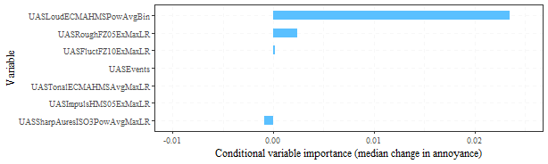

```r
par(mai=c(0,3,0,0))

# plot conditional importance
resultsOutSQMs2B.conimp <- data.frame('Var_imp'=rev(resultsOutSQMs2B$conditional_permimp))

pBar <- ggplot(resultsOutSQMs2B.conimp) + geom_col(aes(x=factor(rownames(resultsOutSQMs2B.conimp), levels=rownames(resultsOutSQMs2B.conimp)), y=Var_imp), fill=mycolours[7], width=0.5) + labs(x="Variable", y="Conditional variable importance (median change in annoyance)") + theme(text = element_text(family = "serif"), panel.grid=element_line(color = rgb(235, 235, 235, 100, maxColorValue = 255), linewidth = 0.25, linetype = 2))
pBar + coord_flip(ylim=c(-0.01, 0.025))
```

```r
if (saveplots){
  ggsave(filename="PtBdAnnoyAbsSQMsNoTonLdConPermimp.svg", width=8, height=2.4, path=file.path(outFigPath, "svg"))
  unlink("PtBdAnnoyAbsSQMsNoTonLdConPermimp.svg")

  ggsave(filename="PtBdAnnoyAbsSQMsNoTonLdConPermimp.pdf", width=8, height=2.4, path=file.path(outFigPath, "pdf"))
  unlink("PtBdAnnoyAbsSQMsNoTonLdConPermimp.pdf")
}
```

### Difference variables

Next, the difference metrics are analysed,

#### Remove ambient only stimuli

Here, the ‘ambient only’ stimuli are removed, as the analysis cannot handle missing values for dB metrics.

```r
stimDataBNum <- stimDataBNum[complete.cases(stimDataBNum),]
stimDataBNum$UASLAeq <- as.numeric(stimDataBNum$UASLAeq)
stimDataBNum$SNRlevel <- as.numeric(stimDataBNum$SNRlevel)
```

```r
iVars <- c(names(stimDataBNum)[which(colnames(stimDataBNum)=="LAeqdiffLAF90"):
                               which(colnames(stimDataBNum)=="dImpulsHMS05ExMaxLR")], "SNRlevel", "UASEvents")
resultsOutDiffsB <- multi_crfReg(dataIn=stimDataBNum, iVars=iVars, dVar='dAnnoyMedian', seeds=c(70765, 3277, 790150, 4308, 8888), ntree=1000, mtry=as.integer(length(iVars)/1.25), minsplit=10, minbucket=5, nperm=5)

# print model prediction results
resultsOutDiffsB$OOB_RMSE
```

```
[1] 0.8021844
```

```r
resultsOutDiffsB$OOB_abserror
```

```
       0%       25%       50%       75%      100%
0.0000000 0.1666667 1.0000000 1.0000000 1.0000000
```

```r
resultsOutDiffsB$Rsquared
```

```
[1] 0.3578761
```

```r
# store results
resdAnnoyMedFitB['Diff vars', 'RMSE'] <- resultsOutDiffsB$OOB_RMSE
resdAnnoyMedFitB['Diff vars', 'Rsquared'] <- resultsOutDiffsB$Rsquared
resdAnnoyMedFitB['Diff vars', which(colnames(resdAnnoyMedFitB) == 'AEq0'):
                            which(colnames(resdAnnoyMedFitB) == 'AEq100')] <- resultsOutDiffsB$OOB_abserror
resdAnnoyMedPermImpB$DiffVars <- resultsOutDiffsB$conditional_permimp
```

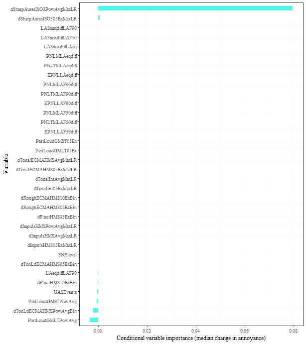

```r
par(mai=c(0,3,0,0))

# plot conditional importance
resultsOutDiffsB.conimp <- data.frame('Var_imp'=rev(resultsOutDiffsB$conditional_permimp))

pBar <- ggplot(resultsOutDiffsB.conimp) + geom_col(aes(x=factor(rownames(resultsOutDiffsB.conimp), levels=rownames(resultsOutDiffsB.conimp)), y=Var_imp), fill=mycolours[8], width=0.5) + labs(x="Variable", y="Conditional variable importance (median change in annoyance)") + theme(text = element_text(family = "serif"), panel.grid=element_line(color = rgb(235, 235, 235, 100, maxColorValue = 255), linewidth = 0.25, linetype = 2))
pBar + coord_flip()
```

```r
if (saveplots){
  ggsave(filename="PtBdAnnoyDiffVarsConPermimp.svg", width=8, height=9, path=file.path(outFigPath, "svg"))
  unlink("PtBdAnnoyDiffVarsConPermimp.svg")

  ggsave(filename="PtBdAnnoyDiffVarsConPermimp.pdf", width=8, height=9, path=file.path(outFigPath, "pdf"))
  unlink("PtBdAnnoyDiffVarsConPermimp.pdf")
}
```

Save the results outputs to file

```r
if (savedata){
  utils::write.csv(resdAnnoyMedFitB, paste(outDataPath, "\\ptBCRFdAnnoyOOBFit.csv", sep=""))
  ii <- 0
  temp = list()
  for (res in resdAnnoyMedPermImpB){
    ii <- ii + 1
    temp[[ii]] <- as.data.frame(resdAnnoyMedPermImpB[ii])
    names(temp[[ii]]) <- names(resdAnnoyMedPermImpB[ii])
  }
  openxlsx::write.xlsx(temp, paste(outDataPath, "\\ptBCRFdAnnoyConPermimp.xlsx",
                                   sep=""),
                       rowNames=TRUE)
}
```

## Mean change in annoyance

### Absolute variables

The random forest modelling is run on the aggregated data, including all the variables.

#### Remove ambient only stimuli

Here, the ‘ambient only’ stimuli are removed, as the analysis cannot handle missing values for dB metrics.

```r
stimDataBNum <- stimDataBNum[complete.cases(stimDataBNum),]

stimDataBNum$UASLAeq <- as.numeric(stimDataBNum$UASLAeq)
stimDataBNum$SNRlevel <- as.numeric(stimDataBNum$SNRlevel)
```

```r
resdAnnoyMnFitB <- data.frame(RMSE = numeric(),
                               Rsquared = numeric(),
                               AEq0 = numeric(),
                               AEq25 = numeric(),
                               AEq50 = numeric(),
                               AEq75 = numeric(),
                               AEq100 = numeric())
resdAnnoyMnPermImpB <- list()
```

```r
iVars <- names(stimDataBNum)[which(names(stimDataBNum) == 'UASEvents'):which(names(stimDataBNum) == 'UASImpulsHMS05ExMaxLR')]
iVars <- iVars[! iVars %in% 'SNRlevel']
resultsOutAbsB <- multi_crfReg(dataIn=stimDataBNum, iVars=iVars, dVar='dAnnoyMean', seeds=c(1849, 615879, 248699, 41, 291848), ntree=1000, mtry=as.integer(length(iVars)/1.25), minsplit=10, minbucket=5, nperm=5)

# print model prediction results
resultsOutAbsB$OOB_RMSE
```

```
[1] 0.5359177
```

```r
resultsOutAbsB$OOB_abserror
```

```
        0%        25%        50%        75%       100%
0.01193762 0.10110174 0.28256639 0.63369536 1.08910821
```

```r
resultsOutAbsB$Rsquared
```

```
[1] 0.6181302
```

```r
# store results
resdAnnoyMnFitB['Abs vars', 'RMSE'] <- resultsOutAbsB$OOB_RMSE
resdAnnoyMnFitB['Abs vars', 'Rsquared'] <- resultsOutAbsB$Rsquared
resdAnnoyMnFitB['Abs vars', which(colnames(resdAnnoyMnFitB) == 'AEq0'):
                             which(colnames(resdAnnoyMnFitB) == 'AEq100')] <- resultsOutAbsB$OOB_abserror
resdAnnoyMnPermImpB$AbsVars <- resultsOutAbsB$conditional_permimp
```

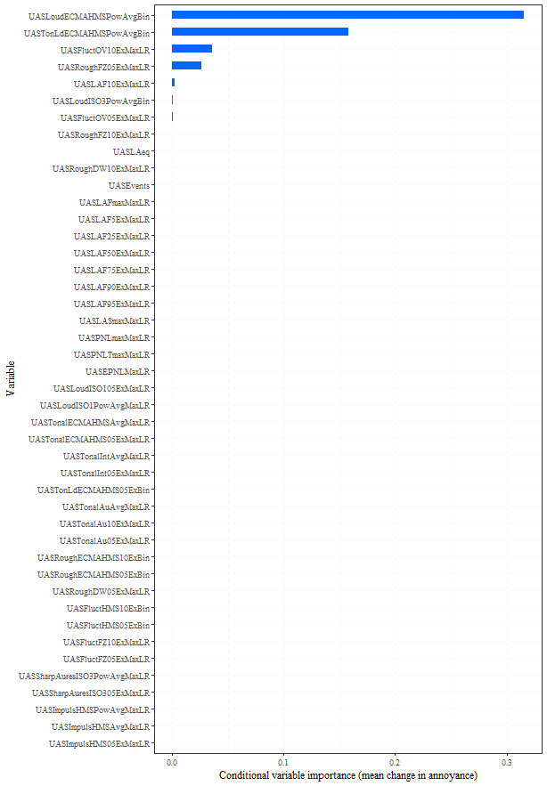

```r
par(mai=c(0,3,0,0))

# plot conditional importance
resultsOutAbsB.conimp <- data.frame('Var_imp'=rev(resultsOutAbsB$conditional_permimp))

pBar <- ggplot(resultsOutAbsB.conimp) + geom_col(aes(x=factor(rownames(resultsOutAbsB.conimp), levels=rownames(resultsOutAbsB.conimp)), y=Var_imp), fill=mycolours[1], width=0.5) + labs(x="Variable", y="Conditional variable importance (mean change in annoyance)") + theme(text = element_text(family = "serif"), panel.grid=element_line(color = rgb(235, 235, 235, 100, maxColorValue = 255), linewidth = 0.25, linetype = 2))
pBar + coord_flip()
```

```r
if (saveplots){
  ggsave(filename="PtBdAnnoyMnAbsVarsConPermimp.svg", width=8, height=11.5, path=file.path(outFigPath, "svg"))
  unlink("PtBdAnnoyMnAbsVarsConPermimp.svg")

  ggsave(filename="PtBdAnnoyMnAbsVarsConPermimp.pdf", width=8, height=11.5, path=file.path(outFigPath, "pdf"))
  unlink("PtBdAnnoyMnAbsVarsConPermimp.pdf")
}
```

### SQM analysis

#### Replace ambient only stimuli

Here, the ‘ambient only’ stimuli are replaced, as the SQM analysis can incorporate 0 values (whereas dB metrics cannot be handled in this way).

```r
stimDataBNum <- rbind(stimDataBNum, stimDataB[stimDataB['Recording']
                                              == "B2_CALBIN_Pa.wav",
                                              colnames(stimDataBNum)])
stimDataBNum <- arrange(stimDataBNum, Recording)
```

#### Individual SQMs

Now a model is run omitting loudness and level variables, while retaining only (one of) the top importance loudness variables, and each category of SQM in turn.

```r
# Sharpness
iVars <- c("UASLoudECMAHMSPowAvgBin", "UASEvents", "UASSharpAuresISO3PowAvgMaxLR", "UASSharpAuresISO305ExMaxLR")
resultsOutSharpB <- multi_crfReg(dataIn=stimDataBNum, iVars=iVars, dVar='dAnnoyMean', seeds=c(517184, 428, 5542, 948, 967180), ntree=1000, mtry=as.integer(length(iVars)/1.25), minsplit=10, minbucket=5, nperm=5)

# print model prediction results
resultsOutSharpB$OOB_RMSE
```

```
[1] 1.082127
```

```r
resultsOutSharpB$OOB_abserror
```

```
        0%        25%        50%        75%       100%
0.06057976 0.33462214 0.47235600 0.62052077 3.90778768
```

```r
resultsOutSharpB$Rsquared
```

```
[1] 0.3549757
```

```r
# store results
resdAnnoyMnFitB['Abs sharp', 'RMSE'] <- resultsOutSharpB$OOB_RMSE
resdAnnoyMnFitB['Abs sharp', 'Rsquared'] <- resultsOutSharpB$Rsquared
resdAnnoyMnFitB['Abs sharp', which(colnames(resdAnnoyMnFitB) == 'AEq0'):
                              which(colnames(resdAnnoyMnFitB) == 'AEq100')] <- resultsOutSharpB$OOB_abserror
resdAnnoyMnPermImpB$AbsSharp <- resultsOutSharpB$conditional_permimp
```

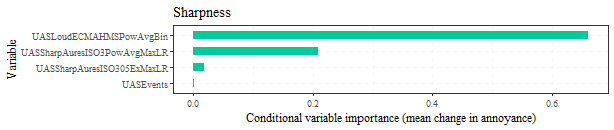

```r
par(mai=c(0,3,0,0))

# plot conditional importance
resultsOutSharpB.conimp <- data.frame('Var_imp'=rev(resultsOutSharpB$conditional_permimp))

pBar <- ggplot(resultsOutSharpB.conimp) + geom_col(aes(x=factor(rownames(resultsOutSharpB.conimp), levels=rownames(resultsOutSharpB.conimp)), y=Var_imp), fill=mycolours[2], width=0.5) + labs(x="Variable", y="Conditional variable importance (mean change in annoyance)") + ggtitle("Sharpness") + theme(text = element_text(family = "serif"), panel.grid=element_line(color = rgb(235, 235, 235, 100, maxColorValue = 255), linewidth = 0.25, linetype = 2))
pBar + coord_flip()
```

```r
if (saveplots){
  ggsave(filename="PtBdAnnoyMnSharpConPermimp.svg", width=8, height=1.7, path=file.path(outFigPath, "svg"))
  unlink("PtBdAnnoyMnSharpConPermimp.svg")

  ggsave(filename="PtBdAnnoyMnSharpConPermimp.pdf", width=8, height=1.7, path=file.path(outFigPath, "pdf"))
  unlink("PtBdAnnoyMnSharpConPermimp.pdf")
}
```

Tonality including tonal loudness

```r
# Tonality inc tonal loudness
iVars <- c("UASLoudECMAHMSPowAvgBin", "UASEvents", "UASTonalECMAHMSAvgMaxLR", "UASTonalECMAHMS05ExMaxLR", "UASTonalIntAvgMaxLR", "UASTonalInt05ExMaxLR", "UASTonLdECMAHMSPowAvgBin", "UASTonLdECMAHMS05ExBin", "UASTonalAuAvgMaxLR", "UASTonalAu05ExMaxLR", "UASTonalAu10ExMaxLR")
resultsOutTonal1B <- multi_crfReg(dataIn=stimDataBNum, iVars=iVars, dVar='dAnnoyMean', seeds=c(778915, 690158, 510928, 785, 5018), ntree=1000, mtry=as.integer(length(iVars)/1.25), minsplit=10, minbucket=5, nperm=5)

# print model prediction results
resultsOutTonal1B$OOB_RMSE
```

```
[1] 1.059986
```

```r
resultsOutTonal1B$OOB_abserror
```

```
       0%       25%       50%       75%      100%
0.1042343 0.1972117 0.3615749 0.6299242 3.8908272
```

```r
resultsOutTonal1B$Rsquared
```

```
[1] 0.394953
```

```r
# store results
resdAnnoyMnFitB['Abs inc tonal loud', 'RMSE'] <- resultsOutTonal1B$OOB_RMSE
resdAnnoyMnFitB['Abs inc tonal loud', 'Rsquared'] <- resultsOutTonal1B$Rsquared
resdAnnoyMnFitB['Abs inc tonal loud', which(colnames(resdAnnoyMnFitB) == 'AEq0'):
                                       which(colnames(resdAnnoyMnFitB) == 'AEq100')] <- resultsOutTonal1B$OOB_abserror
resdAnnoyMnPermImpB$AbsTonal1 <- resultsOutTonal1B$conditional_permimp
```

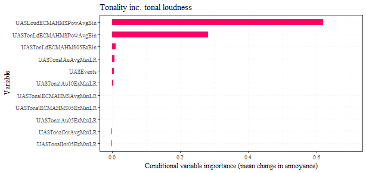

```r
par(mai=c(0,3,0,0))

# plot conditional importance
resultsOutTonal1B.conimp <- data.frame('Var_imp'=rev(resultsOutTonal1B$conditional_permimp))

pBar <- ggplot(resultsOutTonal1B.conimp) + geom_col(aes(x=factor(rownames(resultsOutTonal1B.conimp), levels=rownames(resultsOutTonal1B.conimp)), y=Var_imp), fill=mycolours[3], width=0.5) + labs(x="Variable", y="Conditional variable importance (mean change in annoyance)") + ggtitle("Tonality inc. tonal loudness") + theme(text = element_text(family = "serif"), panel.grid=element_line(color = rgb(235, 235, 235, 100, maxColorValue = 255), linewidth = 0.25, linetype = 2))
pBar + coord_flip(ylim=c(-0.0005, 0.7))
```

```r
if (saveplots){
  ggsave(filename="PtBdAnnoyMnTonalLdConPermimp.svg", width=8, height=3.8, path=file.path(outFigPath, "svg"))
  unlink("PtBdAnnoyMnTonalLdConPermimp.svg")

  ggsave(filename="PtBdAnnoyMnTonalLdConPermimp.pdf", width=8, height=3.8, path=file.path(outFigPath, "pdf"))
  unlink("PtBdAnnoyMnTonalLdConPermimp.pdf")
}
```

Re-run tonality evaluation omitting tonal loudness

```r
# Tonality
iVars <- c("UASLoudECMAHMSPowAvgBin", "UASEvents", "UASTonalECMAHMSAvgMaxLR", "UASTonalECMAHMS05ExMaxLR", "UASTonalIntAvgMaxLR", "UASTonalInt05ExMaxLR", "UASTonalAuAvgMaxLR", "UASTonalAu05ExMaxLR", "UASTonalAu10ExMaxLR")
resultsOutTonal2B <- multi_crfReg(dataIn=stimDataBNum, iVars=iVars, dVar='dAnnoyMean', seeds=c(156089, 270584, 104937, 39098, 5107), ntree=1000, mtry=as.integer(length(iVars)/1.25), minsplit=10, minbucket=5, nperm=5)

# print model prediction results
resultsOutTonal2B$OOB_RMSE
```

```
[1] 1.106307
```

```r
resultsOutTonal2B$OOB_abserror
```

```
        0%        25%        50%        75%       100%
0.06208395 0.33680771 0.49358570 0.66965487 3.94254978
```

```r
resultsOutTonal2B$Rsquared
```

```
[1] 0.3335208
```

```r
# store results
resdAnnoyMnFitB['Abs no tonal loud', 'RMSE'] <- resultsOutTonal2B$OOB_RMSE
resdAnnoyMnFitB['Abs no tonal loud', 'Rsquared'] <- resultsOutTonal2B$Rsquared
resdAnnoyMnFitB['Abs no tonal loud', which(colnames(resdAnnoyMnFitB) == 'AEq0'):
                                     which(colnames(resdAnnoyMnFitB) == 'AEq100')] <- resultsOutTonal2B$OOB_abserror
resdAnnoyMnPermImpB$AbsTonal2 <- resultsOutTonal2B$conditional_permimp
```

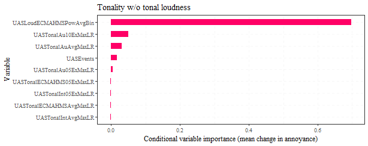

```r
par(mai=c(0,3,0,0))

# plot conditional importance
resultsOutTonal2B.conimp <- data.frame('Var_imp'=rev(resultsOutTonal2B$conditional_permimp))

pBar <- ggplot(resultsOutTonal2B.conimp) + geom_col(aes(x=factor(rownames(resultsOutTonal2B.conimp), levels=rownames(resultsOutTonal2B.conimp)), y=Var_imp), fill=mycolours[3], width=0.5) + labs(x="Variable", y="Conditional variable importance (mean change in annoyance)") + ggtitle("Tonality w/o tonal loudness") + theme(text = element_text(family = "serif"), panel.grid=element_line(color = rgb(235, 235, 235, 100, maxColorValue = 255), linewidth = 0.25, linetype = 2))
pBar + coord_flip(ylim=c(-0.005, 0.7))
```

```r
if (saveplots){
  ggsave(filename="PtBdAnnoyMnTonalNoLdConPermimp.svg", width=8, height=3.2, path=file.path(outFigPath, "svg"))
  unlink("PtBdAnnoyMnTonalNoLdConPermimp.svg")

  ggsave(filename="PtBdAnnoyMnTonalNoLdConPermimp.pdf", width=8, height=3.2, path=file.path(outFigPath, "pdf"))
  unlink("PtBdAnnoyMnTonalNoLdConPermimp.pdf")
}
```

```r
# Fluctuation strength
iVars <- c("UASLoudECMAHMSPowAvgBin", "UASEvents", "UASFluctHMS10ExBin", "UASFluctHMS05ExBin", "UASFluctFZ10ExMaxLR", "UASFluctFZ05ExMaxLR", "UASFluctOV10ExMaxLR", "UASFluctOV05ExMaxLR")
resultsOutFluctB <- multi_crfReg(dataIn=stimDataBNum, iVars=iVars, dVar='dAnnoyMean', seeds=c(170598, 820649, 904185, 503156, 96), ntree=1000, mtry=as.integer(length(iVars)/1.25), minsplit=10, minbucket=5, nperm=5)

# print model prediction results
resultsOutFluctB$OOB_RMSE
```

```
[1] 1.105659
```

```r
resultsOutFluctB$OOB_abserror
```

```
       0%       25%       50%       75%      100%
0.1148154 0.3103974 0.4718523 0.8074976 3.8985929
```

```r
resultsOutFluctB$Rsquared
```

```
[1] 0.3170341
```

```r
# store results
resdAnnoyMnFitB['Abs fluct', 'RMSE'] <- resultsOutFluctB$OOB_RMSE
resdAnnoyMnFitB['Abs fluct', 'Rsquared'] <- resultsOutFluctB$Rsquared
resdAnnoyMnFitB['Abs fluct', which(colnames(resdAnnoyMnFitB) == 'AEq0'):
                             which(colnames(resdAnnoyMnFitB) == 'AEq100')] <- resultsOutFluctB$OOB_abserror
resdAnnoyMnPermImpB$AbsFluct <- resultsOutFluctB$conditional_permimp
```

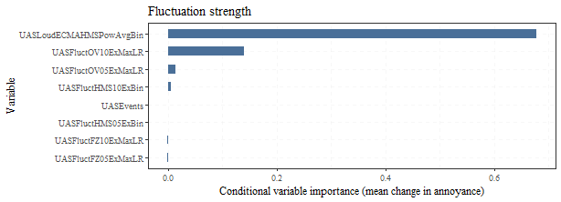

```r
par(mai=c(0,3,0,0))

# plot conditional importance
resultsOutFluctB.conimp <- data.frame('Var_imp'=rev(resultsOutFluctB$conditional_permimp))

pBar <- ggplot(resultsOutFluctB.conimp) + geom_col(aes(x=factor(rownames(resultsOutFluctB.conimp), levels=rownames(resultsOutFluctB.conimp)), y=Var_imp), fill=mycolours[4], width=0.5) + labs(x="Variable", y="Conditional variable importance (mean change in annoyance)") + ggtitle("Fluctuation strength") + theme(text = element_text(family = "serif"), panel.grid=element_line(color = rgb(235, 235, 235, 100, maxColorValue = 255), linewidth = 0.25, linetype = 2))
pBar + coord_flip()
```

```r
if (saveplots){
  ggsave(filename="PtBdAnnoyMnFluctConPermimp.svg", width=8, height=2.9, path=file.path(outFigPath,  "svg"))
  unlink("PtBdAnnoyMnFluctConPermimp.svg")

  ggsave(filename="PtBdAnnoyMnFluctConPermimp.pdf", width=8, height=2.9, path=file.path(outFigPath,  "pdf"))
  unlink("PtBdAnnoyMnFluctConPermimp.pdf")
}
```

```r
# Roughness
iVars <- c("UASLoudECMAHMSPowAvgBin", "UASEvents", "UASRoughECMAHMS10ExBin", "UASRoughECMAHMS05ExBin", "UASRoughFZ10ExMaxLR", "UASRoughFZ05ExMaxLR", "UASRoughDW10ExMaxLR", "UASRoughDW05ExMaxLR")
resultsOutRoughB <- multi_crfReg(dataIn=stimDataBNum, iVars=iVars, dVar='dAnnoyMean', seeds=c(827, 340895, 421, 179803, 42789), ntree=1000, mtry=as.integer(length(iVars)/1.25), minsplit=10, minbucket=5, nperm=5)

# print model prediction results
resultsOutRoughB$OOB_RMSE
```

```
[1] 1.069207
```

```r
resultsOutRoughB$OOB_abserror
```

```
        0%        25%        50%        75%       100%
0.07280951 0.22907540 0.46681668 0.60239101 3.89399654
```

```r
resultsOutRoughB$Rsquared
```

```
[1] 0.3792989
```

```r
# store results
resdAnnoyMnFitB['Abs rough', 'RMSE'] <- resultsOutRoughB$OOB_RMSE
resdAnnoyMnFitB['Abs rough', 'Rsquared'] <- resultsOutRoughB$Rsquared
resdAnnoyMnFitB['Abs rough', which(colnames(resdAnnoyMnFitB) == 'AEq0'):
                             which(colnames(resdAnnoyMnFitB) == 'AEq100')] <- resultsOutRoughB$OOB_abserror
resdAnnoyMnPermImpB$AbsRough <- resultsOutRoughB$conditional_permimp
```

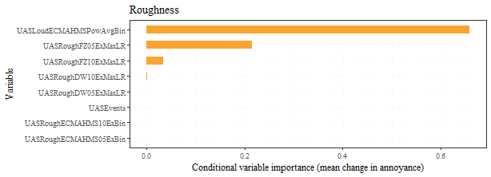

```r
par(mai=c(0,3,0,0))

# plot conditional importance
resultsOutRoughB.conimp <- data.frame('Var_imp'=rev(resultsOutRoughB$conditional_permimp))

pBar <- ggplot(resultsOutRoughB.conimp) + geom_col(aes(x=factor(rownames(resultsOutRoughB.conimp), levels=rownames(resultsOutRoughB.conimp)), y=Var_imp), fill=mycolours[5], width=0.5) + labs(x="Variable", y="Conditional variable importance (mean change in annoyance)") + ggtitle("Roughness") + theme(text = element_text(family = "serif"), panel.grid=element_line(color = rgb(235, 235, 235, 100, maxColorValue = 255), linewidth = 0.25, linetype = 2))
pBar + coord_flip()
```

```r
if (saveplots){
  ggsave(filename="PtBdAnnoyMnRoughConPermimp.svg", width=8, height=2.9, path=file.path(outFigPath, "svg"))
  unlink("PtBdAnnoyMnRoughConPermimp.svg")

  ggsave(filename="PtBdAnnoyMnRoughConPermimp.pdf", width=8, height=2.9, path=file.path(outFigPath, "pdf"))
  unlink("PtBdAnnoyMnRoughConPermimp.pdf")
}
```

```r
# Impulsiveness
iVars <- c("UASLoudECMAHMSPowAvgBin", "UASEvents", "UASImpulsHMSAvgMaxLR", "UASImpulsHMS05ExMaxLR", "UASImpulsHMSPowAvgMaxLR")
resultsOutImpulsB <- multi_crfReg(dataIn=stimDataBNum, iVars=iVars, dVar='dAnnoyMean', seeds=c(170958, 93795, 390748, 95867, 903584), ntree=1000, mtry=as.integer(length(iVars)/1.25), minsplit=10, minbucket=5, nperm=5)

# print model prediction results
resultsOutImpulsB$OOB_RMSE
```

```
[1] 1.112102
```

```r
resultsOutImpulsB$OOB_abserror
```

```
       0%       25%       50%       75%      100%
0.1381189 0.3135302 0.4447430 0.7129678 3.9179237
```

```r
resultsOutImpulsB$Rsquared
```

```
[1] 0.3072887
```

```r
# store results
resdAnnoyMnFitB['Abs impuls', 'RMSE'] <- resultsOutImpulsB$OOB_RMSE
resdAnnoyMnFitB['Abs impuls', 'Rsquared'] <- resultsOutImpulsB$Rsquared
resdAnnoyMnFitB['Abs impuls', which(colnames(resdAnnoyMnFitB) == 'AEq0'):
                             which(colnames(resdAnnoyMnFitB) == 'AEq100')] <- resultsOutImpulsB$OOB_abserror
resdAnnoyMnPermImpB$AbsImpuls <- resultsOutImpulsB$conditional_permimp
```

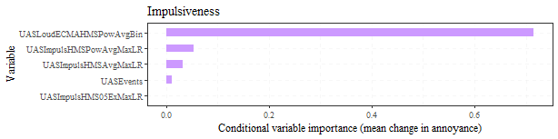

```r
par(mai=c(0,3,0,0))

# plot conditional importance
resultsOutImpulsB.conimp <- data.frame('Var_imp'=rev(resultsOutImpulsB$conditional_permimp))

pBar <- ggplot(resultsOutImpulsB.conimp) + geom_col(aes(x=factor(rownames(resultsOutImpulsB.conimp), levels=rownames(resultsOutImpulsB.conimp)), y=Var_imp), fill=mycolours[6], width=0.5) + labs(x="Variable", y="Conditional variable importance (mean change in annoyance)") + ggtitle("Impulsiveness") + theme(text = element_text(family = "serif"), panel.grid=element_line(color = rgb(235, 235, 235, 100, maxColorValue = 255), linewidth = 0.25, linetype = 2))
pBar + coord_flip()
```

```r
if (saveplots){
  ggsave(filename="PtBdAnnoyMnImpulsConPermimp.svg", width=8, height=2, path=file.path(outFigPath, "svg"))
  unlink("PtBdAnnoyMnImpulsConPermimp.svg")

  ggsave(filename="PtBdAnnoyMnImpulsConPermimp.pdf", width=8, height=2, path=file.path(outFigPath, "pdf"))
  unlink("PtBdAnnoyMnImpulsConPermimp.pdf")
}
```

#### SQM and loudness comparison

```r
iVars <- c("UASLoudECMAHMSPowAvgBin", "UASEvents", "UASSharpAuresISO3PowAvgMaxLR", "UASTonLdECMAHMSPowAvgBin", "UASFluctOV10ExMaxLR", "UASRoughFZ05ExMaxLR", "UASImpulsHMSPowAvgMaxLR")
resultsOutSQMs1B <- multi_crfReg(dataIn=stimDataBNum, iVars=iVars, dVar='dAnnoyMean', seeds=c(659180, 88426, 26084, 25, 605), ntree=1000, mtry=as.integer(length(iVars)/1.25), minsplit=10, minbucket=5, nperm=5)

# print model prediction results
resultsOutSQMs1B$OOB_RMSE
```

```
[1] 1.04859
```

```r
resultsOutSQMs1B$OOB_abserror
```

```
        0%        25%        50%        75%       100%
0.06298178 0.17064585 0.38978244 0.60049458 3.87803967
```

```r
resultsOutSQMs1B$Rsquared
```

```
[1] 0.4175121
```

```r
# store results
resdAnnoyMnFitB['Abs SQMs inc tonal loud', 'RMSE'] <- resultsOutSQMs1B$OOB_RMSE
resdAnnoyMnFitB['Abs SQMs inc tonal loud', 'Rsquared'] <- resultsOutSQMs1B$Rsquared
resdAnnoyMnFitB['Abs SQMs inc tonal loud', which(colnames(resdAnnoyMnFitB) == 'AEq0'):
                                          which(colnames(resdAnnoyMnFitB) == 'AEq100')] <- resultsOutSQMs1B$OOB_abserror
resdAnnoyMnPermImpB$AbsSQMs1 <- resultsOutSQMs1B$conditional_permimp
```

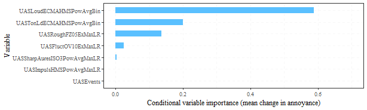

```r
par(mai=c(0,3,0,0))

# plot conditional importance
resultsOutSQMs1B.conimp <- data.frame('Var_imp'=rev(resultsOutSQMs1B$conditional_permimp))

pBar <- ggplot(resultsOutSQMs1B.conimp) + geom_col(aes(x=factor(rownames(resultsOutSQMs1B.conimp), levels=rownames(resultsOutSQMs1B.conimp)), y=Var_imp), fill=mycolours[7], width=0.5) + labs(x="Variable", y="Conditional variable importance (mean change in annoyance)") + theme(text = element_text(family = "serif"), panel.grid=element_line(color = rgb(235, 235, 235, 100, maxColorValue = 255), linewidth = 0.25, linetype = 2))
pBar + coord_flip(ylim=c(0, 0.7))
```

```r
if (saveplots){
  ggsave(filename="PtBdAnnoyMnAbsSQMsTonLdConPermimp.svg", width=8, height=2.4, path=file.path(outFigPath, "svg"))
  unlink("PtBdAnnoyMnAbsSQMsTonLdConPermimp.svg")

  ggsave(filename="PtBdAnnoyMnAbsSQMsTonLdConPermimp.pdf", width=8, height=2.4, path=file.path(outFigPath, "pdf"))
  unlink("PtBdAnnoyMnAbsSQMsTonLdConPermimp.pdf")
}
```

Repeated without tonal loudness

```r
iVars <- c("UASLoudECMAHMSPowAvgBin", "UASEvents", "UASSharpAuresISO3PowAvgMaxLR", "UASTonalAu10ExMaxLR", "UASFluctOV10ExMaxLR", "UASRoughFZ05ExMaxLR", "UASImpulsHMSPowAvgMaxLR")
resultsOutSQMs2B <- multi_crfReg(dataIn=stimDataBNum, iVars=iVars, dVar='dAnnoyMean', seeds=c(4888, 50881, 804, 5470, 257), ntree=1000, mtry=as.integer(length(iVars)/1.25), minsplit=10, minbucket=5, nperm=5)

# print model prediction results
resultsOutSQMs2B$OOB_RMSE
```

```
[1] 1.064043
```

```r
resultsOutSQMs2B$OOB_abserror
```

```
       0%       25%       50%       75%      100%
0.1019737 0.2178949 0.4705848 0.5740304 3.8923614
```

```r
resultsOutSQMs2B$Rsquared
```

```
[1] 0.389351
```

```r
# store results
resdAnnoyMnFitB['Abs SQMs no tonal loud', 'RMSE'] <- resultsOutSQMs2B$OOB_RMSE
resdAnnoyMnFitB['Abs SQMs no tonal loud', 'Rsquared'] <- resultsOutSQMs2B$Rsquared
resdAnnoyMnFitB['Abs SQMs no tonal loud', which(colnames(resdAnnoyMnFitB) == 'AEq0'):
                                          which(colnames(resdAnnoyMnFitB) == 'AEq100')] <- resultsOutSQMs2B$OOB_abserror
resdAnnoyMnPermImpB$AbsSQMs2 <- resultsOutSQMs2B$conditional_permimp
```

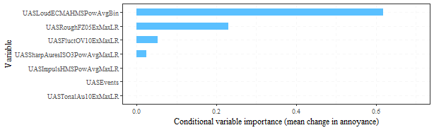

```r
par(mai=c(0,3,0,0))

# plot conditional importance
resultsOutSQMs2B.conimp <- data.frame('Var_imp'=rev(resultsOutSQMs2B$conditional_permimp))

pBar <- ggplot(resultsOutSQMs2B.conimp) + geom_col(aes(x=factor(rownames(resultsOutSQMs2B.conimp), levels=rownames(resultsOutSQMs2B.conimp)), y=Var_imp), fill=mycolours[7], width=0.5) + labs(x="Variable", y="Conditional variable importance (mean change in annoyance)") + theme(text = element_text(family = "serif"), panel.grid=element_line(color = rgb(235, 235, 235, 100, maxColorValue = 255), linewidth = 0.25, linetype = 2))
pBar + coord_flip(ylim=c(0, 0.7))
```

```r
if (saveplots){
  ggsave(filename="PtBdAnnoyMnAbsSQMsNoTonLdConPermimp.svg", width=8, height=2.4, path=file.path(outFigPath, "svg"))
  unlink("PtBdAnnoyMnAbsSQMsNoTonLdConPermimp.svg")

  ggsave(filename="PtBdAnnoyMnAbsSQMsNoTonLdConPermimp.pdf", width=8, height=2.4, path=file.path(outFigPath, "pdf"))
  unlink("PtBdAnnoyMnAbsSQMsNoTonLdConPermimp.pdf")
}
```

### Difference variables

Next, the difference metrics are analysed,

#### Remove ambient only stimuli

Here, the ‘ambient only’ stimuli are removed, as the analysis cannot handle missing values for dB metrics.

```r
stimDataBNum <- stimDataBNum[complete.cases(stimDataBNum),]
stimDataBNum$UASLAeq <- as.numeric(stimDataBNum$UASLAeq)
stimDataBNum$SNRlevel <- as.numeric(stimDataBNum$SNRlevel)
```

```r
iVars <- c(names(stimDataBNum)[which(colnames(stimDataBNum)=="LAeqdiffLAF90"):
                               which(colnames(stimDataBNum)=="dImpulsHMS05ExMaxLR")], "SNRlevel", "UASEvents")
resultsOutDiffsB <- multi_crfReg(dataIn=stimDataBNum, iVars=iVars, dVar='dAnnoyMean', seeds=c(170958, 65, 308845, 1450, 88832095), ntree=1000, mtry=as.integer(length(iVars)/1.25), minsplit=10, minbucket=5, nperm=5)

# print model prediction results
resultsOutDiffsB$OOB_RMSE
```

```
[1] 0.4538102
```

```r
resultsOutDiffsB$OOB_abserror
```

```
         0%         25%         50%         75%        100%
0.004035545 0.087980799 0.245421185 0.555137075 0.994153960
```

```r
resultsOutDiffsB$Rsquared
```

```
[1] 0.7449552
```

```r
# store results
resdAnnoyMnFitB['Diff vars', 'RMSE'] <- resultsOutDiffsB$OOB_RMSE
resdAnnoyMnFitB['Diff vars', 'Rsquared'] <- resultsOutDiffsB$Rsquared
resdAnnoyMnFitB['Diff vars', which(colnames(resdAnnoyMnFitB) == 'AEq0'):
                            which(colnames(resdAnnoyMnFitB) == 'AEq100')] <- resultsOutDiffsB$OOB_abserror
resdAnnoyMnPermImpB$DiffVars <- resultsOutDiffsB$conditional_permimp
```

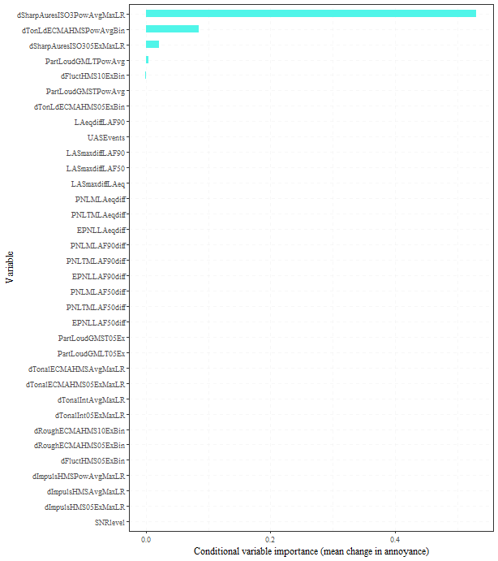

```r
par(mai=c(0,3,0,0))

# plot conditional importance
resultsOutDiffsB.conimp <- data.frame('Var_imp'=rev(resultsOutDiffsB$conditional_permimp))

pBar <- ggplot(resultsOutDiffsB.conimp) + geom_col(aes(x=factor(rownames(resultsOutDiffsB.conimp), levels=rownames(resultsOutDiffsB.conimp)), y=Var_imp), fill=mycolours[8], width=0.5) + labs(x="Variable", y="Conditional variable importance (mean change in annoyance)") + theme(text = element_text(family = "serif"), panel.grid=element_line(color = rgb(235, 235, 235, 100, maxColorValue = 255), linewidth = 0.25, linetype = 2))
pBar + coord_flip()
```

```r
if (saveplots){
  ggsave(filename="PtBdAnnoyMnDiffVarsConPermimp.svg", width=8, height=9, path=file.path(outFigPath, "svg"))
  unlink("PtBdAnnoyMnDiffVarsConPermimp.svg")

  ggsave(filename="PtBdAnnoyMnDiffVarsConPermimp.pdf", width=8, height=9, path=file.path(outFigPath, "pdf"))
  unlink("PtBdAnnoyMnDiffVarsConPermimp.pdf")
}
```

Save the results outputs to file

```r
if (savedata){
  utils::write.csv(resdAnnoyMnFitB, paste(outDataPath, "\\ptBCRFdAnnoyOOBFit.csv", sep=""))
  ii <- 0
  temp = list()
  for (res in resdAnnoyMnPermImpB){
    ii <- ii + 1
    temp[[ii]] <- as.data.frame(resdAnnoyMnPermImpB[ii])
    names(temp[[ii]]) <- names(resdAnnoyMnPermImpB[ii])
  }
  openxlsx::write.xlsx(temp, paste(outDataPath, "\\ptBCRFdAnnoyConPermimp.xlsx",
                                   sep=""),
                       rowNames=TRUE)
}
```

## High annoyance

### Absolute variables

The random forest modelling is run on the aggregated data, including all the variables.

#### Remove ambient only stimuli

Here, the ‘ambient only’ stimuli are removed, as the analysis cannot handle missing values for dB metrics.

```r
stimDataBNum <- stimDataBNum[complete.cases(stimDataBNum),]

stimDataBNum$UASLAeq <- as.numeric(stimDataBNum$UASLAeq)
stimDataBNum$SNRlevel <- as.numeric(stimDataBNum$SNRlevel)
```

```r
resHiAnnoyFitB <- data.frame(RMSE = numeric(),
                                Rsquared = numeric(),
                                AEq0 = numeric(),
                                AEq25 = numeric(),
                                AEq50 = numeric(),
                                AEq75 = numeric(),
                                AEq100 = numeric())
resHiAnnoyPermImpB <- list()
```

```r
iVars <- names(stimDataBNum)[which(names(stimDataBNum) == 'UASEvents'):which(names(stimDataBNum) == 'UASImpulsHMS05ExMaxLR')]
iVars <- iVars[! iVars %in% 'SNRlevel']
resultsOutAbsB <- multi_crfReg(dataIn=stimDataBNum, iVars=iVars, dVar='HighAnnoyProportion', seeds=c(42757, 31908, 37, 8005, 2), ntree=1000, mtry=as.integer(length(iVars)/1.25), minsplit=10, minbucket=5, nperm=5)

# print model prediction results
resultsOutAbsB$OOB_RMSE
```

```
[1] 0.09162514
```

```r
resultsOutAbsB$OOB_abserror
```

```
        0%        25%        50%        75%       100%
0.01250243 0.02195666 0.05822199 0.10945588 0.17761856
```

```r
resultsOutAbsB$Rsquared
```

```
[1] 0.527806
```

```r
# store results
resHiAnnoyFitB['Abs vars', 'RMSE'] <- resultsOutAbsB$OOB_RMSE
resHiAnnoyFitB['Abs vars', 'Rsquared'] <- resultsOutAbsB$Rsquared
resHiAnnoyFitB['Abs vars', which(colnames(resHiAnnoyFitB) == 'AEq0'):
                              which(colnames(resHiAnnoyFitB) == 'AEq100')] <- resultsOutAbsB$OOB_abserror
resHiAnnoyPermImpB$AbsVars <- resultsOutAbsB$conditional_permimp
```

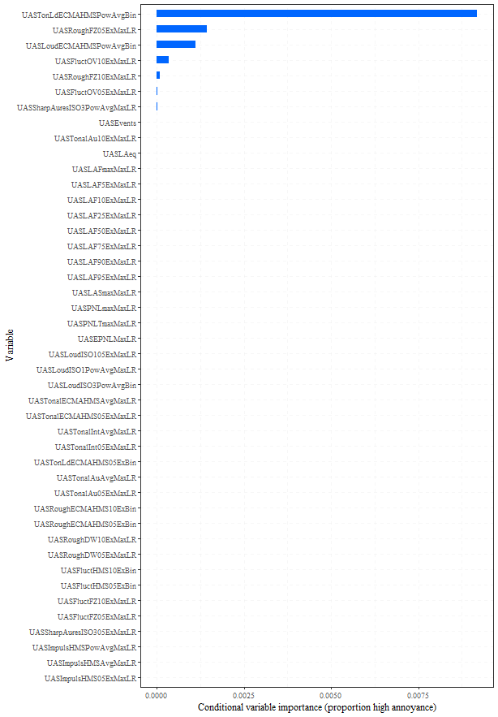

```r
par(mai=c(0,3,0,0))

# plot conditional importance
resultsOutAbsB.conimp <- data.frame('Var_imp'=rev(resultsOutAbsB$conditional_permimp))

pBar <- ggplot(resultsOutAbsB.conimp) + geom_col(aes(x=factor(rownames(resultsOutAbsB.conimp), levels=rownames(resultsOutAbsB.conimp)), y=Var_imp), fill=mycolours[1], width=0.5) + labs(x="Variable", y="Conditional variable importance (proportion high annoyance)") + theme(text = element_text(family = "serif"), panel.grid=element_line(color = rgb(235, 235, 235, 100, maxColorValue = 255), linewidth = 0.25, linetype = 2))
pBar + coord_flip()
```

```r
if (saveplots){
  ggsave(filename="PtBHiAnnoyAbsVarsConPermimp.svg", width=8, height=11.5, path=file.path(outFigPath, "svg"))
  unlink("PtBHiAnnoyAbsVarsConPermimp.svg")

  ggsave(filename="PtBHiAnnoyAbsVarsConPermimp.pdf", width=8, height=11.5, path=file.path(outFigPath, "pdf"))
  unlink("PtBHiAnnoyAbsVarsConPermimp.pdf")
}
```

### SQM analysis

#### Replace ambient only stimuli

Here, the ‘ambient only’ stimuli are replaced, as the SQM analysis can incorporate 0 values (whereas dB metrics cannot be handled in this way).

```r
stimDataBNum <- rbind(stimDataBNum, stimDataB[stimDataB['Recording']
                                              == "B2_CALBIN_Pa.wav",
                                              colnames(stimDataBNum)])
stimDataBNum <- arrange(stimDataBNum, Recording)
```

#### Individual SQMs

Now a model is run omitting loudness and level variables, while retaining only (one of) the top importance loudness variables, and each category of SQM in turn.

```r
# Sharpness
iVars <- c("UASLoudECMAHMSPowAvgBin", "UASEvents", "UASSharpAuresISO3PowAvgMaxLR", "UASSharpAuresISO305ExMaxLR")
resultsOutSharpB <- multi_crfReg(dataIn=stimDataBNum, iVars=iVars, dVar='HighAnnoyProportion', seeds=c(702, 8, 1415, 15771, 147), ntree=1000, mtry=as.integer(length(iVars)/1.25), minsplit=10, minbucket=5, nperm=5)

# print model prediction results
resultsOutSharpB$OOB_RMSE
```

```
[1] 0.09228929
```

```r
resultsOutSharpB$OOB_abserror
```

```
         0%         25%         50%         75%        100%
0.005519119 0.031948300 0.055322854 0.098981056 0.192386843
```

```r
resultsOutSharpB$Rsquared
```

```
[1] 0.6615749
```

```r
# store results
resHiAnnoyFitB['Abs sharp', 'RMSE'] <- resultsOutSharpB$OOB_RMSE
resHiAnnoyFitB['Abs sharp', 'Rsquared'] <- resultsOutSharpB$Rsquared
resHiAnnoyFitB['Abs sharp', which(colnames(resHiAnnoyFitB) == 'AEq0'):
                              which(colnames(resHiAnnoyFitB) == 'AEq100')] <- resultsOutSharpB$OOB_abserror
resHiAnnoyPermImpB$AbsSharp <- resultsOutSharpB$conditional_permimp
```

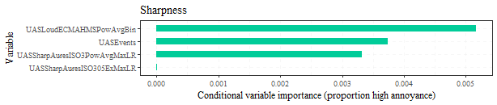

```r
par(mai=c(0,3,0,0))

# plot conditional importance
resultsOutSharpB.conimp <- data.frame('Var_imp'=rev(resultsOutSharpB$conditional_permimp))

pBar <- ggplot(resultsOutSharpB.conimp) + geom_col(aes(x=factor(rownames(resultsOutSharpB.conimp), levels=rownames(resultsOutSharpB.conimp)), y=Var_imp), fill=mycolours[2], width=0.5) + labs(x="Variable", y="Conditional variable importance (proportion high annoyance)") + ggtitle("Sharpness") + theme(text = element_text(family = "serif"), panel.grid=element_line(color = rgb(235, 235, 235, 100, maxColorValue = 255), linewidth = 0.25, linetype = 2))
pBar + coord_flip()
```

```r
if (saveplots){
  ggsave(filename="PtBHiAnnoySharpConPermimp.svg", width=8, height=1.7, path=file.path(outFigPath, "svg"))
  unlink("PtBHiAnnoySharpConPermimp.svg")

  ggsave(filename="PtBHiAnnoySharpConPermimp.pdf", width=8, height=1.7, path=file.path(outFigPath, "pdf"))
  unlink("PtBHiAnnoySharpConPermimp.pdf")
}
```

Tonality including tonal loudness

```r
# Tonality inc tonal loudness
iVars <- c("UASLoudECMAHMSPowAvgBin", "UASEvents", "UASTonalECMAHMSAvgMaxLR", "UASTonalECMAHMS05ExMaxLR", "UASTonalIntAvgMaxLR", "UASTonalInt05ExMaxLR", "UASTonLdECMAHMSPowAvgBin", "UASTonLdECMAHMS05ExBin", "UASTonalAuAvgMaxLR", "UASTonalAu05ExMaxLR", "UASTonalAu10ExMaxLR")
resultsOutTonal1B <- multi_crfReg(dataIn=stimDataBNum, iVars=iVars, dVar='HighAnnoyProportion', seeds=c(50434, 3057, 580, 451, 547), ntree=1000, mtry=as.integer(length(iVars)/1.25), minsplit=10, minbucket=5, nperm=5)

# print model prediction results
resultsOutTonal1B$OOB_RMSE
```

```
[1] 0.09397776
```

```r
resultsOutTonal1B$OOB_abserror
```

```
        0%        25%        50%        75%       100%
0.00092272 0.02555807 0.06172143 0.10829642 0.20788508
```

```r
resultsOutTonal1B$Rsquared
```

```
[1] 0.6375788
```

```r
# store results
resHiAnnoyFitB['Abs inc tonal loud', 'RMSE'] <- resultsOutTonal1B$OOB_RMSE
resHiAnnoyFitB['Abs inc tonal loud', 'Rsquared'] <- resultsOutTonal1B$Rsquared
resHiAnnoyFitB['Abs inc tonal loud', which(colnames(resHiAnnoyFitB) == 'AEq0'):
                                       which(colnames(resHiAnnoyFitB) == 'AEq100')] <- resultsOutTonal1B$OOB_abserror
resHiAnnoyPermImpB$AbsTonal1 <- resultsOutTonal1B$conditional_permimp
```

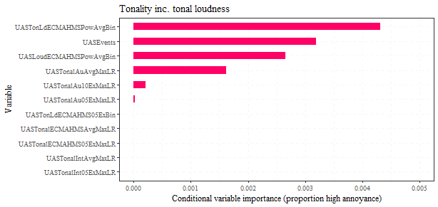

```r
par(mai=c(0,3,0,0))

# plot conditional importance
resultsOutTonal1B.conimp <- data.frame('Var_imp'=rev(resultsOutTonal1B$conditional_permimp))

pBar <- ggplot(resultsOutTonal1B.conimp) + geom_col(aes(x=factor(rownames(resultsOutTonal1B.conimp), levels=rownames(resultsOutTonal1B.conimp)), y=Var_imp), fill=mycolours[3], width=0.5) + labs(x="Variable", y="Conditional variable importance (proportion high annoyance)") + ggtitle("Tonality inc. tonal loudness") + theme(text = element_text(family = "serif"), panel.grid=element_line(color = rgb(235, 235, 235, 100, maxColorValue = 255), linewidth = 0.25, linetype = 2))
pBar + coord_flip(ylim=c(0, 0.005))
```

```r
if (saveplots){
  ggsave(filename="PtBHiAnnoyTonalLdConPermimp.svg", width=8, height=3.8, path=file.path(outFigPath, "svg"))
  unlink("PtBHiAnnoyTonalLdConPermimp.svg")

  ggsave(filename="PtBHiAnnoyTonalLdConPermimp.pdf", width=8, height=3.8, path=file.path(outFigPath, "pdf"))
  unlink("PtBHiAnnoyTonalLdConPermimp.pdf")
}
```

Re-run tonality evaluation omitting tonal loudness

```r
# Tonality
iVars <- c("UASLoudECMAHMSPowAvgBin", "UASEvents", "UASTonalECMAHMSAvgMaxLR", "UASTonalECMAHMS05ExMaxLR", "UASTonalIntAvgMaxLR", "UASTonalInt05ExMaxLR", "UASTonalAuAvgMaxLR", "UASTonalAu05ExMaxLR", "UASTonalAu10ExMaxLR")
resultsOutTonal2B <- multi_crfReg(dataIn=stimDataBNum, iVars=iVars, dVar='HighAnnoyProportion', seeds=c(50434, 3057, 580, 451, 547), ntree=1000, mtry=as.integer(length(iVars)/1.25), minsplit=10, minbucket=5, nperm=5)

# print model prediction results
resultsOutTonal2B$OOB_RMSE
```

```
[1] 0.09990518
```

```r
resultsOutTonal2B$OOB_abserror
```

```
        0%        25%        50%        75%       100%
0.01911327 0.03398883 0.07923358 0.10333368 0.21647892
```

```r
resultsOutTonal2B$Rsquared
```

```
[1] 0.5803
```

```r
# store results
resHiAnnoyFitB['Abs no tonal loud', 'RMSE'] <- resultsOutTonal2B$OOB_RMSE
resHiAnnoyFitB['Abs no tonal loud', 'Rsquared'] <- resultsOutTonal2B$Rsquared
resHiAnnoyFitB['Abs no tonal loud', which(colnames(resHiAnnoyFitB) == 'AEq0'):
                                     which(colnames(resHiAnnoyFitB) == 'AEq100')] <- resultsOutTonal2B$OOB_abserror
resHiAnnoyPermImpB$AbsTonal2 <- resultsOutTonal2B$conditional_permimp
```

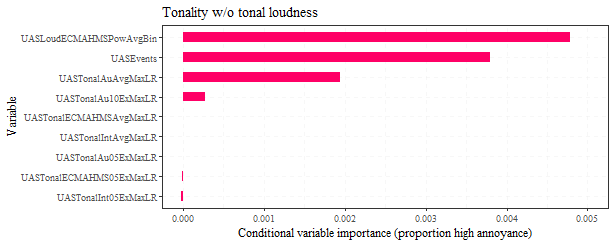

```r
par(mai=c(0,3,0,0))

# plot conditional importance
resultsOutTonal2B.conimp <- data.frame('Var_imp'=rev(resultsOutTonal2B$conditional_permimp))

pBar <- ggplot(resultsOutTonal2B.conimp) + geom_col(aes(x=factor(rownames(resultsOutTonal2B.conimp), levels=rownames(resultsOutTonal2B.conimp)), y=Var_imp), fill=mycolours[3], width=0.5) + labs(x="Variable", y="Conditional variable importance (proportion high annoyance)") + ggtitle("Tonality w/o tonal loudness") + theme(text = element_text(family = "serif"), panel.grid=element_line(color = rgb(235, 235, 235, 100, maxColorValue = 255), linewidth = 0.25, linetype = 2))
pBar + coord_flip(ylim=c(0, 0.005))
```

```r
if (saveplots){
  ggsave(filename="PtBHiAnnoyTonalNoLdConPermimp.svg", width=8, height=3.2, path=file.path(outFigPath, "svg"))
  unlink("PtBHiAnnoyTonalNoLdConPermimp.svg")

  ggsave(filename="PtBHiAnnoyTonalNoLdConPermimp.pdf", width=8, height=3.2, path=file.path(outFigPath, "pdf"))
  unlink("PtBHiAnnoyTonalNoLdConPermimp.pdf")
}
```

```r
# Fluctuation strength
iVars <- c("UASLoudECMAHMSPowAvgBin", "UASEvents", "UASFluctHMS10ExBin", "UASFluctHMS05ExBin", "UASFluctFZ10ExMaxLR", "UASFluctFZ05ExMaxLR", "UASFluctOV10ExMaxLR", "UASFluctOV05ExMaxLR")
resultsOutFluctB <- multi_crfReg(dataIn=stimDataBNum, iVars=iVars, dVar='HighAnnoyProportion', seeds=c(82824, 5220, 4, 165, 95941), ntree=1000, mtry=as.integer(length(iVars)/1.25), minsplit=10, minbucket=5, nperm=5)

# print model prediction results
resultsOutFluctB$OOB_RMSE
```

```
[1] 0.1067701
```

```r
resultsOutFluctB$OOB_abserror
```

```
         0%         25%         50%         75%        100%
0.007210787 0.043601197 0.093648989 0.125674089 0.203754712
```

```r
resultsOutFluctB$Rsquared
```

```
[1] 0.3973897
```

```r
# store results
resHiAnnoyFitB['Abs fluct', 'RMSE'] <- resultsOutFluctB$OOB_RMSE
resHiAnnoyFitB['Abs fluct', 'Rsquared'] <- resultsOutFluctB$Rsquared
resHiAnnoyFitB['Abs fluct', which(colnames(resHiAnnoyFitB) == 'AEq0'):
                             which(colnames(resHiAnnoyFitB) == 'AEq100')] <- resultsOutFluctB$OOB_abserror
resHiAnnoyPermImpB$AbsFluct <- resultsOutFluctB$conditional_permimp
```

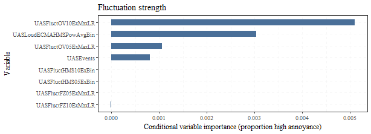

```r
par(mai=c(0,3,0,0))

# plot conditional importance
resultsOutFluctB.conimp <- data.frame('Var_imp'=rev(resultsOutFluctB$conditional_permimp))

pBar <- ggplot(resultsOutFluctB.conimp) + geom_col(aes(x=factor(rownames(resultsOutFluctB.conimp), levels=rownames(resultsOutFluctB.conimp)), y=Var_imp), fill=mycolours[4], width=0.5) + labs(x="Variable", y="Conditional variable importance (proportion high annoyance)") + ggtitle("Fluctuation strength") + theme(text = element_text(family = "serif"), panel.grid=element_line(color = rgb(235, 235, 235, 100, maxColorValue = 255), linewidth = 0.25, linetype = 2))
pBar + coord_flip()
```

```r
if (saveplots){
  ggsave(filename="PtBHiAnnoyFluctConPermimp.svg", width=8, height=2.9, path=file.path(outFigPath, "svg"))
  unlink("PtBHiAnnoyFluctConPermimp.svg")

  ggsave(filename="PtBHiAnnoyFluctConPermimp.pdf", width=8, height=2.9, path=file.path(outFigPath, "pdf"))
  unlink("PtBHiAnnoyFluctConPermimp.pdf")
}
```

```r
# Roughness
iVars <- c("UASLoudECMAHMSPowAvgBin", "UASEvents", "UASRoughECMAHMS10ExBin", "UASRoughECMAHMS05ExBin", "UASRoughFZ10ExMaxLR", "UASRoughFZ05ExMaxLR", "UASRoughDW10ExMaxLR", "UASRoughDW05ExMaxLR")
resultsOutRoughB <- multi_crfReg(dataIn=stimDataBNum, iVars=iVars, dVar='HighAnnoyProportion', seeds=c(954, 250, 56565, 480, 543), ntree=1000, mtry=as.integer(length(iVars)/1.25), minsplit=10, minbucket=5, nperm=5)

# print model prediction results
resultsOutRoughB$OOB_RMSE
```

```
[1] 0.09322522
```

```r
resultsOutRoughB$OOB_abserror
```

```
         0%         25%         50%         75%        100%
0.004058493 0.022237893 0.075869618 0.103642945 0.193328288
```

```r
resultsOutRoughB$Rsquared
```

```
[1] 0.6591262
```

```r
# store results
resHiAnnoyFitB['Abs rough', 'RMSE'] <- resultsOutRoughB$OOB_RMSE
resHiAnnoyFitB['Abs rough', 'Rsquared'] <- resultsOutRoughB$Rsquared
resHiAnnoyFitB['Abs rough', which(colnames(resHiAnnoyFitB) == 'AEq0'):
                             which(colnames(resHiAnnoyFitB) == 'AEq100')] <- resultsOutRoughB$OOB_abserror
resHiAnnoyPermImpB$AbsRough <- resultsOutRoughB$conditional_permimp
```

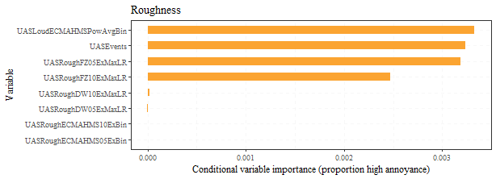

```r
par(mai=c(0,3,0,0))

# plot conditional importance
resultsOutRoughB.conimp <- data.frame('Var_imp'=rev(resultsOutRoughB$conditional_permimp))

pBar <- ggplot(resultsOutRoughB.conimp) + geom_col(aes(x=factor(rownames(resultsOutRoughB.conimp), levels=rownames(resultsOutRoughB.conimp)), y=Var_imp), fill=mycolours[5], width=0.5) + labs(x="Variable", y="Conditional variable importance (proportion high annoyance)") + ggtitle("Roughness") + theme(text = element_text(family = "serif"), panel.grid=element_line(color = rgb(235, 235, 235, 100, maxColorValue = 255), linewidth = 0.25, linetype = 2))
pBar + coord_flip()
```

```r
if (saveplots){
  ggsave(filename="PtBHiAnnoyRoughConPermimp.svg", width=8, height=2.9, path=file.path(outFigPath, "svg"))
  unlink("PtBHiAnnoyRoughConPermimp.svg")

  ggsave(filename="PtBHiAnnoyRoughConPermimp.pdf", width=8, height=2.9, path=file.path(outFigPath, "pdf"))
  unlink("PtBHiAnnoyRoughConPermimp.pdf")
}
```

```r
# Impulsiveness
iVars <- c("UASLoudECMAHMSPowAvgBin", "UASEvents", "UASImpulsHMSAvgMaxLR", "UASImpulsHMS05ExMaxLR", "UASImpulsHMSPowAvgMaxLR")
resultsOutImpulsB <- multi_crfReg(dataIn=stimDataBNum, iVars=iVars, dVar='HighAnnoyProportion', seeds=c(6525, 6541, 4581, 2216, 5656032), ntree=1000, mtry=as.integer(length(iVars)/1.25), minsplit=10, minbucket=5, nperm=5)

# print model prediction results
resultsOutImpulsB$OOB_RMSE
```

```
[1] 0.097103
```

```r
resultsOutImpulsB$OOB_abserror
```

```
         0%         25%         50%         75%        100%
0.004679602 0.031989489 0.084505062 0.101838473 0.203294574
```

```r
resultsOutImpulsB$Rsquared
```

```
[1] 0.5879441
```

```r
# store results
resHiAnnoyFitB['Abs impuls', 'RMSE'] <- resultsOutImpulsB$OOB_RMSE
resHiAnnoyFitB['Abs impuls', 'Rsquared'] <- resultsOutImpulsB$Rsquared
resHiAnnoyFitB['Abs impuls', which(colnames(resHiAnnoyFitB) == 'AEq0'):
                             which(colnames(resHiAnnoyFitB) == 'AEq100')] <- resultsOutImpulsB$OOB_abserror
resHiAnnoyPermImpB$AbsImpuls <- resultsOutImpulsB$conditional_permimp
```

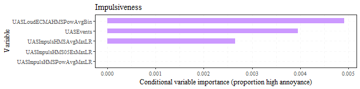

```r
par(mai=c(0,3,0,0))

# plot conditional importance
resultsOutImpulsB.conimp <- data.frame('Var_imp'=rev(resultsOutImpulsB$conditional_permimp))

pBar <- ggplot(resultsOutImpulsB.conimp) + geom_col(aes(x=factor(rownames(resultsOutImpulsB.conimp), levels=rownames(resultsOutImpulsB.conimp)), y=Var_imp), fill=mycolours[6], width=0.5) + labs(x="Variable", y="Conditional variable importance (proportion high annoyance)") + ggtitle("Impulsiveness") + theme(text = element_text(family = "serif"), panel.grid=element_line(color = rgb(235, 235, 235, 100, maxColorValue = 255), linewidth = 0.25, linetype = 2))
pBar + coord_flip()
```

```r
if (saveplots){
  ggsave(filename="PtBHiAnnoyImpulsConPermimp.svg", width=8, height=2, path=file.path(outFigPath, "svg"))
  unlink("PtBHiAnnoyImpulsConPermimp.svg")

  ggsave(filename="PtBHiAnnoyImpulsConPermimp.pdf", width=8, height=2, path=file.path(outFigPath, "pdf"))
  unlink("PtBHiAnnoyImpulsConPermimp.pdf")
}
```

#### SQM and loudness comparison

```r
iVars <- c("UASLoudECMAHMSPowAvgBin", "UASEvents", "UASSharpAuresISO3PowAvgMaxLR", "UASTonLdECMAHMSPowAvgBin", "UASFluctOV10ExMaxLR", "UASRoughFZ05ExMaxLR", "UASImpulsHMSAvgMaxLR")
resultsOutSQMs1B <- multi_crfReg(dataIn=stimDataBNum, iVars=iVars, dVar='HighAnnoyProportion', seeds=c(545, 944, 12120, 46484, 165), ntree=1000, mtry=as.integer(length(iVars)/1.25), minsplit=10, minbucket=5, nperm=5)

# print model prediction results
resultsOutSQMs1B$OOB_RMSE
```

```
[1] 0.09542027
```

```r
resultsOutSQMs1B$OOB_abserror
```

```
        0%        25%        50%        75%       100%
0.00366856 0.03965686 0.07611912 0.10803266 0.19568440
```

```r
resultsOutSQMs1B$Rsquared
```

```
[1] 0.5950454
```

```r
# store results
resHiAnnoyFitB['Abs SQMs inc tonal loud', 'RMSE'] <- resultsOutSQMs1B$OOB_RMSE
resHiAnnoyFitB['Abs SQMs inc tonal loud', 'Rsquared'] <- resultsOutSQMs1B$Rsquared
resHiAnnoyFitB['Abs SQMs inc tonal loud', which(colnames(resHiAnnoyFitB) == 'AEq0'):
                                          which(colnames(resHiAnnoyFitB) == 'AEq100')] <- resultsOutSQMs1B$OOB_abserror
resHiAnnoyPermImpB$AbsSQMs1 <- resultsOutSQMs1B$conditional_permimp
```

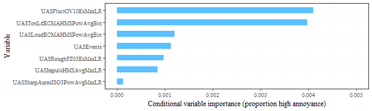

```r
par(mai=c(0,3,0,0))

# plot conditional importance
resultsOutSQMs1B.conimp <- data.frame('Var_imp'=rev(resultsOutSQMs1B$conditional_permimp))

pBar <- ggplot(resultsOutSQMs1B.conimp) + geom_col(aes(x=factor(rownames(resultsOutSQMs1B.conimp), levels=rownames(resultsOutSQMs1B.conimp)), y=Var_imp), fill=mycolours[7], width=0.5) + labs(x="Variable", y="Conditional variable importance (proportion high annoyance)") + theme(text = element_text(family = "serif"), panel.grid=element_line(color = rgb(235, 235, 235, 100, maxColorValue = 255), linewidth = 0.25, linetype = 2))
pBar + coord_flip(ylim=c(0, 0.005))
```

```r
if (saveplots){
  ggsave(filename="PtBHiAnnoyAbsSQMsTonLdConPermimp.svg", width=8, height=2.4, path=file.path(outFigPath, "svg"))
  unlink("PtBHiAnnoyAbsSQMsTonLdConPermimp.svg")

  ggsave(filename="PtBHiAnnoyAbsSQMsTonLdConPermimp.pdf", width=8, height=2.4, path=file.path(outFigPath, "pdf"))
  unlink("PtBHiAnnoyAbsSQMsTonLdConPermimp.pdf")
}
```

Repeated without tonal loudness

```r
iVars <- c("UASLoudECMAHMSPowAvgBin", "UASEvents", "UASSharpAuresISO3PowAvgMaxLR", "UASTonalAuAvgMaxLR", "UASFluctOV10ExMaxLR", "UASRoughFZ05ExMaxLR", "UASImpulsHMSAvgMaxLR")
resultsOutSQMs2B <- multi_crfReg(dataIn=stimDataBNum, iVars=iVars, dVar='HighAnnoyProportion', seeds=c(545, 944, 12120, 46484, 165), ntree=1000, mtry=as.integer(length(iVars)/1.25), minsplit=10, minbucket=5, nperm=5)

# print model prediction results
resultsOutSQMs2B$OOB_RMSE
```

```
[1] 0.0981821
```

```r
resultsOutSQMs2B$OOB_abserror
```

```
         0%         25%         50%         75%        100%
0.009847157 0.041126793 0.084219486 0.100740528 0.199542752
```

```r
resultsOutSQMs2B$Rsquared
```

```
[1] 0.5866695
```

```r
# store results
resHiAnnoyFitB['Abs SQMs no tonal loud', 'RMSE'] <- resultsOutSQMs2B$OOB_RMSE
resHiAnnoyFitB['Abs SQMs no tonal loud', 'Rsquared'] <- resultsOutSQMs2B$Rsquared
resHiAnnoyFitB['Abs SQMs no tonal loud', which(colnames(resHiAnnoyFitB) == 'AEq0'):
                                          which(colnames(resHiAnnoyFitB) == 'AEq100')] <- resultsOutSQMs2B$OOB_abserror
resHiAnnoyPermImpB$AbsSQMs2 <- resultsOutSQMs2B$conditional_permimp
```

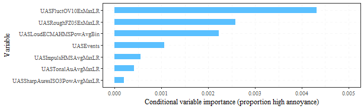

```r
par(mai=c(0,3,0,0))

# plot conditional importance
resultsOutSQMs2B.conimp <- data.frame('Var_imp'=rev(resultsOutSQMs2B$conditional_permimp))

pBar <- ggplot(resultsOutSQMs2B.conimp) + geom_col(aes(x=factor(rownames(resultsOutSQMs2B.conimp), levels=rownames(resultsOutSQMs2B.conimp)), y=Var_imp), fill=mycolours[7], width=0.5) + labs(x="Variable", y="Conditional variable importance (proportion high annoyance)") + theme(text = element_text(family = "serif"), panel.grid=element_line(color = rgb(235, 235, 235, 100, maxColorValue = 255), linewidth = 0.25, linetype = 2))
pBar + coord_flip(ylim=c(0, 0.005))
```

```r
if (saveplots){
  ggsave(filename="PtBHiAnnoyAbsSQMsNoTonLdConPermimp.svg", width=8, height=2.4, path=file.path(outFigPath, "svg"))
  unlink("PtBHiAnnoyAbsSQMsNoTonLdConPermimp.svg")

  ggsave(filename="PtBHiAnnoyAbsSQMsNoTonLdConPermimp.pdf", width=8, height=2.4, path=file.path(outFigPath, "pdf"))
  unlink("PtBHiAnnoyAbsSQMsNoTonLdConPermimp.pdf")
}
```

### Difference variables

Next, the difference metrics are analysed,

#### Remove ambient only stimuli

Here, the ‘ambient only’ stimuli are removed, as the analysis cannot handle missing values for dB metrics.

```r
stimDataBNum <- stimDataBNum[complete.cases(stimDataBNum),]
stimDataBNum$UASLAeq <- as.numeric(stimDataBNum$UASLAeq)
stimDataBNum$SNRlevel <- as.numeric(stimDataBNum$SNRlevel)
```

```r
iVars <- c(names(stimDataBNum)[which(colnames(stimDataBNum)=="LAeqdiffLAF90"):
                               which(colnames(stimDataBNum)=="dImpulsHMS05ExMaxLR")], "SNRlevel", "UASEvents")
resultsOutDiffsB <- multi_crfReg(dataIn=stimDataBNum, iVars=iVars, dVar='HighAnnoyProportion', seeds=c(42870, 1321, 2, 454, 15410), ntree=1000, mtry=as.integer(length(iVars)/1.25), minsplit=10, minbucket=5, nperm=5)

# print model prediction results
resultsOutDiffsB$OOB_RMSE
```

```
[1] 0.08841488
```

```r
resultsOutDiffsB$OOB_abserror
```

```
         0%         25%         50%         75%        100%
0.008394261 0.032861698 0.057246803 0.094644785 0.175740017
```

```r
resultsOutDiffsB$Rsquared
```

```
[1] 0.5558986
```

```r
# store results
resHiAnnoyFitB['Diff vars', 'RMSE'] <- resultsOutDiffsB$OOB_RMSE
resHiAnnoyFitB['Diff vars', 'Rsquared'] <- resultsOutDiffsB$Rsquared
resHiAnnoyFitB['Diff vars', which(colnames(resHiAnnoyFitB) == 'AEq0'):
                            which(colnames(resHiAnnoyFitB) == 'AEq100')] <- resultsOutDiffsB$OOB_abserror
resHiAnnoyPermImpB$DiffVars <- resultsOutDiffsB$conditional_permimp
```

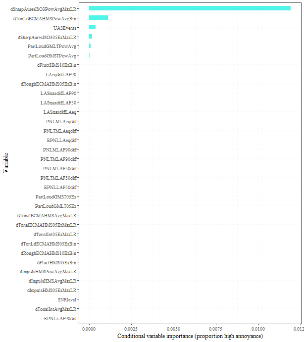

```r
par(mai=c(0,3,0,0))

# plot conditional importance
resultsOutDiffsB.conimp <- data.frame('Var_imp'=rev(resultsOutDiffsB$conditional_permimp))

pBar <- ggplot(resultsOutDiffsB.conimp) + geom_col(aes(x=factor(rownames(resultsOutDiffsB.conimp), levels=rownames(resultsOutDiffsB.conimp)), y=Var_imp), fill=mycolours[8], width=0.5) + labs(x="Variable", y="Conditional variable importance (proportion high annoyance)") + theme(text = element_text(family = "serif"), panel.grid=element_line(color = rgb(235, 235, 235, 100, maxColorValue = 255), linewidth = 0.25, linetype = 2)) + coord_flip()
pBar
```

```r
if (saveplots){
  ggsave(filename="PtBHiAnnoyDiffVarsConPermimp.svg", width=8, height=9, path=file.path(outFigPath, "svg"))
  unlink("PtBHiAnnoyDiffVarsConPermimp.svg")

  ggsave(filename="PtBHiAnnoyDiffVarsConPermimp.pdf", width=8, height=9, path=file.path(outFigPath, "pdf"))
  unlink("PtBHiAnnoyDiffVarsConPermimp.pdf")
}
```

Save the results outputs to file

```r
if (savedata){
  utils::write.csv(resHiAnnoyFitB, paste(outDataPath, "\\ptBCRFHiAnnoyOOBFit.csv", sep=""))
  ii <- 0
  temp = list()
  for (res in resHiAnnoyPermImpB){
    ii <- ii + 1
    temp[[ii]] <- as.data.frame(resHiAnnoyPermImpB[ii])
    names(temp[[ii]]) <- names(resHiAnnoyPermImpB[ii])
  }
  openxlsx::write.xlsx(temp, paste(outDataPath, "\\ptBCRFHiAnnoyConPermimp.xlsx",
                                   sep=""),
                       rowNames=TRUE)
}
```

## Part B summary

Summary of annoyance results for Part B

### With median annoyance

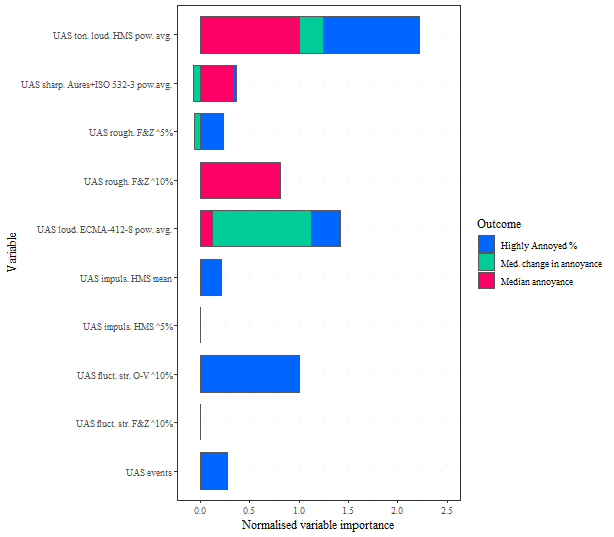

```r
# combine the annoyance perm importance results

res = transform(merge(x=as.data.frame(resAnnoyMedPermImpB$AbsSQMs1/max(resAnnoyMedPermImpB$AbsSQMs1)),
                      y=as.data.frame(resdAnnoyMedPermImpB$AbsSQMs1/max(resdAnnoyMedPermImpB$AbsSQMs1)),
                      by.x='row.names',
                      by.y='row.names',
                      all=TRUE),
                row.names=Row.names,
                Row.names=NULL)

res = transform(merge(x=res,
                      y=as.data.frame(resHiAnnoyPermImpB$AbsSQMs1/max(resHiAnnoyPermImpB$AbsSQMs1)),
                      by.x='row.names',
                      by.y='row.names',
                      all=TRUE),
                row.names=Row.names,
                Row.names=NULL)

rownames(res) <- c("UAS events", "UAS fluct. str. F&Z ^10%", "UAS fluct. str. O-V ^10%", "UAS impuls. HMS ^5%", "UAS impuls. HMS mean", "UAS loud. ECMA-412-8 pow. avg.", "UAS rough. F&Z ^5%", "UAS rough. F&Z ^10%", "UAS sharp. Aures+ISO 532-3 pow.avg.", "UAS ton. loud. HMS pow. avg.")
colnames(res) <- c("Median annoyance", "Med. change in annoyance", "Highly Annoyed %")
res[is.na(res)] <- 0

res <- tibble::rownames_to_column(res, var="Variable")

res <- tidyr::pivot_longer(res, cols=-Variable, names_to="Outcome", values_to="Imp")

res <- res[order(res$Imp),]

pBar <- ggplot(res[order(res$Imp), ]) + geom_col(aes(fill=Outcome, y=Imp, x=Variable), colour='grey35',  width=0.75, show.legend=TRUE) + labs(x="Variable", y="Normalised variable importance") + theme(text = element_text(family = "serif"), panel.grid=element_line(color = rgb(235, 235, 235, 100, maxColorValue = 255), linewidth = 0.25, linetype = 2), legend.position = "right") + coord_flip(ylim=c(-0.1, 2.5)) + scale_fill_manual(values=mycolours)
pBar
```

```r
if (saveplots){
  ggsave(filename="PtBcrfSQMsSummaryMd.svg", width=8, height=7, path=file.path(outFigPath, "svg"))
  unlink("PtBcrfSQMsSummaryMd.svg")

  ggsave(filename="PtBcrfSQMsSummaryMd.pdf", width=8, height=7, path=file.path(outFigPath, "pdf"))
  unlink("PtBcrfSQMsSummaryMd.pdf")
}
```

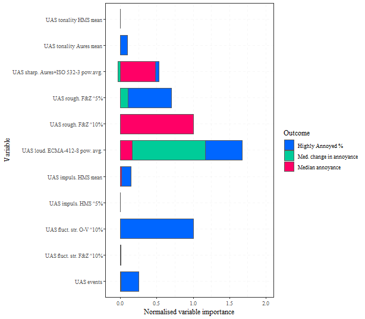

```r
# combine the annoyance perm importance results
res = transform(merge(x=as.data.frame(resAnnoyMedPermImpB$AbsSQMs2/max(resAnnoyMedPermImpB$AbsSQMs2)),
                      y=as.data.frame(resdAnnoyMedPermImpB$AbsSQMs2/max(resdAnnoyMedPermImpB$AbsSQMs2)),
                      by.x='row.names',
                      by.y='row.names',
                      all=TRUE),
                row.names=Row.names,
                Row.names=NULL)

res = transform(merge(x=res,
                      y=as.data.frame(resHiAnnoyPermImpB$AbsSQMs2/max(resHiAnnoyPermImpB$AbsSQMs2)),
                      by.x='row.names',
                      by.y='row.names',
                      all=TRUE),
                row.names=Row.names,
                Row.names=NULL)

rownames(res) <- c("UAS events", "UAS fluct. str. F&Z ^10%", "UAS fluct. str. O-V ^10%", "UAS impuls. HMS ^5%", "UAS impuls. HMS mean", "UAS loud. ECMA-412-8 pow. avg.", "UAS rough. F&Z ^5%", "UAS rough. F&Z ^10%", "UAS sharp. Aures+ISO 532-3 pow.avg.", "UAS tonality Aures mean", "UAS tonality HMS mean")

colnames(res) <- c("Median annoyance", "Med. change in annoyance", "Highly Annoyed %")
res[is.na(res)] <- 0

res <- tibble::rownames_to_column(res, var="Variable")

res <- tidyr::pivot_longer(res, cols=-Variable, names_to="Outcome", values_to="Imp")

res <- res[order(res$Imp),]

pBar <- ggplot(res[order(res$Imp), ]) + geom_col(aes(fill=Outcome, y=Imp, x=Variable), colour='grey35',  width=0.75, show.legend=TRUE) + labs(x="Variable", y="Normalised variable importance") + theme(text = element_text(family = "serif"), panel.grid=element_line(color = rgb(235, 235, 235, 100, maxColorValue = 255), linewidth = 0.25, linetype = 2), legend.position = "right") + coord_flip(ylim=c(-0.1, 2)) + scale_fill_manual(values=mycolours)
pBar
```

```r
if (saveplots){
  ggsave(filename="PtBcrfSQMsNoTonLdSummaryMd.svg", width=8, height=7, path=file.path(outFigPath, "svg"))
  unlink("PtBcrfSQMsNoTonLdSummaryMd.svg")

  ggsave(filename="PtBcrfSQMsNoTonLdSummaryMd.pdf", width=8, height=7, path=file.path(outFigPath, "pdf"))
  unlink("PtBcrfSQMsNoTonLdSummaryMd.pdf")
}
```

### With mean annoyance

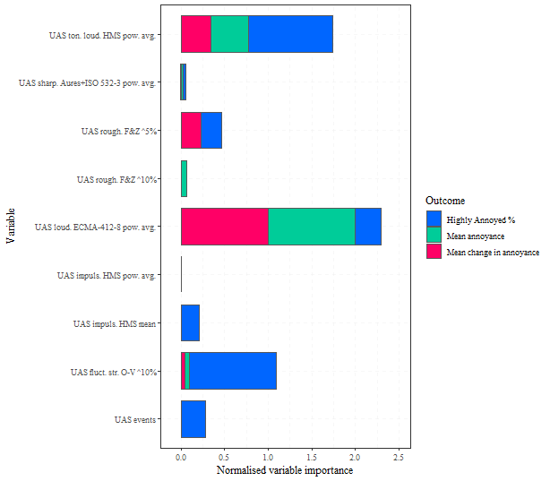

```r
# combine the annoyance perm importance results

res = transform(merge(x=as.data.frame(resAnnoyMnPermImpB$AbsSQMs1/max(resAnnoyMnPermImpB$AbsSQMs1)),
                      y=as.data.frame(resdAnnoyMnPermImpB$AbsSQMs1/max(resdAnnoyMnPermImpB$AbsSQMs1)),
                      by.x='row.names',
                      by.y='row.names',
                      all=TRUE),
                row.names=Row.names,
                Row.names=NULL)

res = transform(merge(x=res,
                      y=as.data.frame(resHiAnnoyPermImpB$AbsSQMs1/max(resHiAnnoyPermImpB$AbsSQMs1)),
                      by.x='row.names',
                      by.y='row.names',
                      all=TRUE),
                row.names=Row.names,
                Row.names=NULL)

rownames(res) <- c("UAS events", "UAS fluct. str. O-V ^10%", "UAS impuls. HMS mean", "UAS impuls. HMS pow. avg.", "UAS loud. ECMA-412-8 pow. avg.", "UAS rough. F&Z ^5%", "UAS rough. F&Z ^10%", "UAS sharp. Aures+ISO 532-3 pow. avg.", "UAS ton. loud. HMS pow. avg.")
colnames(res) <- c("Mean annoyance", "Mean change in annoyance", "Highly Annoyed %")
res[is.na(res)] <- 0

res <- tibble::rownames_to_column(res, var="Variable")

res <- tidyr::pivot_longer(res, cols=-Variable, names_to="Outcome", values_to="Imp")

res <- res[order(res$Imp),]

pBar <- ggplot(res[order(res$Imp), ]) + geom_col(aes(fill=Outcome, y=Imp, x=Variable), colour='grey35',  width=0.75, show.legend=TRUE) + labs(x="Variable", y="Normalised variable importance") + theme(text = element_text(family = "serif"), panel.grid=element_line(color = rgb(235, 235, 235, 100, maxColorValue = 255), linewidth = 0.25, linetype = 2), legend.position = "right") + coord_flip(ylim=c(-0.1, 2.5)) + scale_fill_manual(values=mycolours)
pBar
```

```r
if (saveplots){
  ggsave(filename="PtBcrfSQMsSummaryMn.svg", width=8, height=7, path=file.path(outFigPath, "svg"))
  unlink("PtBcrfSQMsSummaryMn.svg")

  ggsave(filename="PtBcrfSQMsSummaryMn.pdf", width=8, height=7, path=file.path(outFigPath, "pdf"))
  unlink("PtBcrfSQMsSummaryMn.pdf")
}
```

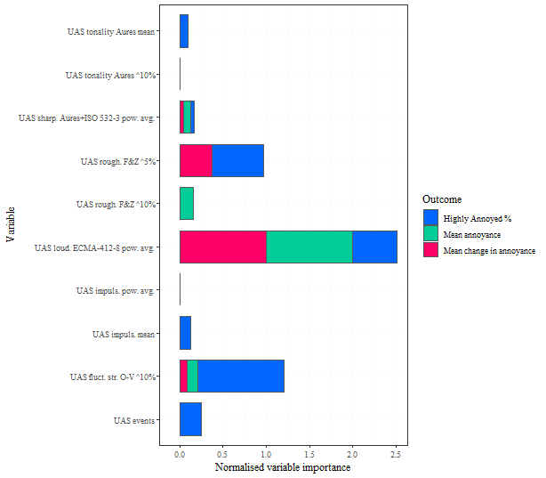

```r
# combine the annoyance perm importance results
res = transform(merge(x=as.data.frame(resAnnoyMnPermImpB$AbsSQMs2/max(resAnnoyMnPermImpB$AbsSQMs2)),
                      y=as.data.frame(resdAnnoyMnPermImpB$AbsSQMs2/max(resdAnnoyMnPermImpB$AbsSQMs2)),
                      by.x='row.names',
                      by.y='row.names',
                      all=TRUE),
                row.names=Row.names,
                Row.names=NULL)

res = transform(merge(x=res,
                      y=as.data.frame(resHiAnnoyPermImpB$AbsSQMs2/max(resHiAnnoyPermImpB$AbsSQMs2)),
                      by.x='row.names',
                      by.y='row.names',
                      all=TRUE),
                row.names=Row.names,
                Row.names=NULL)

rownames(res) <- c("UAS events", "UAS fluct. str. O-V ^10%", "UAS impuls. mean", "UAS impuls. pow. avg.", "UAS loud. ECMA-412-8 pow. avg.", "UAS rough. F&Z ^5%", "UAS rough. F&Z ^10%", "UAS sharp. Aures+ISO 532-3 pow. avg.", "UAS tonality Aures ^10%", "UAS tonality Aures mean")

colnames(res) <- c("Mean annoyance", "Mean change in annoyance", "Highly Annoyed %")
res[is.na(res)] <- 0

res <- tibble::rownames_to_column(res, var="Variable")

res <- tidyr::pivot_longer(res, cols=-Variable, names_to="Outcome", values_to="Imp")

res <- res[order(res$Imp),]

pBar <- ggplot(res[order(res$Imp), ]) + geom_col(aes(fill=Outcome, y=Imp, x=Variable), colour='grey35',  width=0.75, show.legend=TRUE) + labs(x="Variable", y="Normalised variable importance") + theme(text = element_text(family = "serif"), panel.grid=element_line(color = rgb(235, 235, 235, 100, maxColorValue = 255), linewidth = 0.25, linetype = 2), legend.position = "right") + coord_flip(ylim=c(-0.1, 2.5)) + scale_fill_manual(values=mycolours)
pBar
```

```r
if (saveplots){
  ggsave(filename="PtBcrfSQMsNoTonLdSummaryMn.svg", width=8, height=7, path=file.path(outFigPath, "svg"))
  unlink("PtBcrfSQMsNoTonLdSummaryMn.svg")

  ggsave(filename="PtBcrfSQMsNoTonLdSummaryMn.pdf", width=8, height=7, path=file.path(outFigPath, "pdf"))
  unlink("PtBcrfSQMsNoTonLdSummaryMn.pdf")
}
```